# EVALUATION OF ACCESSIBILITY OF MEDICARE INSURANCE SERVICE AND ITS EFFECTIVENESS

A case study of the USA Medicare Program.

By Adebola Olaberinjo & Harold Espinosa

2022-11-20

This file contains the code used for the analysis base on the project proposal. The conclusions and discussions about the result can be found in more detail in the final report.

# Data manipulation

## Packages

For this analysis we are using the following packages.

```r
library("plyr")
library("tidyverse")
library("survey")
library('patchwork')
library('forcats')
library("ggcorrplot")
library("likert")
library("reshape2")
library("ggalluvial")
```

## Data

**Importing data**

```r
Originaldf <- read.csv("puf2019_1_fall.csv")

n_variables = ncol(Originaldf)
n_observations = nrow(Originaldf)
```

**How many observations and variables this data set has?**

```
## [1] "This data set has 333 variables and 14167 observations"
```

We will narrow the number of variables, picking the ones that help us to answer the questions we are interested in.

```r
df <- Originaldf %>%
  select(PUF_ID, DEM_SEX, DEM_RACE, DEM_INCOME, INS_PRIVRX,
         INS_PRIVLTC, INS_PRIVVIS, INS_PRIVDS, INS_D_MADV, INS_D_PRIVNUM,
         INS_D_PRIVNUMC, ACC_MCAVAIL, ACC_MCEASE,ACC_MCCOSTS,ACC_MCSAMLOC,
         MA_MADVDENT, MA_MADVEYE, MA_MADVNH)

n_var_new = ncol(df)
n_obs_new = nrow(df)
```

```
## [1] "The new data set has 18 variables and 14167 observations"
```

**Variables description**

| Variable | Description |
| --- | --- |
| PUF_ID | It is the unique identification number for each Medicare user interviewed |
| DEM_SEX | Gender of the Medicare user |
| DEM_RACE | Race of the Medicare user |
| DEM_INCOME | Income group of the medicare user |
| INS_PRIVRX | Does the private plan cover Rx drugs? |
| INS_PRIVLTC | Does the private plan cover nursing home? |
| INS_PRIVVIS | Does the private plan cover vision? |
| INS_PRIVDS | Does the private plan cover dental? |
| INS_D_MADV | Are you enrolled in Medicare Advantage? |
| INS_D_PRIVNUM | Do you have one or more private plans? |
| INS_D_PRIVNUMC | How many private plans do you have? |
| ACC_MCAVAIL | What is your level of satisfaction with the medical care offered on nights and weekends? |
| ACC_MCEASE | What is your level of satisfaction with how easy is to get a doctor from home? |
| ACC_MCCOSTS | What is your level of satisfaction with the out-of-pocket costs for medical services? |
| ACC_MCSAMLOC | What is your level of satisfaction with the location of your Medicare? |
| MA_MADVDENT | Does your Medicare Advantage plan cover dental? |
| MA_MADVEYE | Does your Medicare Advantage plan cover eyes exams? |
| MA_MADVNH | Does your Medicare Advantage plan covers nursing home? |

Let’s see the first records

```r
head(df)
```

|  | PUF_ID | DEM_SEX | DEM_RACE | DEM_INCOME | INS_PRIVRX | INS_PRIVLTC | INS_PRIVVIS | INS_PRIVDS | INS_D_MADV | INS_D_PRIVNUM | INS_D_PRIVNUMC | ACC_MCAVAIL | ACC_MCEASE | ACC_MCCOSTS | ACC_MCSAMLOC | MA_MADVDENT | MA_MADVEYE | MA_MADVNH |
| --- | --- | --- | --- | --- | --- | --- | --- | --- | --- | --- | --- | --- | --- | --- | --- | --- | --- | --- |
| 1 | 19000000 | 1 | 1 | 2 | 2 | 2 | 2 | 2 | 2 | 2 | 2 | 1 | 1 | 1 | 1 | NA | NA | NA |
| 2 | 19000002 | 2 | 2 | 1 | 2 | 2 | 2 | 2 | 2 | 2 | 2 | 2 | 2 | 2 | 2 | NA | NA | NA |
| 3 | 19000003 | 2 | 3 | 1 | 2 | 2 | 2 | 2 | 2 | 2 | 2 | 5 | 3 | 1 | 1 | NA | NA | NA |
| 4 | 19000006 | 1 | 1 | 1 | 2 | 2 | 2 | 2 | 1 | 2 | 2 | 5 | 2 | 1 | 1 | 1 | 1 | NA |
| 5 | 19000009 | 1 | 1 | 2 | 2 | 2 | 2 | 2 | 2 | 2 | 2 | 5 | 1 | 1 | 2 | NA | NA | NA |
| 6 | 19000014 | 1 | 1 | 2 | 1 | 2 | 2 | 1 | 2 | 1 | 1 | 1 | 1 | 1 | 1 | NA | NA | NA |

Note that the values of each column are represented in numbers. Each number represents a category. We will see the description of each number later in the data exploration. For our analysis, we are not going to change the values, considering that in the way they are, they are ideal for our analysis process.

**Checking missing values**

```r
names(which(colSums(is.na(df))>0))
```

```
## [1] "MA_MADVDENT" "MA_MADVEYE"  "MA_MADVNH"
```

The above columns contain missing values. However, we decided not to manipulate the missing values in any way, considering that those three columns depend on the variable INS_D_MADV. In other words, the missing value here means that that question doesn’t apply to the Medicare User because they don’t have Medicare Advantage Plan. We must consider this situation when analyzing those variables.

# Data Exploration

### Distribution of Demographic variables

**Click here to see code**

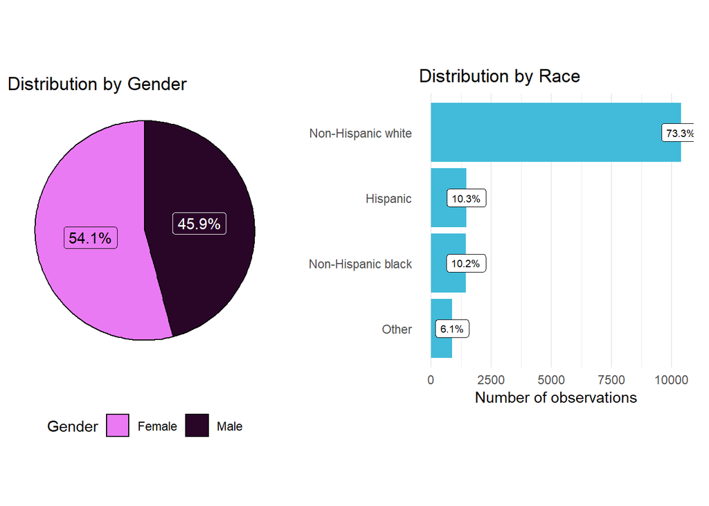

```r
#Distribution by gender
gender <- df %>% group_by(DEM_SEX) %>% count() %>%
  ungroup() %>%
  mutate(perc = n / sum(n)) %>%
  arrange(perc) %>%
  mutate(labels = scales::percent(perc))
names(gender)[1]<-paste("Gender")
gender$Gender[gender$Gender == 1] <- 'Male'
gender$Gender[gender$Gender == 2] <- 'Female'

p1 <- ggplot(gender, aes(x="", y=perc, fill=Gender)) +
  geom_col(color = 'black') +
  geom_label(aes(label = labels), color = c("white","black"),
             position = position_stack(vjust = 0.5),
            show.legend = FALSE) +
  guides(fill = guide_legend(title = "Gender")) +
  coord_polar(theta = "y") +
  theme_void() +
  labs(title = 'Distribution by Gender') +
  theme(legend.position = "bottom") +
  scale_fill_manual(values=c("#EA7AF4", "#290628"))



#Distribution by race
race <- df %>% group_by(DEM_RACE) %>% count() %>%
  ungroup() %>%
  mutate(perc = round(n / sum(n),3) * 100) %>%
  arrange(perc)
names(race)[1]<-paste("Race")
race$Race[race$Race == 1] <- 'Non-Hispanic white'
race$Race[race$Race == 2] <- 'Non-Hispanic black'
race$Race[race$Race == 3] <- 'Hispanic'
race$Race[race$Race == 4] <- 'Other'

p2 <- race %>%
  mutate(Race = fct_reorder(Race, n)) %>%
  ggplot(aes(x=Race, y=n)) +
  geom_bar(stat="identity", fill="#41BBD9") +
  labs(title = 'Distribution by Race',
       x = "", y = 'Number of observations') +
  coord_flip() +
  theme_minimal() +
  theme(panel.grid.major.y = element_blank()) +
  geom_label(aes(label = paste0(perc, "%")), size = 2.5)



#Distribution by Income Group
income_group <- df %>% group_by(DEM_INCOME) %>% count() %>%
  ungroup() %>%
  mutate(perc = n / sum(n)) %>%
  arrange(perc) %>%
  mutate(labels = scales::percent(perc))

names(income_group)[1]<-paste("Income_Group")
income_group$Income_Group[income_group$Income_Group == 1] <- '<$25.000'
income_group$Income_Group[income_group$Income_Group == 2] <- '>=$25.000'

p3 <- ggplot(income_group, aes(x="", y=perc, fill=Income_Group)) +
  geom_col(color = 'black') +
  geom_label(aes(label = labels), color = c("white","black"),
             position = position_stack(vjust = 0.5),
            show.legend = FALSE) +
  guides(fill = guide_legend(title = "Income Group")) +
  coord_polar(theta = "y") +
  theme_void() +
  labs(title = 'Distribution by Income Group') +
  scale_fill_manual(values=c("#F18F01", "#99C24D"))
```

As indicated in the plot above, 54.1% of the entire sample population are female while 45.9% are male.

Also, 73.3% of the sample population are Non-Hispanic White, 10.3% are Hispanic, 10.2% are Non-Hispanic Black while others are 6.1%.

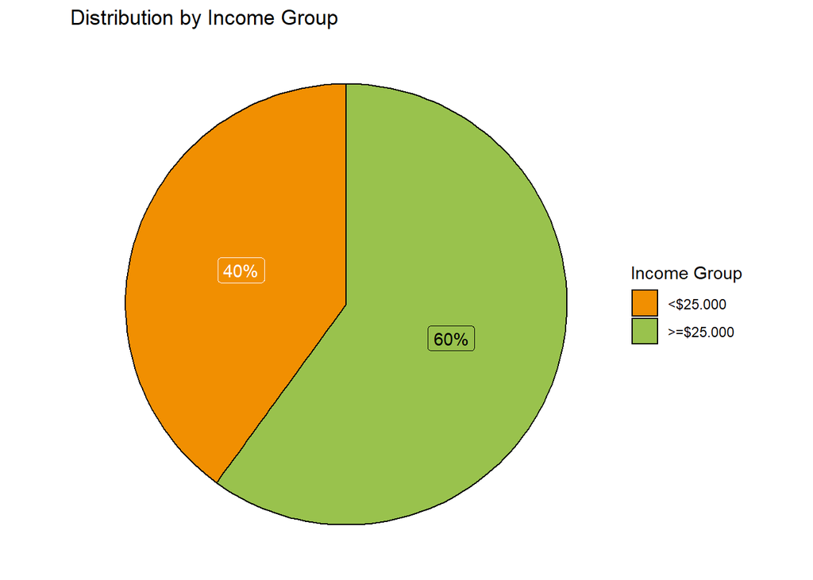

As shown in the chart on the left, 40% of the sample population in this survey earn below 25,000 while 60% earn 25,000 and above.

**Distribution of Insurance coverage**

**Click here to see code**

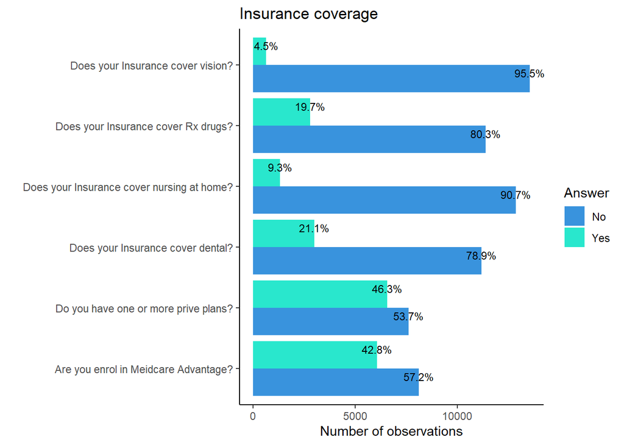

```r
coverage <- df %>% select(INS_PRIVRX, INS_PRIVLTC, INS_PRIVVIS, INS_PRIVDS, INS_D_MADV, INS_D_PRIVNUM)
coverage[coverage == 1] <- 'Yes'
coverage[coverage == 2] <- 'No'

PRIVRX <- coverage %>% select(INS_PRIVRX) %>% group_by(INS_PRIVRX) %>% count()
names(PRIVRX)[2]<-paste("Does your Insurance cover Rx drugs?")
PRIVRX <- t(PRIVRX)
PRIVRX <- janitor::row_to_names(PRIVRX, row_number = 1)

PRIVLTC <- coverage %>% select(INS_PRIVLTC) %>% group_by(INS_PRIVLTC) %>% count()
names(PRIVLTC)[2]<-paste("Does your Insurance cover nursing at home?")
PRIVLTC <- t(PRIVLTC)
PRIVLTC <- janitor::row_to_names(PRIVLTC, row_number = 1)

PRIVVIS <- coverage %>% select(INS_PRIVVIS) %>% group_by(INS_PRIVVIS) %>% count()
names(PRIVVIS)[2]<-paste("Does your Insurance cover vision?")
PRIVVIS <- t(PRIVVIS)
PRIVVIS <- janitor::row_to_names(PRIVVIS, row_number = 1)

PRIVDS <- coverage %>% select(INS_PRIVDS) %>% group_by(INS_PRIVDS) %>% count()
names(PRIVDS)[2]<-paste("Does your Insurance cover dental?")
PRIVDS <- t(PRIVDS)
PRIVDS <- janitor::row_to_names(PRIVDS, row_number = 1)

D_MADV <- coverage %>% select(INS_D_MADV) %>% group_by(INS_D_MADV) %>% count()
names(D_MADV)[2]<-paste("Are you enrol in Meidcare Advantage?")
D_MADV <- t(D_MADV)
D_MADV <- janitor::row_to_names(D_MADV, row_number = 1)

D_PRIVNUM <- coverage %>% select(INS_D_PRIVNUM) %>% group_by(INS_D_PRIVNUM) %>%
  count()
names(D_PRIVNUM)[2]<-paste("Do you have one or more prive plans?")
D_PRIVNUM <- t(D_PRIVNUM)
D_PRIVNUM <- janitor::row_to_names(D_PRIVNUM, row_number = 1)


coverage_clean <- data.frame(rbind(PRIVRX, PRIVLTC,PRIVVIS, PRIVDS, D_MADV, D_PRIVNUM))

coverage_clean$No <- as.numeric(as.character(coverage_clean$No))
coverage_clean$Yes <- as.numeric(as.character(coverage_clean$Yes))

coverage_clean <- cbind(Coverage = rownames(coverage_clean), coverage_clean)
rownames(coverage_clean) <- 1:nrow(coverage_clean)

coverage_clean <- coverage_clean %>%
  pivot_longer(c(No, Yes),
               names_to = 'Answer',
               values_to = 'Count')

p4<- ggplot(coverage_clean, aes(x=Count, y=Coverage, fill=Answer)) +
  geom_bar(stat="identity", position="dodge") +
  labs(title = 'Insurance coverage',
       x = 'Number of observations', y="") +
  scale_fill_manual(values=c("#3993DD", "#29E7CD")) +
  theme_classic() +
  geom_text(aes(label=paste0(round((Count/14167)*100, digits = 1), "%")), position=position_dodge(width=0.9), vjust=-0.2, size = 3)
```

Only 4.5% of the population have their insurance with vision coverage while 95.5% do not have their insurance with vision coverage.

Only 19.7% of the population have Rx drugs included in their insurance while 80.3% do not have Rx drugs included in their insurance.

Only 9.3% of the population have nursing at home service included in their insurance while 90.7% do not have nursing at home service included in their insurance.

21.1% of the population have dental coverage included in their insurance while 78.9% do not have dental coverage included in their insurance.

46.3% of the population have one or more private plans while 53.7% do not.

42.8% of the population are enrolled in Meidcare Advantage while 57.2% are not enrolled in Meidcare Advantage.

#### **Comparing with group income**

**Click here to see code**

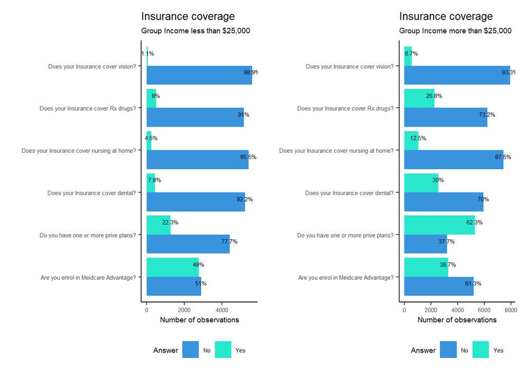

```r
# Plot 5
coverage_less25000 <- df %>% select(DEM_INCOME, INS_PRIVRX, INS_PRIVLTC, INS_PRIVVIS, INS_PRIVDS, INS_D_MADV, INS_D_PRIVNUM) %>% filter(DEM_INCOME == 1)
coverage_less25000 <- coverage_less25000 %>% select(INS_PRIVRX, INS_PRIVLTC, INS_PRIVVIS, INS_PRIVDS, INS_D_MADV, INS_D_PRIVNUM)

coverage_less25000[coverage_less25000 == 1] <- 'Yes'
coverage_less25000[coverage_less25000 == 2] <- 'No'

PRIVRX <- coverage_less25000 %>% select(INS_PRIVRX) %>% group_by(INS_PRIVRX) %>% count()
names(PRIVRX)[2]<-paste("Does your Insurance cover Rx drugs?")
PRIVRX <- t(PRIVRX)
PRIVRX <- janitor::row_to_names(PRIVRX, row_number = 1)

PRIVLTC <- coverage_less25000 %>% select(INS_PRIVLTC) %>% group_by(INS_PRIVLTC) %>% count()
names(PRIVLTC)[2]<-paste("Does your Insurance cover nursing at home?")
PRIVLTC <- t(PRIVLTC)
PRIVLTC <- janitor::row_to_names(PRIVLTC, row_number = 1)

PRIVVIS <- coverage_less25000 %>% select(INS_PRIVVIS) %>% group_by(INS_PRIVVIS) %>% count()
names(PRIVVIS)[2]<-paste("Does your Insurance cover vision?")
PRIVVIS <- t(PRIVVIS)
PRIVVIS <- janitor::row_to_names(PRIVVIS, row_number = 1)

PRIVDS <- coverage_less25000 %>% select(INS_PRIVDS) %>% group_by(INS_PRIVDS) %>% count()
names(PRIVDS)[2]<-paste("Does your Insurance cover dental?")
PRIVDS <- t(PRIVDS)
PRIVDS <- janitor::row_to_names(PRIVDS, row_number = 1)

D_MADV <- coverage_less25000 %>% select(INS_D_MADV) %>% group_by(INS_D_MADV) %>% count()
names(D_MADV)[2]<-paste("Are you enrol in Meidcare Advantage?")
D_MADV <- t(D_MADV)
D_MADV <- janitor::row_to_names(D_MADV, row_number = 1)

D_PRIVNUM <- coverage_less25000 %>% select(INS_D_PRIVNUM) %>% group_by(INS_D_PRIVNUM) %>%
  count()
names(D_PRIVNUM)[2]<-paste("Do you have one or more prive plans?")
D_PRIVNUM <- t(D_PRIVNUM)
D_PRIVNUM <- janitor::row_to_names(D_PRIVNUM, row_number = 1)


coverage_less25000_clean <- data.frame(rbind(PRIVRX, PRIVLTC,PRIVVIS, PRIVDS, D_MADV, D_PRIVNUM))

coverage_less25000_clean$No <- as.numeric(as.character(coverage_less25000_clean$No))
coverage_less25000_clean$Yes <- as.numeric(as.character(coverage_less25000_clean$Yes))

coverage_less25000_clean <- cbind(Coverage = rownames(coverage_less25000_clean), coverage_less25000_clean)
rownames(coverage_less25000_clean) <- 1:nrow(coverage_less25000_clean)

coverage_less25000_clean <- coverage_less25000_clean %>%
  pivot_longer(c(No, Yes),
               names_to = 'Answer',
               values_to = 'Count')

p5<- ggplot(coverage_less25000_clean, aes(x=Count, y=Coverage, fill=Answer)) +
  geom_bar(stat="identity", position="dodge") +
  labs(title = 'Insurance coverage',
       subtitle = 'Group Income less than $25,000',
       x = 'Number of observations', y="") +
  scale_fill_manual(values=c("#3993DD", "#29E7CD")) +
  theme_classic() +
  geom_text(aes(label=paste0(round((Count/5668)*100, digits = 1), "%")), position=position_dodge(width=0.9), vjust=-0.2, size = 2) +
  theme(legend.position="bottom", plot.title = element_text(size=10),
                text = element_text(size=7))

# Plot 6
coverage_more25000 <- df %>% select(DEM_INCOME, INS_PRIVRX, INS_PRIVLTC, INS_PRIVVIS, INS_PRIVDS, INS_D_MADV, INS_D_PRIVNUM) %>% filter(DEM_INCOME == 2)
coverage_more25000 <- coverage_more25000 %>% select(INS_PRIVRX, INS_PRIVLTC, INS_PRIVVIS, INS_PRIVDS, INS_D_MADV, INS_D_PRIVNUM)

coverage_more25000[coverage_more25000 == 1] <- 'Yes'
coverage_more25000[coverage_more25000 == 2] <- 'No'

PRIVRX <- coverage_more25000 %>% select(INS_PRIVRX) %>% group_by(INS_PRIVRX) %>% count()
names(PRIVRX)[2]<-paste("Does your Insurance cover Rx drugs?")
PRIVRX <- t(PRIVRX)
PRIVRX <- janitor::row_to_names(PRIVRX, row_number = 1)

PRIVLTC <- coverage_more25000 %>% select(INS_PRIVLTC) %>% group_by(INS_PRIVLTC) %>% count()
names(PRIVLTC)[2]<-paste("Does your Insurance cover nursing at home?")
PRIVLTC <- t(PRIVLTC)
PRIVLTC <- janitor::row_to_names(PRIVLTC, row_number = 1)

PRIVVIS <- coverage_more25000 %>% select(INS_PRIVVIS) %>% group_by(INS_PRIVVIS) %>% count()
names(PRIVVIS)[2]<-paste("Does your Insurance cover vision?")
PRIVVIS <- t(PRIVVIS)
PRIVVIS <- janitor::row_to_names(PRIVVIS, row_number = 1)

PRIVDS <- coverage_more25000 %>% select(INS_PRIVDS) %>% group_by(INS_PRIVDS) %>% count()
names(PRIVDS)[2]<-paste("Does your Insurance cover dental?")
PRIVDS <- t(PRIVDS)
PRIVDS <- janitor::row_to_names(PRIVDS, row_number = 1)

D_MADV <- coverage_more25000 %>% select(INS_D_MADV) %>% group_by(INS_D_MADV) %>% count()
names(D_MADV)[2]<-paste("Are you enrol in Meidcare Advantage?")
D_MADV <- t(D_MADV)
D_MADV <- janitor::row_to_names(D_MADV, row_number = 1)

D_PRIVNUM <- coverage_more25000 %>% select(INS_D_PRIVNUM) %>% group_by(INS_D_PRIVNUM) %>%
  count()
names(D_PRIVNUM)[2]<-paste("Do you have one or more prive plans?")
D_PRIVNUM <- t(D_PRIVNUM)
D_PRIVNUM <- janitor::row_to_names(D_PRIVNUM, row_number = 1)


coverage_more25000_clean <- data.frame(rbind(PRIVRX, PRIVLTC,PRIVVIS, PRIVDS, D_MADV, D_PRIVNUM))

coverage_more25000_clean$No <- as.numeric(as.character(coverage_more25000_clean$No))
coverage_more25000_clean$Yes <- as.numeric(as.character(coverage_more25000_clean$Yes))

coverage_more25000_clean <- cbind(Coverage = rownames(coverage_more25000_clean), coverage_more25000_clean)
rownames(coverage_more25000_clean) <- 1:nrow(coverage_more25000_clean)

coverage_more25000_clean <- coverage_more25000_clean %>%
  pivot_longer(c(No, Yes),
               names_to = 'Answer',
               values_to = 'Count')

p6<- ggplot(coverage_more25000_clean, aes(x=Count, y=Coverage, fill=Answer)) +
  geom_bar(stat="identity", position="dodge") +
  labs(title = 'Insurance coverage',
       subtitle = 'Group Income more than $25,000',
       x = 'Number of observations', y="") +
  scale_fill_manual(values=c("#3993DD", "#29E7CD")) +
  theme_classic() +
  geom_text(aes(label=paste0(round((Count/8499)*100, digits = 1), "%")), position=position_dodge(width=0.9), vjust=-0.2, size = 2) +
  theme(legend.position="bottom",
        plot.title = element_text(size=10),
        text = element_text(size=7))
```

The above categorized the population into population with income less than 25,000 and population with income more than 25,000;

From the population with less than 25,000 income;

Only 1.1% have their insurance with vision coverage while 98.9% do not have their insurance with vision coverage.

Only 9% have Rx drugs included in their insurance while 91% do not have Rx drugs included in their insurance.

Only 4.5% of the population have nursing at home service included in their insurance while 95.5% do not have nursing at home service included in their insurance.

7.8%% of the population have dental coverage included in their insurance while 92.2% do not have dental coverage included in their insurance.

22.3% of the population have one or more private plans while 77.7% do not.

49% of the population are enrolled in Medicare Advantage while 51% are not enrolled in Medicare Advantage.

From the population with more than 25,000 income;

Only 6.7% have their insurance with vision coverage while 93.3% do not have their insurance with vision coverage.

Only 26.8% have Rx drugs included in their insurance while 73.2% do not have Rx drugs included in their insurance.

Only 12.5% of the population have nursing at home service included in their insurance while 87.5% do not have nursing at home service included in their insurance.

30%% of the population have dental coverage included in their insurance while 70% do not have dental coverage included in their insurance.

62.3% of the population have one or more private plans while 37.7% do not.

38.7% of the population are enrolled in Medicare Advantage while 61.3% are not enrolled in Medicare Advantage.

#### **Correlation between Demographic and Coverage variables**

**Click here to see code**

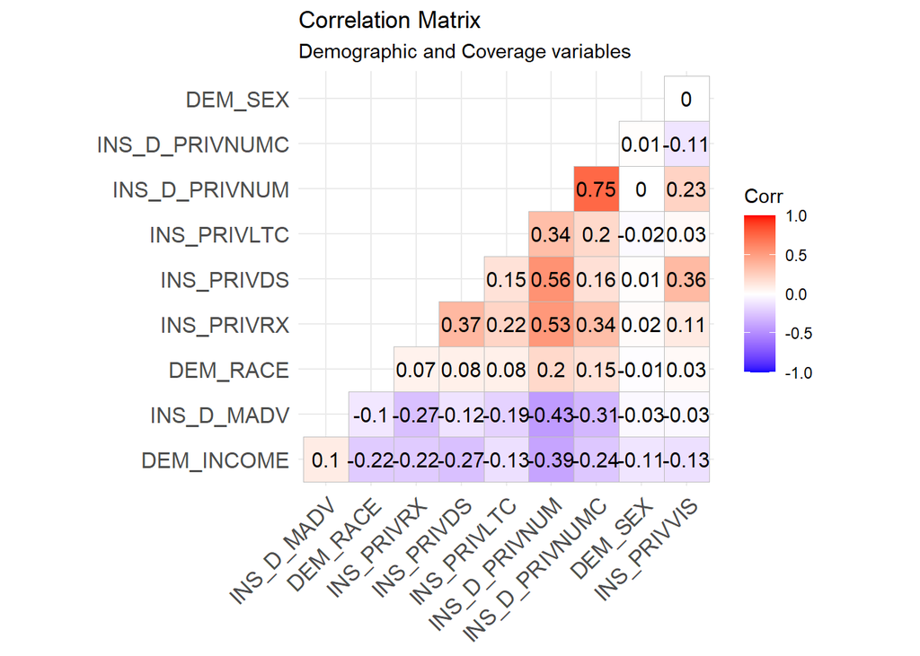

```r
df$ACC_MCAVAIL  <- as.numeric(as.character(df$ACC_MCAVAIL))
df$ACC_MCEASE  <- as.numeric(as.character(df$ACC_MCEASE))
df$ACC_MCCOSTS  <- as.numeric(as.character(df$ACC_MCCOSTS))
df$ACC_MCSAMLOC  <- as.numeric(as.character(df$ACC_MCSAMLOC))

#Correlation matrix of items
cormat <- df %>%
  select(starts_with(c("DEM", "INS"))) %>%
 cor(., use = "pairwise.complete.obs")

# Correlation matrix plot
p7 <- ggcorrplot(cormat, # correlation matrix
           type = "lower", # print the lower part of the correlation matrix
           hc.order = TRUE, # hierarchical clustering of correlations
           lab = TRUE) + # add correlation values as labels
  labs(title = "Correlation Matrix",
       subtitle = "Demographic and Coverage variables")
```

There exists 75% accuracy between INS_D_PRIVNUM and INS_D_PRIVNUMC, this can be considered a bit high. There exists 56% accuracy between INS_PRIVDS and INS_D_PRIVNUM; 53% accuracy between INS_PRIVRX and INS_D_PRIVNUM, both are positive but could be considered not strong enough

### **Distribution of Level of Satisfaction**

**Click here to see code**

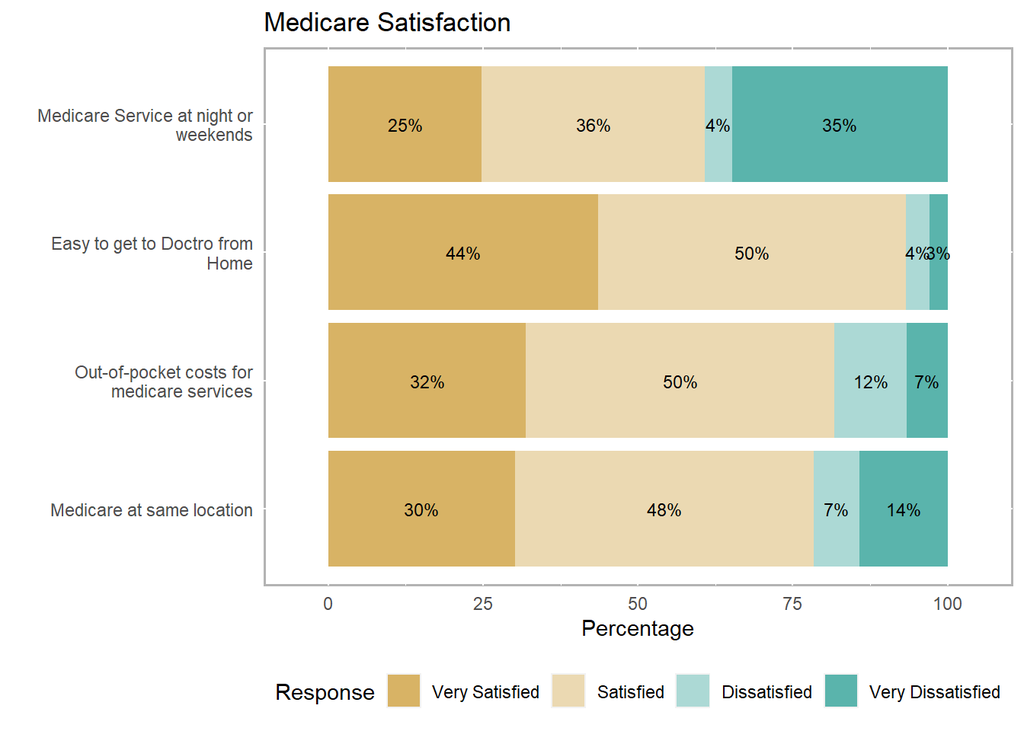

```r
# Select only the satisfaction variables
items <- select(df, starts_with(c("ACC")))

# Rename the items so that the question statement becomes the name
names(items) <- c(
  ACC_MCAVAIL="Medicare Service at night or weekends",
  ACC_MCEASE="Easy to get to Doctro from Home",
  ACC_MCCOSTS="Out-of-pocket costs for medicare services",
  ACC_MCSAMLOC="Medicare at same location")

# A custom function to recode numerical responses into ordered factors
likert_recode <- function(x) {
  y <- ifelse(is.na(x), NA,
              ifelse(x == 1, "Very Satisfied",
                     ifelse(x == 2, "Satisfied",
                            ifelse(x == 3, "Dissatisfied", "Very Dissatisfied"))))

  y <- factor(y, levels = c("Very Satisfied", "Satisfied", "Dissatisfied", "Very Dissatisfied"))

  return(y)
}

# Transform the items into factors and save the data set as a likert object
items_likert <- items %>%
  mutate_all(likert_recode) %>%
  likert()

# Create a stacked bar chart
p8 <- plot(items_likert,
     group.order=names(items),
     plot.percents = TRUE,
     plot.percent.low = FALSE,
     plot.percent.high = FALSE,
     centered = FALSE,
     wrap=30) +
  labs(title = "Medicare Satisfaction")
```

As shown in the plot above, it could be observed that 25% of the population are very satisfied and 36% are satisfied with the Medicare service at night and weekend while 4% are dissatisfied and 35% are very dissatisfied with the Medicare service at night and weekend.

Also, it could be depicted that 44% of the population are very satisfied and 50% are satisfied with being able to get to the doctor from home while 4% are dissatisfied and and 3% are very dissatisfied with being able to get to the doctor from home.

Similarly, it could be deduced that 32% of the population are very satisfied and 50% are satisfied with Out-of-pocket costs for medicare services while 12% are dissatisfied and 7% are very dissatisfied with Out-of-pocket costs for medicare services.

In addition, we can infer that 30% of the population are very satisfied and 48% are satisfied with Medicare at same location while 7% are dissatisfied and 14% are very dissatisfied with Medicare at same location.

#### **Level of satisfaction by Income Group and Race**

**Click here to see code**

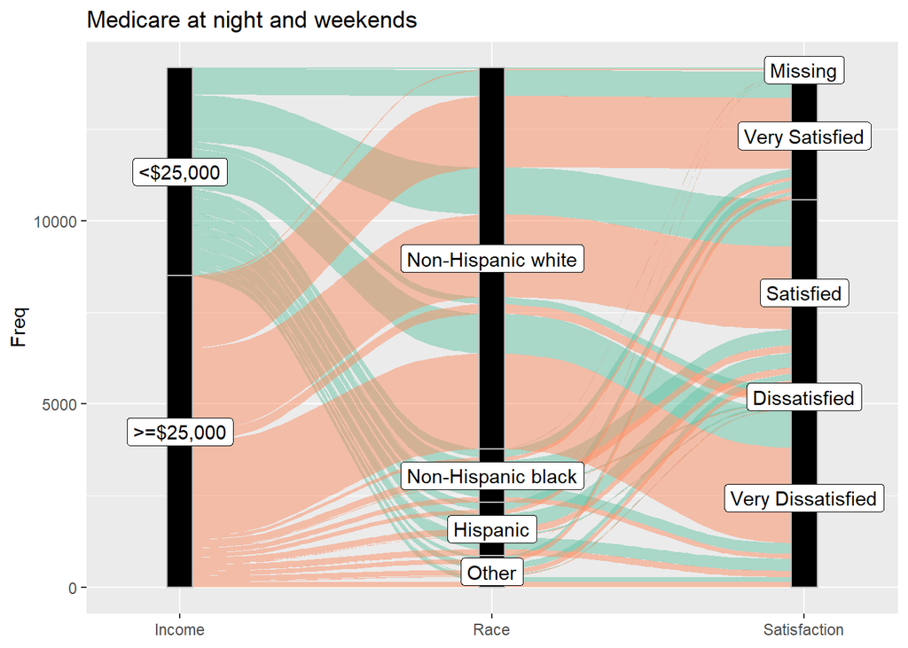

```r
satisfaction <- df %>% select(PUF_ID, DEM_SEX, DEM_RACE, DEM_INCOME, ACC_MCAVAIL, ACC_MCEASE, ACC_MCCOSTS, ACC_MCSAMLOC)

# Transform the data from wide format to long format
data_long <- mutate(satisfaction,
                    # Create categorical inccome Group and Race variables
                    income = ifelse(DEM_INCOME == 1, "<$25,000", ">=$25,000"),
                    race = factor(
                      ifelse(is.na(DEM_RACE), NA,
                                         ifelse(DEM_RACE == 1, "Non-Hispanic white",
                                                ifelse(DEM_RACE == 2, "Non-Hispanic black",
                                                       ifelse(DEM_RACE == 3, "Hispanic",
                                                       "Other")))),
                      levels = c("Non-Hispanic white", "Non-Hispanic black", "Hispanic", "Other")
                    )) %>%

  # Drop old variables
  select(-DEM_INCOME, -DEM_RACE, ) %>%
  # Melt data to long format
  melt(data = .,
       id.vars = c("PUF_ID", "DEM_SEX", "income", "race"),
       variable.name = "question",
       value.name = "response") %>%
  mutate(
    # Recode numerical responses to character strings
    response2 = (ifelse(is.na(response), "Missing",
                        ifelse(response == 1, "Very Satisfied",
                               ifelse(response == 2, "Satisfied",
                                      ifelse(response == 3, "Dissatisfied", "Very Dissatisfied"))))),
    # Reorder factors
    response3 = factor(response2, levels = c("Missing", "Very Satisfied", "Satisfied",
                                             "Dissatisfied", "Very Dissatisfied"))

  )


# Create a frequency table for first items
medicare_night <- data_long %>%
  filter(question == "ACC_MCAVAIL") %>%
  group_by(income, race, response3) %>%
  dplyr::summarize(Freq = n())

# Create an alluvial plot
p9 <- ggplot(medicare_night,
       aes(y = Freq, axis1 = income, axis2 = race, axis3 = response3)) +
  geom_alluvium(aes(fill = income), width = 1/12) +
  geom_stratum(width = 1/12, fill = "black", color = "grey") +
  geom_label(stat = "stratum", aes(label = after_stat(stratum))) +
  scale_x_discrete(limits = c("Income", "Race", "Satisfaction"), expand = c(.1, .1)) +
  scale_fill_brewer(type = "qual", palette = "Set2") +
  ggtitle("Medicare at night and weekends") +
  theme(legend.position="none")


# Create a frequency table for second items
easy_doctor_home <- data_long %>%
  filter(question == "ACC_MCEASE") %>%
  group_by(income, race, response3) %>%
  dplyr::summarize(Freq = n())

# Create an alluvial plot
p10 <- ggplot(easy_doctor_home,
       aes(y = Freq, axis1 = income, axis2 = race, axis3 = response3)) +
  geom_alluvium(aes(fill = income), width = 1/12) +
  geom_stratum(width = 1/12, fill = "black", color = "grey") +
  geom_label(stat = "stratum", aes(label = after_stat(stratum))) +
  scale_x_discrete(limits = c("Income", "Race", "Satisfaction"), expand = c(.1, .1)) +
  scale_fill_brewer(type = "qual", palette = "Set2") +
  ggtitle("Easy to get doctor from home") +
  theme(legend.position="none")


# Create a frequency table for third item
cost_medicare <- data_long %>%
  filter(question == "ACC_MCCOSTS") %>%
  group_by(income, race, response3) %>%
  dplyr::summarize(Freq = n())


# Create an alluvial plot
p11 <- ggplot(cost_medicare,
       aes(y = Freq, axis1 = income, axis2 = race, axis3 = response3)) +
  geom_alluvium(aes(fill = income), width = 1/12) +
  geom_stratum(width = 1/12, fill = "black", color = "grey") +
  geom_label(stat = "stratum", aes(label = after_stat(stratum))) +
  scale_x_discrete(limits = c("Income", "Race", "Satisfaction"), expand = c(.1, .1)) +
  scale_fill_brewer(type = "qual", palette = "Set2") +
  ggtitle("Out-of-Pocket costs for medicare services") +
  theme(legend.position="none")

# Create a frequency table for third item
medicare_location <- data_long %>%
  filter(question == "ACC_MCSAMLOC") %>%
  group_by(income, race, response3) %>%
  dplyr::summarize(Freq = n())

# Create an alluvial plot
p12 <- ggplot(medicare_location,
       aes(y = Freq, axis1 = income, axis2 = race, axis3 = response3)) +
  geom_alluvium(aes(fill = income), width = 1/12) +
  geom_stratum(width = 1/12, fill = "black", color = "grey") +
  geom_label(stat = "stratum", aes(label = after_stat(stratum))) +
  scale_x_discrete(limits = c("Income", "Race", "Satisfaction"), expand = c(.1, .1)) +
  scale_fill_brewer(type = "qual", palette = "Set2") +
  ggtitle("Medicare at the same location") +
  theme(legend.position="none")
```

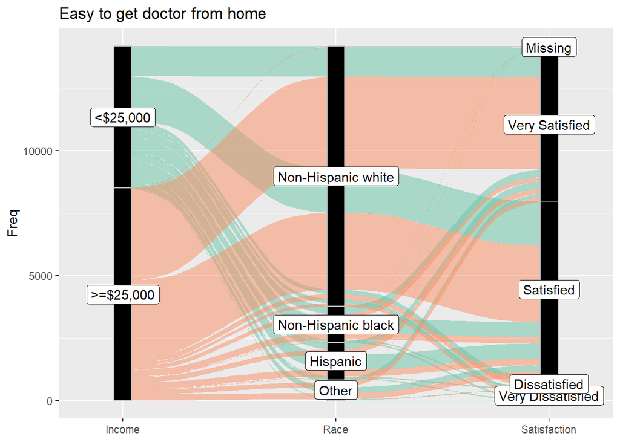

Following the plot, it could be deduced that the people of both income level who are Non-Hispanic White shows a significantly high percentage of either very satisfied or satisfied with the Medicare service of seeing the doctor at home while a very low percentage are either dissatisfied or very dissatisfied. This implies most of the population irrespective of their income level and race are satisfied with the Medicare service of seeing the doctor at home.

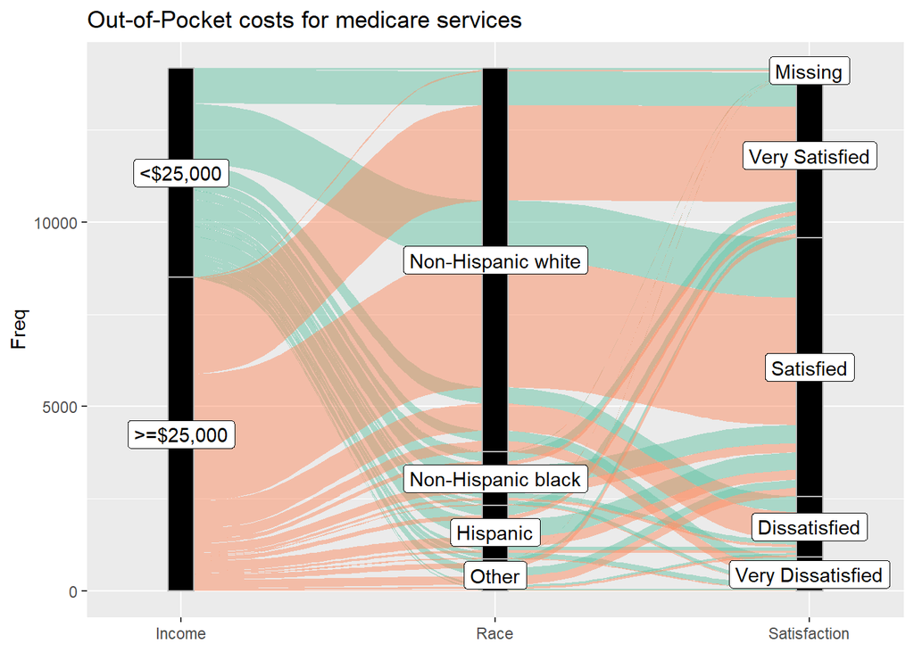

As shown in the chart, it could be deduced that the people of both income level who are Non-Hispanic White shows a significantly high percentage of satisfaction with the Medicare service with Out_of _pocket cost while a very low percentage are dissatisfied. We can infer that most of the population irrespective of their income level and race are satisfied with Out_of_pocket Medicare service. Some missing data are identified, which means they didn’t subscribe to such service at all.

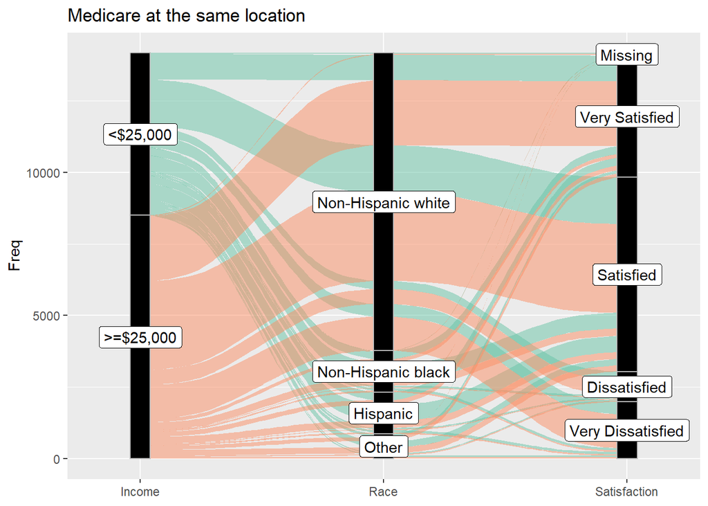

From the chart, it is evident that most Medicare users are satisfied with the Medicare service at same location irrespective of their race or income level. However, a significant percentage of the non-hispanic white with high level of income are very dissatisfied.

### **Access to Medicare Advantage Supplement**

**See code**

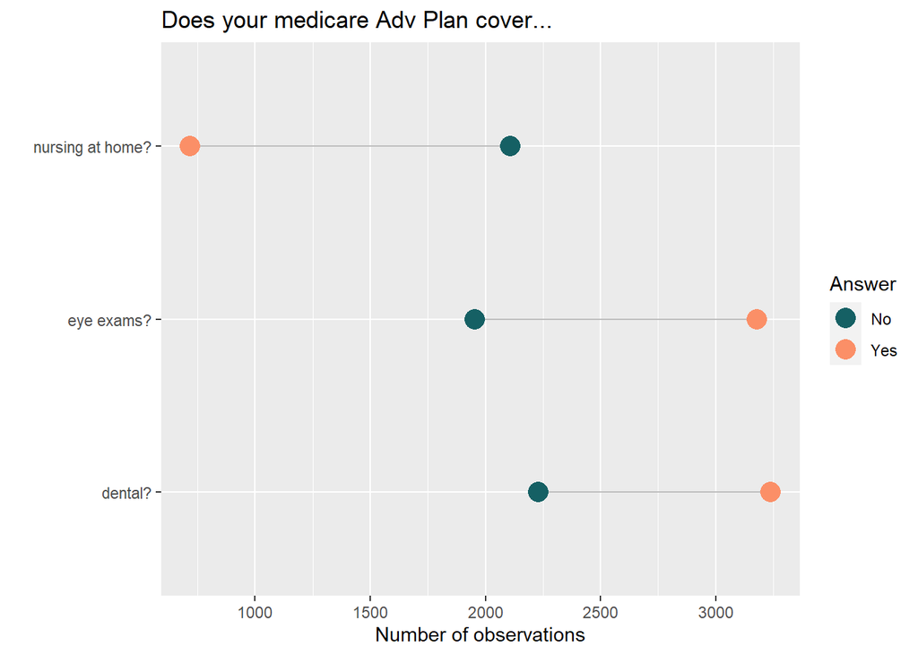

```r
medicare_advantage <- df %>% select(MA_MADVDENT, MA_MADVEYE, MA_MADVNH)
medicare_advantage[medicare_advantage == 1] <- 'Yes'
medicare_advantage[medicare_advantage == 2] <- 'No'

MADVDENT <- medicare_advantage %>% select(MA_MADVDENT) %>% group_by(MA_MADVDENT) %>% count()
names(MADVDENT)[2]<-paste("dental?")
MADVDENT <- t(MADVDENT)
MADVDENT <- janitor::row_to_names(MADVDENT, row_number = 1)

MADVEYE <- medicare_advantage %>% select(MA_MADVEYE) %>% group_by(MA_MADVEYE) %>% count()
names(MADVEYE)[2]<-paste("eye exams?")
MADVEYE <- t(MADVEYE)
MADVEYE <- janitor::row_to_names(MADVEYE, row_number = 1)

MADVNH <- medicare_advantage %>% select(MA_MADVNH) %>% group_by(MA_MADVNH) %>% count()
names(MADVNH)[2]<-paste("nursing at home?")
MADVNH <- t(MADVNH)
MADVNH <- janitor::row_to_names(MADVNH, row_number = 1)

medicare_advantage_clean <- data.frame(rbind(MADVDENT, MADVEYE, MADVNH))

medicare_advantage_clean <- cbind(Medicare_Adv = rownames(medicare_advantage_clean), medicare_advantage_clean)
rownames(medicare_advantage_clean) <- 1:nrow(medicare_advantage_clean)

medicare_advantage_clean$No <- as.numeric(as.character(medicare_advantage_clean$No))
medicare_advantage_clean$Yes <- as.numeric(as.character(medicare_advantage_clean$Yes))

colors <- c("No" = "#156064", "Yes" = "#FB8F67")

p13 <- ggplot(medicare_advantage_clean) +
  geom_segment(aes(x=Medicare_Adv, xend=Medicare_Adv, y=No, yend=Yes), color = 'grey') +
  geom_point(aes(x=Medicare_Adv, y=No, color="No"), size = 5) +
  geom_point(aes(x=Medicare_Adv, y=Yes, color = "Yes"), size = 5) +
  coord_flip() +
  labs(title = "Does your medicare Adv Plan cover...",
       x = "",
       y = "Number of observations",
       color = "Answer") +
  scale_color_manual(values = colors)
```

As shown in the plot above, about 750 of the population have nursing at home service coverage included in their medicare Adv Plan while about 2100 do not have nursing at home service coverage included in their medicare Adv Plan.

Also, about 2000 people do not have eye exams service coverage included in their medicare Adv Plan while about 3200 people have eye exams service coverage included in their medicare Adv Plan.

In addition, about 2250 of the population do not have dental service coverage included in their medicare Adv Plan while about 3250 people have dental service coverage included in their medicare Adv Plan.

**See code**

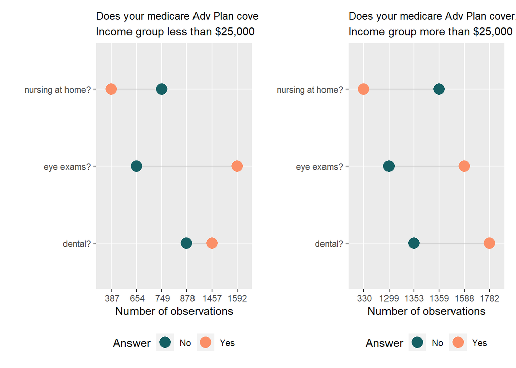

```r
medicare_advantage_less25000 <- df %>% select(DEM_INCOME, MA_MADVDENT, MA_MADVEYE, MA_MADVNH) %>% filter(DEM_INCOME == 1)
medicare_advantage_less25000 <- medicare_advantage_less25000 %>% select(MA_MADVDENT, MA_MADVEYE, MA_MADVNH)

medicare_advantage_less25000[medicare_advantage_less25000 == 1] <- 'Yes'
medicare_advantage_less25000[medicare_advantage_less25000 == 2] <- 'No'

MADVDENT <- medicare_advantage_less25000 %>% select(MA_MADVDENT) %>% group_by(MA_MADVDENT) %>% count()
names(MADVDENT)[2]<-paste("dental?")
MADVDENT <- t(MADVDENT)
MADVDENT <- janitor::row_to_names(MADVDENT, row_number = 1)

MADVEYE <- medicare_advantage_less25000 %>% select(MA_MADVEYE) %>% group_by(MA_MADVEYE) %>% count()
names(MADVEYE)[2]<-paste("eye exams?")
MADVEYE <- t(MADVEYE)
MADVEYE <- janitor::row_to_names(MADVEYE, row_number = 1)

MADVNH <- medicare_advantage_less25000 %>% select(MA_MADVNH) %>% group_by(MA_MADVNH) %>% count()
names(MADVNH)[2]<-paste("nursing at home?")
MADVNH <- t(MADVNH)
MADVNH <- janitor::row_to_names(MADVNH, row_number = 1)

medicare_advantage_less25000_clean <- data.frame(rbind(MADVDENT, MADVEYE, MADVNH))

medicare_advantage_less25000_clean <- cbind(Medicare_Adv = rownames(medicare_advantage_less25000_clean), medicare_advantage_less25000_clean)
rownames(medicare_advantage_less25000_clean) <- 1:nrow(medicare_advantage_less25000_clean)

colors <- c("No" = "#156064", "Yes" = "#FB8F67")

p14 <- ggplot(medicare_advantage_less25000_clean) +
  geom_segment(aes(x=Medicare_Adv, xend=Medicare_Adv, y=No, yend=Yes), color = 'grey') +
  geom_point(aes(x=Medicare_Adv, y=No, color="No"), size = 5) +
  geom_point(aes(x=Medicare_Adv, y=Yes, color = "Yes"), size = 5) +
  coord_flip() +
  labs(title = "Does your medicare Adv Plan cover...",
       subtitle = 'Income group less than $25,000',
       x = "",
       y = "Number of observations",
       color = "Answer") +
  scale_color_manual(values = colors) +
  theme(legend.position = "bottom",
        plot.title = element_text(size=10))

#more than 25,000
medicare_advantage_more25000 <- df %>% select(DEM_INCOME, MA_MADVDENT, MA_MADVEYE, MA_MADVNH) %>% filter(DEM_INCOME == 2)
medicare_advantage_more25000 <- medicare_advantage_more25000 %>% select(MA_MADVDENT, MA_MADVEYE, MA_MADVNH)

medicare_advantage_more25000[medicare_advantage_more25000 == 1] <- 'Yes'
medicare_advantage_more25000[medicare_advantage_more25000 == 2] <- 'No'

MADVDENT <- medicare_advantage_more25000 %>% select(MA_MADVDENT) %>% group_by(MA_MADVDENT) %>% count()
names(MADVDENT)[2]<-paste("dental?")
MADVDENT <- t(MADVDENT)
MADVDENT <- janitor::row_to_names(MADVDENT, row_number = 1)

MADVEYE <- medicare_advantage_more25000 %>% select(MA_MADVEYE) %>% group_by(MA_MADVEYE) %>% count()
names(MADVEYE)[2]<-paste("eye exams?")
MADVEYE <- t(MADVEYE)
MADVEYE <- janitor::row_to_names(MADVEYE, row_number = 1)

MADVNH <- medicare_advantage_more25000 %>% select(MA_MADVNH) %>% group_by(MA_MADVNH) %>% count()
names(MADVNH)[2]<-paste("nursing at home?")
MADVNH <- t(MADVNH)
MADVNH <- janitor::row_to_names(MADVNH, row_number = 1)

medicare_advantage_more25000_clean <- data.frame(rbind(MADVDENT, MADVEYE, MADVNH))

medicare_advantage_more25000_clean <- cbind(Medicare_Adv = rownames(medicare_advantage_more25000_clean), medicare_advantage_more25000_clean)
rownames(medicare_advantage_more25000_clean) <- 1:nrow(medicare_advantage_more25000_clean)

colors <- c("No" = "#156064", "Yes" = "#FB8F67")

p15 <- ggplot(medicare_advantage_more25000_clean) +
  geom_segment(aes(x=Medicare_Adv, xend=Medicare_Adv, y=No, yend=Yes), color = 'grey') +
  geom_point(aes(x=Medicare_Adv, y=No, color="No"), size = 5) +
  geom_point(aes(x=Medicare_Adv, y=Yes, color = "Yes"), size = 5) +
  coord_flip() +
  labs(title = "Does your medicare Adv Plan cover...",
       subtitle = 'Income group more than $25,000',
       x = "",
       y = "Number of observations",
       color = "Answer") +
  scale_color_manual(values = colors) +
  theme(legend.position = "bottom",
        plot.title = element_text(size=10))
```

The above plots have categorized the population into two groups; population with income less than 25,000 and population with income more than 25,000;

From the population with less than 25,000 income;

387 of the population have nursing at home service coverage included in their medicare Adv Plan while 749 do not have nursing at home service coverage included in their medicare Adv Plan.

654 people do not have eye exams service coverage included in their medicare Adv Plan while 1592 people have eye exams service coverage included in their medicare Adv Plan.

878 of the population do not have dental service coverage included in their medicare Adv Plan while 1457 people have dental service coverage included in their medicare Adv Plan.

From the population with more than 25,000 income;

330 of the population have nursing at home service coverage included in their medicare Adv Plan while 1359 do not have nursing at home service coverage included in their medicare Adv Plan.

1299 people do not have eye exams service coverage included in their medicare Adv Plan while 1588 people have eye exams service coverage included in their medicare Adv Plan.

1353 of the population do not have dental service coverage included in their medicare Adv Plan while 1782 people have dental service coverage included in their medicare Adv Plan.

# Data Analysis

## Q1-Are there distinct differences in the insurance coverage plan based on income group and other socio-demographic characteristics?

**Exploring probabilities.**

Tables below summarizes the probabilities of insurance coverage and type. For a better comparison, probability that one out of three patients at random subscribed to each specific insurance coverage in both income groups will be calculated.

**Click here to see the code**

```r
#PROBABILITIES FOR INCOME GROUP LESS THAN 25,000

#Insurance Coverage Plan with Private Plan that covers Rx drugs
INS_PRIVRX_PROB1_LESS25 <- df %>% filter(DEM_INCOME == 1) %>%
  tally(INS_PRIVRX == 1)
INS_PRIVRX_PROB1_LESS25 <- round(INS_PRIVRX_PROB1_LESS25 / tally(df),2)
INS_PRIVRX_PROB1_LESS25 <- round((1-(1-INS_PRIVRX_PROB1_LESS25)^3),2)

#Insurance Coverage Plan with Private Plan that covers Nursing Home
INS_PRIVLTC_PROB1_LESS25 <- df %>% filter(DEM_INCOME == 1) %>%
  tally(INS_PRIVLTC == 1)
INS_PRIVLTC_PROB1_LESS25 <- round(INS_PRIVLTC_PROB1_LESS25 / tally(df),2)
INS_PRIVLTC_PROB1_LESS25 <- round((1-(1-INS_PRIVLTC_PROB1_LESS25)^3),2)

#Insurance Coverage Plan with Private Plan that covers Vision
INS_PRIVVIS_PROB1_LESS25 <- df %>% filter(DEM_INCOME == 1) %>%
  tally(INS_PRIVVIS == 1)
INS_PRIVVIS_PROB1_LESS25 <- round(INS_PRIVVIS_PROB1_LESS25 / tally(df),2)
INS_PRIVVIS_PROB1_LESS25 <- round((1-(1-INS_PRIVVIS_PROB1_LESS25)^3),2)

#Insurance Coverage Plan with Private Plan that covers Dental
INS_PRIVDS_PROB1_LESS25 <- df %>% filter(DEM_INCOME == 1) %>%
  tally(INS_PRIVDS == 1)
INS_PRIVDS_PROB1_LESS25 <- round(INS_PRIVDS_PROB1_LESS25 / tally(df),2)
INS_PRIVDS_PROB1_LESS25 <- round((1-(1-INS_PRIVDS_PROB1_LESS25)^3),2)

#Insurance Coverage Plan with Private Plan that enrolled in Medicare Advantage
INS_D_MADV_PROB1_LESS25 <- df %>% filter(DEM_INCOME == 1) %>%
  tally(INS_D_MADV == 1)
INS_D_MADV_PROB1_LESS25 <- round(INS_D_MADV_PROB1_LESS25 / tally(df),2)
INS_D_MADV_PROB1_LESS25 <- round((1-(1-INS_D_MADV_PROB1_LESS25)^3),2)

#Insurance Coverage Plan with Private Plan with One or More Private Plans
INS_D_PRIVNUM_PROB1_LESS25 <- df %>% filter(DEM_INCOME == 1) %>%
  tally(INS_D_PRIVNUM == 1)
INS_D_PRIVNUM_PROB1_LESS25 <- round(INS_D_PRIVNUM_PROB1_LESS25 / tally(df),2)
INS_D_PRIVNUM_PROB1_LESS25 <- round((1-(1-INS_D_PRIVNUM_PROB1_LESS25)^3),2)

#Joining the outputs in a column

prob1_less25 <- data.frame(rbind(INS_PRIVRX_PROB1_LESS25, INS_PRIVLTC_PROB1_LESS25, INS_PRIVVIS_PROB1_LESS25, INS_PRIVDS_PROB1_LESS25,INS_D_MADV_PROB1_LESS25,INS_D_PRIVNUM_PROB1_LESS25))


#PROBABILITIES FOR INCOME GROUP EQUAL OR MORE THAN 25,000

#Insurance Coverage Plan with Private Plan that covers Rx drugs
INS_PRIVRX_PROB1_MORE25 <- df %>% filter(DEM_INCOME == 2) %>%
  tally(INS_PRIVRX == 1)
INS_PRIVRX_PROB1_MORE25 <- round(INS_PRIVRX_PROB1_MORE25 / tally(df),2)
INS_PRIVRX_PROB1_MORE25 <- round((1-(1-INS_PRIVRX_PROB1_MORE25)^3),2)

#Insurance Coverage Plan with Private Plan that covers Nursing Home
INS_PRIVLTC_PROB1_MORE25 <- df %>% filter(DEM_INCOME == 2) %>%
  tally(INS_PRIVLTC == 1)
INS_PRIVLTC_PROB1_MORE25 <- round(INS_PRIVLTC_PROB1_MORE25 / tally(df),2)
INS_PRIVLTC_PROB1_MORE25 <- round((1-(1-INS_PRIVLTC_PROB1_MORE25)^3),2)

#Insurance Coverage Plan with Private Plan that covers Vision
INS_PRIVVIS_PROB1_MORE25 <- df %>% filter(DEM_INCOME == 2) %>%
  tally(INS_PRIVVIS == 1)
INS_PRIVVIS_PROB1_MORE25 <- round(INS_PRIVVIS_PROB1_MORE25 / tally(df),2)
INS_PRIVVIS_PROB1_MORE25 <- round((1-(1-INS_PRIVVIS_PROB1_MORE25)^3),2)

#Insurance Coverage Plan with Private Plan that covers Dental
INS_PRIVDS_PROB1_MORE25 <- df %>% filter(DEM_INCOME == 2) %>%
  tally(INS_PRIVDS == 1)
INS_PRIVDS_PROB1_MORE25 <- round(INS_PRIVDS_PROB1_MORE25 / tally(df),2)
INS_PRIVDS_PROB1_MORE25 <- round((1-(1-INS_PRIVDS_PROB1_MORE25)^3),2)

#Insurance Coverage Plan with Private Plan that enrolled in Medicare Advantage
INS_D_MADV_PROB1_MORE25 <- df %>% filter(DEM_INCOME == 2) %>%
  tally(INS_D_MADV == 1)
INS_D_MADV_PROB1_MORE25 <- round(INS_D_MADV_PROB1_MORE25 / tally(df),2)
INS_D_MADV_PROB1_MORE25 <- round((1-(1-INS_D_MADV_PROB1_MORE25)^3),2)

#Insurance Coverage Plan with Private Plan with One or More Private Plans
INS_D_PRIVNUM_PROB1_MORE25 <- df %>% filter(DEM_INCOME == 2) %>%
  tally(INS_D_PRIVNUM == 1)
INS_D_PRIVNUM_PROB1_MORE25 <- round(INS_D_PRIVNUM_PROB1_MORE25 / tally(df),2)
INS_D_PRIVNUM_PROB1_MORE25 <- round((1-(1-INS_D_PRIVNUM_PROB1_MORE25)^3),2)

#Joining the outputs in a column

prob1_more25 <- data.frame(rbind(INS_PRIVRX_PROB1_MORE25, INS_PRIVLTC_PROB1_MORE25, INS_PRIVVIS_PROB1_MORE25, INS_PRIVDS_PROB1_MORE25,INS_D_MADV_PROB1_MORE25,INS_D_PRIVNUM_PROB1_MORE25))

##formatting and join the two outputs in a data frame

criterias <- data.frame(rbind('Private Plan covers Rx Drugs', 'Private Plan covers Nursing Home', ' Private Plan covers Vision', 'Private Plan covers Dental', 'Enrolled in Medicare Advantage', 'One or More Private Plans'))
prob1_Q1 <- data.frame(cbind(criterias, prob1_less25, prob1_more25))
names(prob1_Q1)[1]<-paste("Evaluated criterion")
names(prob1_Q1)[2]<-paste("<$25.000")
names(prob1_Q1)[3]<-paste(">=$25.000")
```

| Evaluated criterion | <$25.000 | >=$25.000 |
| --- | --- | --- |
| Private Plan covers Rx Drugs | 0.12 | 0.41 |
| Private Plan covers Nursing Home | 0.06 | 0.20 |
| Private Plan covers Vision | 0.00 | 0.12 |
| Private Plan covers Dental | 0.09 | 0.45 |
| Enrolled in Medicare Advantage | 0.49 | 0.54 |
| One or More Private Plans | 0.25 | 0.75 |

As shown in the table above, it could be deduced that the probability that one out three of patients with income level less than 25,000 who have access to the different insurance coverage plans are less than 0.50 compared with patients with income level of 25,000 and above. This implies that it is not certain than one out of three patients with less than 25,000 income level benefit from any of the insurance coverage plan. This also applies to the patients with higher income level, the probability that one out of the patients enrolled for any of the insurance coverage is low except for the ‘Insurance Coverage with Medicare Advantage enrollment’ and ‘Insurance Coverage with one or more plans’.

Looking at the insurance coverage with vision, it could be deduced that the probability that one out of three patients of less than 25,000 income level is zero. This implies that it’s possible that none of the three patients picked at random have access to the insurance coverage plans. Also, the probability of the patients of higher income level is really low. This also implies that insurance coverage with vision is generally not accessible to the patients irrespective of their income level.

It is of interest to explore the accessibility of theses insurance coverage plans for each income group putting some demographic characteristics into consideration.

The first demographic characteristic to base our analysis on would be gender.

**Click here to see the code**

```r
#PROBABILITIES FOR INCOME GROUP LESS THAN 25,000 - MALE


#Insurance Coverage Plan with Private Plan that covers Rx drugs
INS_PRIVRX_PROB2_LESS25_M <- df %>% filter(DEM_INCOME == 1, DEM_SEX == 1) %>%
  tally(INS_PRIVRX == 1)
INS_PRIVRX_PROB2_LESS25_M_T <- df %>% filter(DEM_INCOME == 1, DEM_SEX == 1) %>%
  tally(DEM_INCOME == 1 | DEM_SEX == 1)
INS_PRIVRX_PROB2_LESS25_M <- round(INS_PRIVRX_PROB2_LESS25_M / INS_PRIVRX_PROB2_LESS25_M_T,2)
INS_PRIVRX_PROB2_LESS25_M <- round((1-(1-INS_PRIVRX_PROB2_LESS25_M)^3),2)

#Insurance Coverage Plan with Private Plan that covers Nursing Home
INS_PRIVLTC_PROB2_LESS25_M <- df %>% filter(DEM_INCOME == 1, DEM_SEX == 1) %>%
  tally(INS_PRIVLTC == 1)
INS_PRIVLTC_PROB2_LESS25_M_T <- df %>% filter(DEM_INCOME == 1, DEM_SEX == 1) %>%
  tally(DEM_INCOME == 1 | DEM_SEX == 1)
INS_PRIVLTC_PROB2_LESS25_M <- round(INS_PRIVLTC_PROB2_LESS25_M / INS_PRIVLTC_PROB2_LESS25_M_T,2)
INS_PRIVLTC_PROB2_LESS25_M <- round((1-(1-INS_PRIVLTC_PROB2_LESS25_M)^3),2)

#Insurance Coverage Plan with Private Plan that covers Vision
INS_PRIVVIS_PROB2_LESS25_M <- df %>% filter(DEM_INCOME == 1, DEM_SEX == 1) %>%
  tally(INS_PRIVVIS == 1)
INS_PRIVVIS_PROB2_LESS25_M_T <- df %>% filter(DEM_INCOME == 1, DEM_SEX == 1) %>%
  tally(DEM_INCOME == 1 | DEM_SEX == 1)
INS_PRIVVIS_PROB2_LESS25_M <- round(INS_PRIVVIS_PROB2_LESS25_M / INS_PRIVVIS_PROB2_LESS25_M_T,2)
INS_PRIVVIS_PROB2_LESS25_M <- round((1-(1-INS_PRIVVIS_PROB2_LESS25_M)^3),2)

#Insurance Coverage Plan with Private Plan that covers Dental
INS_PRIVDS_PROB2_LESS25_M <- df %>% filter(DEM_INCOME == 1, DEM_SEX == 1) %>%
  tally(INS_PRIVDS == 1)
INS_PRIVDS_PROB2_LESS25_M_T <- df %>% filter(DEM_INCOME == 1, DEM_SEX == 1) %>%
  tally(DEM_INCOME == 1 | DEM_SEX == 1)
INS_PRIVDS_PROB2_LESS25_M <- round(INS_PRIVDS_PROB2_LESS25_M / INS_PRIVDS_PROB2_LESS25_M_T,2)
INS_PRIVDS_PROB2_LESS25_M <- round((1-(1-INS_PRIVDS_PROB2_LESS25_M)^3),2)

#Insurance Coverage Plan with Private Plan that enrolled in Medicare Advantage
INS_D_MADV_PROB2_LESS25_M <- df %>% filter(DEM_INCOME == 1, DEM_SEX == 1) %>%
  tally(INS_D_MADV == 1)
INS_D_MADV_PROB2_LESS25_M_T <- df %>% filter(DEM_INCOME == 1, DEM_SEX == 1) %>%
  tally(DEM_INCOME == 1 | DEM_SEX == 1)
INS_D_MADV_PROB2_LESS25_M <- round(INS_D_MADV_PROB2_LESS25_M / INS_D_MADV_PROB2_LESS25_M_T,2)
INS_D_MADV_PROB2_LESS25_M <- round((1-(1-INS_D_MADV_PROB2_LESS25_M)^3),2)

#Insurance Coverage Plan with Private Plan with One or More Private Plans
INS_D_PRIVNUM_PROB2_LESS25_M <- df %>% filter(DEM_INCOME == 1, DEM_SEX == 1) %>%
  tally(INS_D_PRIVNUM == 1)
INS_D_PRIVNUM_PROB2_LESS25_M_T <- df %>% filter(DEM_INCOME == 1, DEM_SEX == 1) %>%
  tally(DEM_INCOME == 1 | DEM_SEX == 1)
INS_D_PRIVNUM_PROB2_LESS25_M <- round(INS_D_PRIVNUM_PROB2_LESS25_M / INS_D_PRIVNUM_PROB2_LESS25_M_T,2)
INS_D_PRIVNUM_PROB2_LESS25_M <- round((1-(1-INS_D_PRIVNUM_PROB2_LESS25_M)^3),2)

#Joining the outputs in a column

prob2_less25_M <- data.frame(rbind(INS_PRIVRX_PROB2_LESS25_M, INS_PRIVLTC_PROB2_LESS25_M, INS_PRIVVIS_PROB2_LESS25_M, INS_PRIVDS_PROB2_LESS25_M,INS_D_MADV_PROB2_LESS25_M,INS_D_PRIVNUM_PROB2_LESS25_M))


#PROBABILITIES FOR INCOME GROUP LESS THAN 25,000 - FEMALE

#Insurance Coverage Plan with Private Plan that covers Rx drugs
INS_PRIVRX_PROB2_LESS25_F <- df %>% filter(DEM_INCOME == 1, DEM_SEX == 2) %>%
  tally(INS_PRIVRX == 1)
INS_PRIVRX_PROB2_LESS25_F_T <- df %>% filter(DEM_INCOME == 1, DEM_SEX == 2) %>%
  tally(DEM_INCOME == 1 | DEM_SEX == 2)
INS_PRIVRX_PROB2_LESS25_F <- round(INS_PRIVRX_PROB2_LESS25_F / INS_PRIVRX_PROB2_LESS25_F_T,2)
INS_PRIVRX_PROB2_LESS25_F <- round((1-(1-INS_PRIVRX_PROB2_LESS25_F)^3),2)

#Insurance Coverage Plan with Private Plan that covers Nursing Home
INS_PRIVLTC_PROB2_LESS25_F <- df %>% filter(DEM_INCOME == 1, DEM_SEX == 2) %>%
  tally(INS_PRIVLTC == 1)
INS_PRIVLTC_PROB2_LESS25_F_T <- df %>% filter(DEM_INCOME == 1, DEM_SEX == 2) %>%
  tally(DEM_INCOME == 1 | DEM_SEX == 2)
INS_PRIVLTC_PROB2_LESS25_F <- round(INS_PRIVLTC_PROB2_LESS25_F / INS_PRIVLTC_PROB2_LESS25_F_T,2)
INS_PRIVLTC_PROB2_LESS25_F <- round((1-(1-INS_PRIVLTC_PROB2_LESS25_F)^3),2)

#Insurance Coverage Plan with Private Plan that covers Vision
INS_PRIVVIS_PROB2_LESS25_F <- df %>% filter(DEM_INCOME == 1, DEM_SEX == 2) %>%
  tally(INS_PRIVVIS == 1)
INS_PRIVVIS_PROB2_LESS25_F_T <- df %>% filter(DEM_INCOME == 1, DEM_SEX == 2) %>%
  tally(DEM_INCOME == 1 | DEM_SEX == 2)
INS_PRIVVIS_PROB2_LESS25_F <- round(INS_PRIVVIS_PROB2_LESS25_F / INS_PRIVVIS_PROB2_LESS25_F_T,2)
INS_PRIVVIS_PROB2_LESS25_F <- round((1-(1-INS_PRIVVIS_PROB2_LESS25_F)^3),2)

#Insurance Coverage Plan with Private Plan that covers Dental
INS_PRIVDS_PROB2_LESS25_F <- df %>% filter(DEM_INCOME == 1, DEM_SEX == 2) %>%
  tally(INS_PRIVDS == 1)
INS_PRIVDS_PROB2_LESS25_F_T <- df %>% filter(DEM_INCOME == 1, DEM_SEX == 2) %>%
  tally(DEM_INCOME == 1 | DEM_SEX == 2)
INS_PRIVDS_PROB2_LESS25_F <- round(INS_PRIVDS_PROB2_LESS25_F / INS_PRIVDS_PROB2_LESS25_F_T,2)
INS_PRIVDS_PROB2_LESS25_F <- round((1-(1-INS_PRIVDS_PROB2_LESS25_F)^3),2)

#Insurance Coverage Plan with Private Plan that enrolled in Medicare Advantage
INS_D_MADV_PROB2_LESS25_F <- df %>% filter(DEM_INCOME == 1, DEM_SEX == 2) %>%
  tally(INS_D_MADV == 1)
INS_D_MADV_PROB2_LESS25_F_T <- df %>% filter(DEM_INCOME == 1, DEM_SEX == 2) %>%
  tally(DEM_INCOME == 1 | DEM_SEX == 2)
INS_D_MADV_PROB2_LESS25_F <- round(INS_D_MADV_PROB2_LESS25_F / INS_D_MADV_PROB2_LESS25_F_T,2)
INS_D_MADV_PROB2_LESS25_F <- round((1-(1-INS_D_MADV_PROB2_LESS25_F)^3),2)

#Insurance Coverage Plan with Private Plan with One or More Private Plans
INS_D_PRIVNUM_PROB2_LESS25_F <- df %>% filter(DEM_INCOME == 1, DEM_SEX == 2) %>%
  tally(INS_D_PRIVNUM == 1)
INS_D_PRIVNUM_PROB2_LESS25_F_T <- df %>% filter(DEM_INCOME == 1, DEM_SEX == 2) %>%
  tally(DEM_INCOME == 1 | DEM_SEX == 2)
INS_D_PRIVNUM_PROB2_LESS25_F <- round(INS_D_PRIVNUM_PROB2_LESS25_F / INS_D_PRIVNUM_PROB2_LESS25_F_T,2)
INS_D_PRIVNUM_PROB2_LESS25_F <- round((1-(1-INS_D_PRIVNUM_PROB2_LESS25_F)^3),2)

#Joining the outputs in a column

prob2_less25_F <- data.frame(rbind(INS_PRIVRX_PROB2_LESS25_F, INS_PRIVLTC_PROB2_LESS25_F, INS_PRIVVIS_PROB2_LESS25_F, INS_PRIVDS_PROB2_LESS25_F,INS_D_MADV_PROB2_LESS25_F,INS_D_PRIVNUM_PROB2_LESS25_F))
```

```r
#PROBABILITIES FOR INCOME GROUP EQUAL OR MORE THAN 25,000 - MALE

#Insurance Coverage Plan with Private Plan that covers Rx drugs
INS_PRIVRX_PROB2_MORE25_M <- df %>% filter(DEM_INCOME == 2, DEM_SEX == 1) %>%
  tally(INS_PRIVRX == 1)
INS_PRIVRX_PROB2_MORE25_M_T <- df %>% filter(DEM_INCOME == 2, DEM_SEX == 1) %>%
  tally(DEM_INCOME == 2 | DEM_SEX == 1)
INS_PRIVRX_PROB2_MORE25_M <- round(INS_PRIVRX_PROB2_MORE25_M / INS_PRIVRX_PROB2_MORE25_M_T,2)
INS_PRIVRX_PROB2_MORE25_M <- round((1-(1-INS_PRIVRX_PROB2_MORE25_M)^3),2)

#Insurance Coverage Plan with Private Plan that covers Nursing Home
INS_PRIVLTC_PROB2_MORE25_M <- df %>% filter(DEM_INCOME == 2, DEM_SEX == 1) %>%
  tally(INS_PRIVLTC == 1)
INS_PRIVLTC_PROB2_MORE25_M_T <- df %>% filter(DEM_INCOME == 2, DEM_SEX == 1) %>%
  tally(DEM_INCOME == 2 | DEM_SEX == 1)
INS_PRIVLTC_PROB2_MORE25_M <- round(INS_PRIVLTC_PROB2_MORE25_M / INS_PRIVLTC_PROB2_MORE25_M_T,2)
INS_PRIVLTC_PROB2_MORE25_M <- round((1-(1-INS_PRIVLTC_PROB2_MORE25_M)^3),2)

#Insurance Coverage Plan with Private Plan that covers Vision
INS_PRIVVIS_PROB2_MORE25_M <- df %>% filter(DEM_INCOME == 2, DEM_SEX == 1) %>%
  tally(INS_PRIVVIS == 1)
INS_PRIVVIS_PROB2_MORE25_M_T <- df %>% filter(DEM_INCOME == 2, DEM_SEX == 1) %>%
  tally(DEM_INCOME == 2 | DEM_SEX == 1)
INS_PRIVVIS_PROB2_MORE25_M <- round(INS_PRIVVIS_PROB2_MORE25_M / INS_PRIVVIS_PROB2_MORE25_M_T,2)
INS_PRIVVIS_PROB2_MORE25_M <- round((1-(1-INS_PRIVVIS_PROB2_MORE25_M)^3),2)

#Insurance Coverage Plan with Private Plan that covers Dental
INS_PRIVDS_PROB2_MORE25_M <- df %>% filter(DEM_INCOME == 2, DEM_SEX == 1) %>%
  tally(INS_PRIVDS == 1)
INS_PRIVDS_PROB2_MORE25_M_T <- df %>% filter(DEM_INCOME == 2, DEM_SEX == 1) %>%
  tally(DEM_INCOME == 2 | DEM_SEX == 1)
INS_PRIVDS_PROB2_MORE25_M <- round(INS_PRIVDS_PROB2_MORE25_M / INS_PRIVDS_PROB2_MORE25_M_T,2)
INS_PRIVDS_PROB2_MORE25_M <- round((1-(1-INS_PRIVDS_PROB2_MORE25_M)^3),2)

#Insurance Coverage Plan with Private Plan that enrolled in Medicare Advantage
INS_D_MADV_PROB2_MORE25_M <- df %>% filter(DEM_INCOME == 2, DEM_SEX == 1) %>%
  tally(INS_D_MADV == 1)
INS_D_MADV_PROB2_MORE25_M_T <- df %>% filter(DEM_INCOME == 2, DEM_SEX == 1) %>%
  tally(DEM_INCOME == 2 | DEM_SEX == 1)
INS_D_MADV_PROB2_MORE25_M <- round(INS_D_MADV_PROB2_MORE25_M / INS_D_MADV_PROB2_MORE25_M_T,2)
INS_D_MADV_PROB2_MORE25_M <- round((1-(1-INS_D_MADV_PROB2_MORE25_M)^3),2)

#Insurance Coverage Plan with Private Plan with One or More Private Plans
INS_D_PRIVNUM_PROB2_MORE25_M <- df %>% filter(DEM_INCOME == 2, DEM_SEX == 1) %>%
  tally(INS_D_PRIVNUM == 1)
INS_D_PRIVNUM_PROB2_MORE25_M_T <- df %>% filter(DEM_INCOME == 2, DEM_SEX == 1) %>%
  tally(DEM_INCOME == 2 | DEM_SEX == 1)
INS_D_PRIVNUM_PROB2_MORE25_M <- round(INS_D_PRIVNUM_PROB2_MORE25_M / INS_D_PRIVNUM_PROB2_MORE25_M_T,2)
INS_D_PRIVNUM_PROB2_MORE25_M <- round((1-(1-INS_D_PRIVNUM_PROB2_MORE25_M)^3),2)

#Joining the outputs in a column
prob2_more25_M <- data.frame(rbind(INS_PRIVRX_PROB2_MORE25_M, INS_PRIVLTC_PROB2_MORE25_M, INS_PRIVVIS_PROB2_MORE25_M, INS_PRIVDS_PROB2_MORE25_M,INS_D_MADV_PROB2_MORE25_M,INS_D_PRIVNUM_PROB2_MORE25_M))


#PROBABILITIES FOR INCOME GROUP EQUAL OR MORE THAN 25,000 - FEMALE

#Insurance Coverage Plan with Private Plan that covers Rx drugs
INS_PRIVRX_PROB2_MORE25_F <- df %>% filter(DEM_INCOME == 2, DEM_SEX == 2) %>%
  tally(INS_PRIVRX == 1)
INS_PRIVRX_PROB2_MORE25_F_T <- df %>% filter(DEM_INCOME == 2, DEM_SEX == 2) %>%
  tally(DEM_INCOME == 2 | DEM_SEX == 2)
INS_PRIVRX_PROB2_MORE25_F <- round(INS_PRIVRX_PROB2_MORE25_F / INS_PRIVRX_PROB2_MORE25_F_T,2)
INS_PRIVRX_PROB2_MORE25_F <- round((1-(1-INS_PRIVRX_PROB2_MORE25_F)^3),2)

#Insurance Coverage Plan with Private Plan that covers Nursing Home
INS_PRIVLTC_PROB2_MORE25_F <- df %>% filter(DEM_INCOME == 2, DEM_SEX == 2) %>%
  tally(INS_PRIVLTC == 1)
INS_PRIVLTC_PROB2_MORE25_F_T <- df %>% filter(DEM_INCOME == 2, DEM_SEX == 2) %>%
  tally(DEM_INCOME == 2 | DEM_SEX == 2)
INS_PRIVLTC_PROB2_MORE25_F <- round(INS_PRIVLTC_PROB2_MORE25_F / INS_PRIVLTC_PROB2_MORE25_F_T,2)
INS_PRIVLTC_PROB2_MORE25_F <- round((1-(1-INS_PRIVLTC_PROB2_MORE25_F)^3),2)

#Insurance Coverage Plan with Private Plan that covers Vision
INS_PRIVVIS_PROB2_MORE25_F <- df %>% filter(DEM_INCOME == 2, DEM_SEX == 2) %>%
  tally(INS_PRIVVIS == 1)
INS_PRIVVIS_PROB2_MORE25_F_T <- df %>% filter(DEM_INCOME == 2, DEM_SEX == 2) %>%
  tally(DEM_INCOME == 2 | DEM_SEX == 2)
INS_PRIVVIS_PROB2_MORE25_F <- round(INS_PRIVVIS_PROB2_MORE25_F / INS_PRIVVIS_PROB2_MORE25_F_T,2)
INS_PRIVVIS_PROB2_MORE25_F <- round((1-(1-INS_PRIVVIS_PROB2_MORE25_F)^3),2)

#Insurance Coverage Plan with Private Plan that covers Dental
INS_PRIVDS_PROB2_MORE25_F <- df %>% filter(DEM_INCOME == 2, DEM_SEX == 2) %>%
  tally(INS_PRIVDS == 1)
INS_PRIVDS_PROB2_MORE25_F_T <- df %>% filter(DEM_INCOME == 2, DEM_SEX == 2) %>%
  tally(DEM_INCOME == 2 | DEM_SEX == 2)
INS_PRIVDS_PROB2_MORE25_F <- round(INS_PRIVDS_PROB2_MORE25_F / INS_PRIVDS_PROB2_MORE25_F_T,2)
INS_PRIVDS_PROB2_MORE25_F <- round((1-(1-INS_PRIVDS_PROB2_MORE25_F)^3),2)

#Insurance Coverage Plan with Private Plan that enrolled in Medicare Advantage
INS_D_MADV_PROB2_MORE25_F <- df %>% filter(DEM_INCOME == 2, DEM_SEX == 2) %>%
  tally(INS_D_MADV == 1)
INS_D_MADV_PROB2_MORE25_F_T <- df %>% filter(DEM_INCOME == 2, DEM_SEX == 2) %>%
  tally(DEM_INCOME == 2 | DEM_SEX == 2)
INS_D_MADV_PROB2_MORE25_F <- round(INS_D_MADV_PROB2_MORE25_F / INS_D_MADV_PROB2_MORE25_F_T,2)
INS_D_MADV_PROB2_MORE25_F <- round((1-(1-INS_D_MADV_PROB2_MORE25_F)^3),2)

#Insurance Coverage Plan with Private Plan with One or More Private Plans
INS_D_PRIVNUM_PROB2_MORE25_F <- df %>% filter(DEM_INCOME == 2, DEM_SEX == 2) %>%
  tally(INS_D_PRIVNUM == 1)
INS_D_PRIVNUM_PROB2_MORE25_F_T <- df %>% filter(DEM_INCOME == 2, DEM_SEX == 2) %>%
  tally(DEM_INCOME == 2 | DEM_SEX == 2)
INS_D_PRIVNUM_PROB2_MORE25_F <- round(INS_D_PRIVNUM_PROB2_MORE25_F / INS_D_PRIVNUM_PROB2_MORE25_F_T,2)
INS_D_PRIVNUM_PROB2_MORE25_F <- round((1-(1-INS_D_PRIVNUM_PROB2_MORE25_F)^3),2)

#Joining the outputs in a column
prob2_more25_F <- data.frame(rbind(INS_PRIVRX_PROB2_MORE25_F, INS_PRIVLTC_PROB2_MORE25_F, INS_PRIVVIS_PROB2_MORE25_F, INS_PRIVDS_PROB2_MORE25_F,INS_D_MADV_PROB2_MORE25_F,INS_D_PRIVNUM_PROB2_MORE25_F))
```

```r
##formatting and join the two outputs in a data frame
prob2_Q1 <- data.frame(cbind(criterias, prob2_less25_M, prob2_more25_M, prob2_less25_F, prob2_more25_F))
names(prob2_Q1)[1]<-paste("Evaluated criterion")
names(prob2_Q1)[2]<-paste("<$25.000 | M")
names(prob2_Q1)[3]<-paste(">=$25.000 | M")
names(prob2_Q1)[4]<-paste("<$25.000 | F")
names(prob2_Q1)[5]<-paste(">=$25.000 | F")
```

| Evaluated criterion | <$25.000 \| M | >=$25.000 \| M | <$25.000 \| F | >=$25.000 \| F |
| --- | --- | --- | --- | --- |
| Private Plan covers Rx Drugs | 0.22 | 0.61 | 0.25 | 0.61 |
| Private Plan covers Nursing Home | 0.09 | 0.32 | 0.17 | 0.34 |
| Private Plan covers Vision | 0.03 | 0.17 | 0.03 | 0.20 |
| Private Plan covers Dental | 0.20 | 0.64 | 0.22 | 0.67 |
| Enrolled in Medicare Advantage | 0.84 | 0.76 | 0.88 | 0.77 |
| One or More Private Plans | 0.45 | 0.94 | 0.58 | 0.95 |

Including the demographic characteristics, gender gave a useful insight as shown in the result above.

For both gender, the probability that one out of three patients with income level less than 25,000 who have access to insurance coverage with private plan that covers Rx Drugs, Nursing Home, Vision, and Dental are all below 0.50 which means that none of three of these patients in these categories have access to the 4 private coverage plans. However, both gender patients with income value of 25,000 and above who have access to the insurance coverage with Rx Drugs seems to have high probability if 1 out 3 is picked at random.

Across the 4 categories above, the probability that 1 out of 3 of the patients irrespective of their income level and gender with insurance coverage plan that covers nursing home and vision are low; this can lead to a conclusion that these 2 coverage plans are most likely not accessible to the patients irrespective of their gender and income level.

It could be noted that the probability that 1 out of 3 of both gender at both income level who have access to the insurance coverage plan enrolled in Medicare Advantage only are high. Hence, it could be deduced that there’s high chances that 1 out of 3 of the patients in these category have access to the insurance coverage plan of enrolled in Medicare Advantage irrespective of their income level and gender.

Looking at patients that enrolled in one or more private plans, it could be deduced that the probability that 1 out of 3 male with less than 25,000 income level have access to the insurance coverage is low unlike other categories of patients.

For more insight, insurance coverage type for each income group with the various race, another demographic characteristics will be analysed.

**Click here to see the code**

```r
#PROBABILITIES FOR INCOME GROUP LESS THAN 25,000 - NON-HISPANIC WHITE

#Insurance Coverage Plan with Private Plan that covers Rx drugs
INS_PRIVRX_PROB3_LESS25_W <- df %>% filter(DEM_INCOME == 1, DEM_RACE == 1) %>%
  tally(INS_PRIVRX == 1)
INS_PRIVRX_PROB3_LESS25_W_T <- df %>% filter(DEM_INCOME == 1, DEM_RACE == 1) %>%
  tally(DEM_INCOME == 1 | DEM_RACE == 1)
INS_PRIVRX_PROB3_LESS25_W <- round(INS_PRIVRX_PROB3_LESS25_W / INS_PRIVRX_PROB3_LESS25_W_T,2)
INS_PRIVRX_PROB3_LESS25_W <- round((1-(1-INS_PRIVRX_PROB3_LESS25_W)^3),2)

#Insurance Coverage Plan with Private Plan that covers Nursing Home
INS_PRIVLTC_PROB3_LESS25_W <- df %>% filter(DEM_INCOME == 1, DEM_RACE == 1) %>%
  tally(INS_PRIVLTC == 1)
INS_PRIVLTC_PROB3_LESS25_W_T <- df %>% filter(DEM_INCOME == 1, DEM_RACE == 1) %>%
  tally(DEM_INCOME == 1 | DEM_RACE == 1)
INS_PRIVLTC_PROB3_LESS25_W <- round(INS_PRIVLTC_PROB3_LESS25_W / INS_PRIVLTC_PROB3_LESS25_W_T,2)
INS_PRIVLTC_PROB3_LESS25_W <- round((1-(1-INS_PRIVLTC_PROB3_LESS25_W)^3),2)

#Insurance Coverage Plan with Private Plan that covers Vision
INS_PRIVVIS_PROB3_LESS25_W <- df %>% filter(DEM_INCOME == 1, DEM_RACE == 1) %>%
  tally(INS_PRIVVIS == 1)
INS_PRIVVIS_PROB3_LESS25_W_T <- df %>% filter(DEM_INCOME == 1, DEM_RACE == 1) %>%
  tally(DEM_INCOME == 1 | DEM_RACE == 1)
INS_PRIVVIS_PROB3_LESS25_W <- round(INS_PRIVVIS_PROB3_LESS25_W / INS_PRIVVIS_PROB3_LESS25_W_T,2)
INS_PRIVVIS_PROB3_LESS25_W <- round((1-(1-INS_PRIVVIS_PROB3_LESS25_W)^3),2)

#Insurance Coverage Plan with Private Plan that covers Dental
INS_PRIVDS_PROB3_LESS25_W <- df %>% filter(DEM_INCOME == 1, DEM_RACE == 1) %>%
  tally(INS_PRIVDS == 1)
INS_PRIVDS_PROB3_LESS25_W_T <- df %>% filter(DEM_INCOME == 1, DEM_RACE == 1) %>%
  tally(DEM_INCOME == 1 | DEM_RACE == 1)
INS_PRIVDS_PROB3_LESS25_W <- round(INS_PRIVDS_PROB3_LESS25_W / INS_PRIVDS_PROB3_LESS25_W_T,2)
INS_PRIVDS_PROB3_LESS25_W <- round((1-(1-INS_PRIVDS_PROB3_LESS25_W)^3),2)

#Insurance Coverage Plan with Private Plan that enrolled in Medicare Advantage
INS_D_MADV_PROB3_LESS25_W <- df %>% filter(DEM_INCOME == 1, DEM_RACE == 1) %>%
  tally(INS_D_MADV == 1)
INS_D_MADV_PROB3_LESS25_W_T <- df %>% filter(DEM_INCOME == 1, DEM_RACE == 1) %>%
  tally(DEM_INCOME == 1 | DEM_RACE == 1)
INS_D_MADV_PROB3_LESS25_W <- round(INS_D_MADV_PROB3_LESS25_W / INS_D_MADV_PROB3_LESS25_W_T,2)
INS_D_MADV_PROB3_LESS25_W <- round((1-(1-INS_D_MADV_PROB3_LESS25_W)^3),2)

#Insurance Coverage Plan with Private Plan with One or More Private Plans
INS_D_PRIVNUM_PROB3_LESS25_W <- df %>% filter(DEM_INCOME == 1, DEM_RACE == 1) %>%
  tally(INS_D_PRIVNUM == 1)
INS_D_PRIVNUM_PROB3_LESS25_W_T <- df %>% filter(DEM_INCOME == 1, DEM_RACE == 1) %>%
  tally(DEM_INCOME == 1 | DEM_RACE == 1)
INS_D_PRIVNUM_PROB3_LESS25_W <- round(INS_D_PRIVNUM_PROB3_LESS25_W / INS_D_PRIVNUM_PROB3_LESS25_W_T,2)
INS_D_PRIVNUM_PROB3_LESS25_W <- round((1-(1-INS_D_PRIVNUM_PROB3_LESS25_W)^3),2)

#Joining the outputs in a column

prob3_less25_W <- data.frame(rbind(INS_PRIVRX_PROB3_LESS25_W, INS_PRIVLTC_PROB3_LESS25_W, INS_PRIVVIS_PROB3_LESS25_W, INS_PRIVDS_PROB3_LESS25_W,INS_D_MADV_PROB3_LESS25_W,INS_D_PRIVNUM_PROB3_LESS25_W))


#PROBABILITIES FOR INCOME GROUP LESS THAN 25.000 NON-HISPANIC BLACK

#Insurance Coverage Plan with Private Plan that covers Rx drugs
INS_PRIVRX_PROB3_LESS25_B <- df %>% filter(DEM_INCOME == 1, DEM_RACE == 2) %>%
  tally(INS_PRIVRX == 1)
INS_PRIVRX_PROB3_LESS25_B_T <- df %>% filter(DEM_INCOME == 1, DEM_RACE == 2) %>%
  tally(DEM_INCOME == 1 | DEM_RACE == 2)
INS_PRIVRX_PROB3_LESS25_B <- round(INS_PRIVRX_PROB3_LESS25_B / INS_PRIVRX_PROB3_LESS25_B_T,2)
INS_PRIVRX_PROB3_LESS25_B <- round((1-(1-INS_PRIVRX_PROB3_LESS25_B)^3),2)

#Insurance Coverage Plan with Private Plan that covers Nursing Home
INS_PRIVLTC_PROB3_LESS25_B <- df %>% filter(DEM_INCOME == 1, DEM_RACE == 2) %>%
  tally(INS_PRIVLTC == 1)
INS_PRIVLTC_PROB3_LESS25_B_T <- df %>% filter(DEM_INCOME == 1, DEM_RACE == 2) %>%
  tally(DEM_INCOME == 1 | DEM_RACE == 2)
INS_PRIVLTC_PROB3_LESS25_B <- round(INS_PRIVLTC_PROB3_LESS25_B / INS_PRIVLTC_PROB3_LESS25_B_T,2)
INS_PRIVLTC_PROB3_LESS25_B <- round((1-(1-INS_PRIVLTC_PROB3_LESS25_B)^3),2)

#Insurance Coverage Plan with Private Plan that covers Vision
INS_PRIVVIS_PROB3_LESS25_B <- df %>% filter(DEM_INCOME == 1, DEM_RACE == 2) %>%
  tally(INS_PRIVVIS == 1)
INS_PRIVVIS_PROB3_LESS25_B_T <- df %>% filter(DEM_INCOME == 1, DEM_RACE == 2) %>%
  tally(DEM_INCOME == 1 | DEM_RACE == 2)
INS_PRIVVIS_PROB3_LESS25_B <- round(INS_PRIVVIS_PROB3_LESS25_B / INS_PRIVVIS_PROB3_LESS25_B_T,2)
INS_PRIVVIS_PROB3_LESS25_B <- round((1-(1-INS_PRIVVIS_PROB3_LESS25_B)^3),2)

#Insurance Coverage Plan with Private Plan that covers Dental
INS_PRIVDS_PROB3_LESS25_B <- df %>% filter(DEM_INCOME == 1, DEM_RACE == 2) %>%
  tally(INS_PRIVDS == 1)
INS_PRIVDS_PROB3_LESS25_B_T <- df %>% filter(DEM_INCOME == 1, DEM_RACE == 2) %>%
  tally(DEM_INCOME == 1 | DEM_RACE == 2)
INS_PRIVDS_PROB3_LESS25_B <- round(INS_PRIVDS_PROB3_LESS25_B / INS_PRIVDS_PROB3_LESS25_B_T,2)
INS_PRIVDS_PROB3_LESS25_B <- round((1-(1-INS_PRIVDS_PROB3_LESS25_B)^3),2)

#Insurance Coverage Plan with Private Plan that enrolled in Medicare Advantage
INS_D_MADV_PROB3_LESS25_B <- df %>% filter(DEM_INCOME == 1, DEM_RACE == 2) %>%
  tally(INS_D_MADV == 1)
INS_D_MADV_PROB3_LESS25_B_T <- df %>% filter(DEM_INCOME == 1, DEM_RACE == 2) %>%
  tally(DEM_INCOME == 1 | DEM_RACE == 2)
INS_D_MADV_PROB3_LESS25_B <- round(INS_D_MADV_PROB3_LESS25_B / INS_D_MADV_PROB3_LESS25_B_T,2)
INS_D_MADV_PROB3_LESS25_B <- round((1-(1-INS_D_MADV_PROB3_LESS25_B)^3),2)

#Insurance Coverage Plan with Private Plan with One or More Private Plans
INS_D_PRIVNUM_PROB3_LESS25_B <- df %>% filter(DEM_INCOME == 1, DEM_RACE == 2) %>%
  tally(INS_D_PRIVNUM == 1)
INS_D_PRIVNUM_PROB3_LESS25_B_T <- df %>% filter(DEM_INCOME == 1, DEM_RACE == 2) %>%
  tally(DEM_INCOME == 1 | DEM_RACE == 2)
INS_D_PRIVNUM_PROB3_LESS25_B <- round(INS_D_PRIVNUM_PROB3_LESS25_B / INS_D_PRIVNUM_PROB3_LESS25_B_T,2)
INS_D_PRIVNUM_PROB3_LESS25_B <- round((1-(1-INS_D_PRIVNUM_PROB3_LESS25_B)^3),2)
```

```r
#Joining the outputs in a column
prob3_less25_B <- data.frame(rbind(INS_PRIVRX_PROB3_LESS25_B, INS_PRIVLTC_PROB3_LESS25_B, INS_PRIVVIS_PROB3_LESS25_B, INS_PRIVDS_PROB3_LESS25_B,INS_D_MADV_PROB3_LESS25_B,INS_D_PRIVNUM_PROB3_LESS25_B))


#PROBABILITIES FOR INCOME GROUP LESS THAN 25.000 HISPANIC

#Insurance Coverage Plan with Private Plan that covers Rx drugs
INS_PRIVRX_PROB3_LESS25_H <- df %>% filter(DEM_INCOME == 1, DEM_RACE == 3) %>%
  tally(INS_PRIVRX == 1)
INS_PRIVRX_PROB3_LESS25_H_T <- df %>% filter(DEM_INCOME == 1, DEM_RACE == 3) %>%
  tally(DEM_INCOME == 1 | DEM_RACE == 3)
INS_PRIVRX_PROB3_LESS25_H <- round(INS_PRIVRX_PROB3_LESS25_H / INS_PRIVRX_PROB3_LESS25_H_T,2)
INS_PRIVRX_PROB3_LESS25_H <- round((1-(1-INS_PRIVRX_PROB3_LESS25_H)^3),2)

#Insurance Coverage Plan with Private Plan that covers Nursing Home
INS_PRIVLTC_PROB3_LESS25_H <- df %>% filter(DEM_INCOME == 1, DEM_RACE == 3) %>%
  tally(INS_PRIVLTC == 1)
INS_PRIVLTC_PROB3_LESS25_H_T <- df %>% filter(DEM_INCOME == 1, DEM_RACE == 3) %>%
  tally(DEM_INCOME == 1 | DEM_RACE == 3)
INS_PRIVLTC_PROB3_LESS25_H <- round(INS_PRIVLTC_PROB3_LESS25_H / INS_PRIVLTC_PROB3_LESS25_H_T,2)
INS_PRIVLTC_PROB3_LESS25_H <- round((1-(1-INS_PRIVLTC_PROB3_LESS25_H)^3),2)

#Insurance Coverage Plan with Private Plan that covers Vision
INS_PRIVVIS_PROB3_LESS25_H <- df %>% filter(DEM_INCOME == 1, DEM_RACE == 3) %>%
  tally(INS_PRIVVIS == 1)
INS_PRIVVIS_PROB3_LESS25_H_T <- df %>% filter(DEM_INCOME == 1, DEM_RACE == 3) %>%
  tally(DEM_INCOME == 1 | DEM_RACE == 3)
INS_PRIVVIS_PROB3_LESS25_H <- round(INS_PRIVVIS_PROB3_LESS25_H / INS_PRIVVIS_PROB3_LESS25_H_T,2)
INS_PRIVVIS_PROB3_LESS25_H <- round((1-(1-INS_PRIVVIS_PROB3_LESS25_H)^3),2)

#Insurance Coverage Plan with Private Plan that covers Dental
INS_PRIVDS_PROB3_LESS25_H <- df %>% filter(DEM_INCOME == 1, DEM_RACE == 3) %>%
  tally(INS_PRIVDS == 1)
INS_PRIVDS_PROB3_LESS25_H_T <- df %>% filter(DEM_INCOME == 1, DEM_RACE == 3) %>%
  tally(DEM_INCOME == 1 | DEM_RACE == 3)
INS_PRIVDS_PROB3_LESS25_H <- round(INS_PRIVDS_PROB3_LESS25_H / INS_PRIVDS_PROB3_LESS25_H_T,2)
INS_PRIVDS_PROB3_LESS25_H <- round((1-(1-INS_PRIVDS_PROB3_LESS25_H)^3),2)

#Insurance Coverage Plan with Private Plan that enrolled in Medicare Advantage
INS_D_MADV_PROB3_LESS25_H <- df %>% filter(DEM_INCOME == 1, DEM_RACE == 3) %>%
  tally(INS_D_MADV == 1)
INS_D_MADV_PROB3_LESS25_H_T <- df %>% filter(DEM_INCOME == 1, DEM_RACE == 3) %>%
  tally(DEM_INCOME == 1 | DEM_RACE == 3)
INS_D_MADV_PROB3_LESS25_H <- round(INS_D_MADV_PROB3_LESS25_H / INS_D_MADV_PROB3_LESS25_H_T,2)
INS_D_MADV_PROB3_LESS25_H <- round((1-(1-INS_D_MADV_PROB3_LESS25_H)^3),2)

#Insurance Coverage Plan with Private Plan with One or More Private Plans
INS_D_PRIVNUM_PROB3_LESS25_H <- df %>% filter(DEM_INCOME == 1, DEM_RACE == 3) %>%
  tally(INS_D_PRIVNUM == 1)
INS_D_PRIVNUM_PROB3_LESS25_H_T <- df %>% filter(DEM_INCOME == 1, DEM_RACE == 3) %>%
  tally(DEM_INCOME == 1 | DEM_RACE == 3)
INS_D_PRIVNUM_PROB3_LESS25_H <- round(INS_D_PRIVNUM_PROB3_LESS25_H / INS_D_PRIVNUM_PROB3_LESS25_H_T,2)
INS_D_PRIVNUM_PROB3_LESS25_H <- round((1-(1-INS_D_PRIVNUM_PROB3_LESS25_H)^3),2)

#Joining the outputs in a column
prob3_less25_H <- data.frame(rbind(INS_PRIVRX_PROB3_LESS25_H, INS_PRIVLTC_PROB3_LESS25_H, INS_PRIVVIS_PROB3_LESS25_H, INS_PRIVDS_PROB3_LESS25_H,INS_D_MADV_PROB3_LESS25_H,INS_D_PRIVNUM_PROB3_LESS25_H))


##PROBABILITIES FOR INCOME GROUP EQUAL OR MORE THAN 25,000 - NON-HISPANIC WHITE

#Insurance Coverage Plan with Private Plan that covers Rx drugs
INS_PRIVRX_PROB3_MORE25_W <- df %>% filter(DEM_INCOME == 2, DEM_RACE == 1) %>%
  tally(INS_PRIVRX == 1)
INS_PRIVRX_PROB3_MORE25_W_T <- df %>% filter(DEM_INCOME == 2, DEM_RACE == 1) %>%
  tally(DEM_INCOME == 2 | DEM_RACE == 1)
INS_PRIVRX_PROB3_MORE25_W <- round(INS_PRIVRX_PROB3_MORE25_W / INS_PRIVRX_PROB3_MORE25_W_T,2)
INS_PRIVRX_PROB3_MORE25_W <- round((1-(1-INS_PRIVRX_PROB3_MORE25_W)^3),2)

#Insurance Coverage Plan with Private Plan that covers Nursing Home
INS_PRIVLTC_PROB3_MORE25_W <- df %>% filter(DEM_INCOME == 2, DEM_RACE == 1) %>%
  tally(INS_PRIVLTC == 1)
INS_PRIVLTC_PROB3_MORE25_W_T <- df %>% filter(DEM_INCOME == 2, DEM_RACE == 1) %>%
  tally(DEM_INCOME == 2 | DEM_RACE == 1)
INS_PRIVLTC_PROB3_MORE25_W <- round(INS_PRIVLTC_PROB3_MORE25_W / INS_PRIVLTC_PROB3_MORE25_W_T,2)
INS_PRIVLTC_PROB3_MORE25_W <- round((1-(1-INS_PRIVLTC_PROB3_MORE25_W)^3),2)

#Insurance Coverage Plan with Private Plan that covers Vision
INS_PRIVVIS_PROB3_MORE25_W <- df %>% filter(DEM_INCOME == 2, DEM_RACE == 1) %>%
  tally(INS_PRIVVIS == 1)
INS_PRIVVIS_PROB3_MORE25_W_T <- df %>% filter(DEM_INCOME == 2, DEM_RACE == 1) %>%
  tally(DEM_INCOME == 2 | DEM_RACE == 1)
INS_PRIVVIS_PROB3_MORE25_W <- round(INS_PRIVVIS_PROB3_MORE25_W / INS_PRIVVIS_PROB3_MORE25_W_T,2)
INS_PRIVVIS_PROB3_MORE25_W <- round((1-(1-INS_PRIVVIS_PROB3_MORE25_W)^3),2)

#Insurance Coverage Plan with Private Plan that covers Dental
INS_PRIVDS_PROB3_MORE25_W <- df %>% filter(DEM_INCOME == 2, DEM_RACE == 1) %>%
  tally(INS_PRIVDS == 1)
INS_PRIVDS_PROB3_MORE25_W_T <- df %>% filter(DEM_INCOME == 2, DEM_RACE == 1) %>%
  tally(DEM_INCOME == 2 | DEM_RACE == 1)
INS_PRIVDS_PROB3_MORE25_W <- round(INS_PRIVDS_PROB3_MORE25_W / INS_PRIVDS_PROB3_MORE25_W_T,2)
INS_PRIVDS_PROB3_MORE25_W <- round((1-(1-INS_PRIVDS_PROB3_MORE25_W)^3),2)

#Insurance Coverage Plan with Private Plan that enrolled in Medicare Advantage
INS_D_MADV_PROB3_MORE25_W <- df %>% filter(DEM_INCOME == 2, DEM_RACE == 1) %>%
  tally(INS_D_MADV == 1)
INS_D_MADV_PROB3_MORE25_W_T <- df %>% filter(DEM_INCOME == 2, DEM_RACE == 1) %>%
  tally(DEM_INCOME == 2 | DEM_RACE == 1)
INS_D_MADV_PROB3_MORE25_W <- round(INS_D_MADV_PROB3_MORE25_W / INS_D_MADV_PROB3_MORE25_W_T,2)
INS_D_MADV_PROB3_MORE25_W <- round((1-(1-INS_D_MADV_PROB3_MORE25_W)^3),2)

#Insurance Coverage Plan with Private Plan with One or More Private Plans
INS_D_PRIVNUM_PROB3_MORE25_W <- df %>% filter(DEM_INCOME == 2, DEM_RACE == 1) %>%
  tally(INS_D_PRIVNUM == 1)
INS_D_PRIVNUM_PROB3_MORE25_W_T <- df %>% filter(DEM_INCOME == 2, DEM_RACE == 1) %>%
  tally(DEM_INCOME == 2 | DEM_RACE == 1)
INS_D_PRIVNUM_PROB3_MORE25_W <- round(INS_D_PRIVNUM_PROB3_MORE25_W / INS_D_PRIVNUM_PROB3_MORE25_W_T,2)
INS_D_PRIVNUM_PROB3_MORE25_W <- round((1-(1-INS_D_PRIVNUM_PROB3_MORE25_W)^3),2)
```

```r
#Joining the outputs in a column
prob3_more25_W <- data.frame(rbind(INS_PRIVRX_PROB3_MORE25_W, INS_PRIVLTC_PROB3_MORE25_W, INS_PRIVVIS_PROB3_MORE25_W, INS_PRIVDS_PROB3_MORE25_W,INS_D_MADV_PROB3_MORE25_W,INS_D_PRIVNUM_PROB3_MORE25_W))


#PROBABILITIES FOR INCOME GROUP EQUAL OR MORE THAN 25.000 NON-HISPANIC BLACK

#Insurance Coverage Plan with Private Plan that covers Rx drugs
INS_PRIVRX_PROB3_MORE25_B <- df %>% filter(DEM_INCOME == 2, DEM_RACE == 2) %>%
  tally(INS_PRIVRX == 1)
INS_PRIVRX_PROB3_MORE25_B_T <- df %>% filter(DEM_INCOME == 2, DEM_RACE == 2) %>%
  tally(DEM_INCOME == 2 | DEM_RACE == 2)
INS_PRIVRX_PROB3_MORE25_B <- round(INS_PRIVRX_PROB3_MORE25_B / INS_PRIVRX_PROB3_MORE25_B_T,2)
INS_PRIVRX_PROB3_MORE25_B <- round((1-(1-INS_PRIVRX_PROB3_MORE25_B)^3),2)

#Insurance Coverage Plan with Private Plan that covers Nursing Home
INS_PRIVLTC_PROB3_MORE25_B <- df %>% filter(DEM_INCOME == 2, DEM_RACE == 2) %>%
  tally(INS_PRIVLTC == 1)
INS_PRIVLTC_PROB3_MORE25_B_T <- df %>% filter(DEM_INCOME == 2, DEM_RACE == 2) %>%
  tally(DEM_INCOME == 2 | DEM_RACE == 2)
INS_PRIVLTC_PROB3_MORE25_B <- round(INS_PRIVLTC_PROB3_MORE25_B / INS_PRIVLTC_PROB3_MORE25_B_T,2)
INS_PRIVLTC_PROB3_MORE25_B <- round((1-(1-INS_PRIVLTC_PROB3_MORE25_B)^3),2)

#Insurance Coverage Plan with Private Plan that covers Vision
INS_PRIVVIS_PROB3_MORE25_B <- df %>% filter(DEM_INCOME == 2, DEM_RACE == 2) %>%
  tally(INS_PRIVVIS == 1)
INS_PRIVVIS_PROB3_MORE25_B_T <- df %>% filter(DEM_INCOME == 2, DEM_RACE == 2) %>%
  tally(DEM_INCOME == 2 | DEM_RACE == 2)
INS_PRIVVIS_PROB3_MORE25_B <- round(INS_PRIVVIS_PROB3_MORE25_B / INS_PRIVVIS_PROB3_MORE25_B_T,2)
INS_PRIVVIS_PROB3_MORE25_B <- round((1-(1-INS_PRIVVIS_PROB3_MORE25_B)^3),2)

#Insurance Coverage Plan with Private Plan that covers Dental
INS_PRIVDS_PROB3_MORE25_B <- df %>% filter(DEM_INCOME == 2, DEM_RACE == 2) %>%
  tally(INS_PRIVDS == 1)
INS_PRIVDS_PROB3_MORE25_B_T <- df %>% filter(DEM_INCOME == 2, DEM_RACE == 2) %>%
  tally(DEM_INCOME == 2 | DEM_RACE == 2)
INS_PRIVDS_PROB3_MORE25_B <- round(INS_PRIVDS_PROB3_MORE25_B / INS_PRIVDS_PROB3_MORE25_B_T,2)
INS_PRIVDS_PROB3_MORE25_B <- round((1-(1-INS_PRIVDS_PROB3_MORE25_B)^3),2)

#Insurance Coverage Plan with Private Plan that enrolled in Medicare Advantage
INS_D_MADV_PROB3_MORE25_B <- df %>% filter(DEM_INCOME == 2, DEM_RACE == 2) %>%
  tally(INS_D_MADV == 1)
INS_D_MADV_PROB3_MORE25_B_T <- df %>% filter(DEM_INCOME == 2, DEM_RACE == 2) %>%
  tally(DEM_INCOME == 2 | DEM_RACE == 2)
INS_D_MADV_PROB3_MORE25_B <- round(INS_D_MADV_PROB3_MORE25_B / INS_D_MADV_PROB3_MORE25_B_T,2)
INS_D_MADV_PROB3_MORE25_B <- round((1-(1-INS_D_MADV_PROB3_MORE25_B)^3),2)

#Insurance Coverage Plan with Private Plan with One or More Private Plans
INS_D_PRIVNUM_PROB3_MORE25_B <- df %>% filter(DEM_INCOME == 2, DEM_RACE == 2) %>%
  tally(INS_D_PRIVNUM == 1)
INS_D_PRIVNUM_PROB3_MORE25_B_T <- df %>% filter(DEM_INCOME == 2, DEM_RACE == 2) %>%
  tally(DEM_INCOME == 2 | DEM_RACE == 2)
INS_D_PRIVNUM_PROB3_MORE25_B <- round(INS_D_PRIVNUM_PROB3_MORE25_B / INS_D_PRIVNUM_PROB3_MORE25_B_T,2)
INS_D_PRIVNUM_PROB3_MORE25_B <- round((1-(1-INS_D_PRIVNUM_PROB3_MORE25_B)^3),2)

#Joining the outputs in a column
prob3_more25_B <- data.frame(rbind(INS_PRIVRX_PROB3_MORE25_B, INS_PRIVLTC_PROB3_MORE25_B, INS_PRIVVIS_PROB3_MORE25_B, INS_PRIVDS_PROB3_MORE25_B,INS_D_MADV_PROB3_MORE25_B,INS_D_PRIVNUM_PROB3_MORE25_B))


#PROBABILITIES FOR INCOME GROUP EQUAL OR MORE THAN 25.000 HISPANIC

#Insurance Coverage Plan with Private Plan that covers Rx drugs
INS_PRIVRX_PROB3_MORE25_H <- df %>% filter(DEM_INCOME == 2, DEM_RACE == 3) %>%
  tally(INS_PRIVRX == 1)
INS_PRIVRX_PROB3_MORE25_H_T <- df %>% filter(DEM_INCOME == 2, DEM_RACE == 3) %>%
  tally(DEM_INCOME == 2 | DEM_RACE == 3)
INS_PRIVRX_PROB3_MORE25_H <- round(INS_PRIVRX_PROB3_MORE25_H / INS_PRIVRX_PROB3_MORE25_H_T,2)
INS_PRIVRX_PROB3_MORE25_H <- round((1-(1-INS_PRIVRX_PROB3_MORE25_H)^3),2)

#Insurance Coverage Plan with Private Plan that covers Nursing Home
INS_PRIVLTC_PROB3_MORE25_H <- df %>% filter(DEM_INCOME == 2, DEM_RACE == 3) %>%
  tally(INS_PRIVLTC == 1)
INS_PRIVLTC_PROB3_MORE25_H_T <- df %>% filter(DEM_INCOME == 2, DEM_RACE == 3) %>%
  tally(DEM_INCOME == 2 | DEM_RACE == 3)
INS_PRIVLTC_PROB3_MORE25_H <- round(INS_PRIVLTC_PROB3_MORE25_H / INS_PRIVLTC_PROB3_MORE25_H_T,2)
INS_PRIVLTC_PROB3_MORE25_H <- round((1-(1-INS_PRIVLTC_PROB3_MORE25_H)^3),2)

#Insurance Coverage Plan with Private Plan that covers Vision
INS_PRIVVIS_PROB3_MORE25_H <- df %>% filter(DEM_INCOME == 2, DEM_RACE == 3) %>%
  tally(INS_PRIVVIS == 1)
INS_PRIVVIS_PROB3_MORE25_H_T <- df %>% filter(DEM_INCOME == 2, DEM_RACE == 3) %>%
  tally(DEM_INCOME == 2 | DEM_RACE == 3)
INS_PRIVVIS_PROB3_MORE25_H <- round(INS_PRIVVIS_PROB3_MORE25_H / INS_PRIVVIS_PROB3_MORE25_H_T,2)
INS_PRIVVIS_PROB3_MORE25_H <- round((1-(1-INS_PRIVVIS_PROB3_MORE25_H)^3),2)

#Insurance Coverage Plan with Private Plan that covers Dental
INS_PRIVDS_PROB3_MORE25_H <- df %>% filter(DEM_INCOME == 2, DEM_RACE == 3) %>%
  tally(INS_PRIVDS == 1)
INS_PRIVDS_PROB3_MORE25_H_T <- df %>% filter(DEM_INCOME == 2, DEM_RACE == 3) %>%
  tally(DEM_INCOME == 2 | DEM_RACE == 3)
INS_PRIVDS_PROB3_MORE25_H <- round(INS_PRIVDS_PROB3_MORE25_H / INS_PRIVDS_PROB3_MORE25_H_T,2)
INS_PRIVDS_PROB3_MORE25_H <- round((1-(1-INS_PRIVDS_PROB3_MORE25_H)^3),2)

#Insurance Coverage Plan with Private Plan that enrolled in Medicare Advantage
INS_D_MADV_PROB3_MORE25_H <- df %>% filter(DEM_INCOME == 2, DEM_RACE == 3) %>%
  tally(INS_D_MADV == 1)
INS_D_MADV_PROB3_MORE25_H_T <- df %>% filter(DEM_INCOME == 2, DEM_RACE == 3) %>%
  tally(DEM_INCOME == 2 | DEM_RACE == 3)
INS_D_MADV_PROB3_MORE25_H <- round(INS_D_MADV_PROB3_MORE25_H / INS_D_MADV_PROB3_MORE25_H_T,2)
INS_D_MADV_PROB3_MORE25_H <- round((1-(1-INS_D_MADV_PROB3_MORE25_H)^3),2)

#Insurance Coverage Plan with Private Plan with One or More Private Plans
INS_D_PRIVNUM_PROB3_MORE25_H <- df %>% filter(DEM_INCOME == 2, DEM_RACE == 3) %>%
  tally(INS_D_PRIVNUM == 1)
INS_D_PRIVNUM_PROB3_MORE25_H_T <- df %>% filter(DEM_INCOME == 2, DEM_RACE == 3) %>%
  tally(DEM_INCOME == 2 | DEM_RACE == 3)
INS_D_PRIVNUM_PROB3_MORE25_H <- round(INS_D_PRIVNUM_PROB3_MORE25_H / INS_D_PRIVNUM_PROB3_MORE25_H_T,2)
INS_D_PRIVNUM_PROB3_MORE25_H <- round((1-(1-INS_D_PRIVNUM_PROB3_MORE25_H)^3),2)
```

```r
#Joining the outputs in a column
prob3_more25_H <- data.frame(rbind(INS_PRIVRX_PROB3_MORE25_H, INS_PRIVLTC_PROB3_MORE25_H, INS_PRIVVIS_PROB3_MORE25_H, INS_PRIVDS_PROB3_MORE25_H,INS_D_MADV_PROB3_MORE25_H,INS_D_PRIVNUM_PROB3_MORE25_H))

##formating and join the two outputs in a data frame
prob3_Q1 <- data.frame(cbind(criterias, prob3_less25_W, prob3_more25_W, prob3_less25_B, prob3_more25_B, prob3_less25_H, prob3_more25_H))
names(prob3_Q1)[1]<-paste("Evaluated criterion")
names(prob3_Q1)[2]<-paste("<$25.000 | W")
names(prob3_Q1)[3]<-paste(">=$25.000 | W")
names(prob3_Q1)[4]<-paste("<$25.000 | B")
names(prob3_Q1)[5]<-paste(">=$25.000 | B")
names(prob3_Q1)[6]<-paste("<$25.000 | H")
names(prob3_Q1)[7]<-paste(">=$25.000 | H")
```

| Evaluated criterion | <$25.000 \| W | >=$25.000 \| W | <$25.000 \| B | >=$25.000 \| B | <$25.000 \| H | >=$25.000 \| H |
| --- | --- | --- | --- | --- | --- | --- |
| Private Plan covers Rx Drugs | 0.30 | 0.59 | 0.20 | 0.69 | 0.14 | 0.61 |
| Private Plan covers Nursing Home | 0.17 | 0.34 | 0.09 | 0.30 | 0.03 | 0.22 |
| Private Plan covers Vision | 0.03 | 0.20 | 0.03 | 0.17 | 0.03 | 0.22 |
| Private Plan covers Dental | 0.25 | 0.66 | 0.20 | 0.67 | 0.14 | 0.69 |
| Enrolled in Medicare Advantage | 0.80 | 0.75 | 0.90 | 0.86 | 0.96 | 0.87 |
| One or More Private Plans | 0.66 | 0.95 | 0.32 | 0.87 | 0.25 | 0.88 |

The result above shows the analysis in the insurance coverage plan based on both income level and three race group, Non-Hispanic White(W), Non-Hispanic Black(B) and Hispanic(H).

For Insurance coverage plan with Rx Drugs and dental, it could be deduced that the probability that 1 out of 3 patients with less than 25,000 income level irrespective of their race is low which implies that the likelihood of such patients having access to the insurance coverage plan with Rx Drugs and dental is not certain unlike the patients with 25,000 or more income level across all three races. The probability of 1 out 3 patients with high income level despite race group difference is high, hence there’s likelihood that 1 out of 3 patients would have access to the insurance coverage with Rx Drugs and dental.

In the case of the insurance coverage with nursing home and vision, the probability that 1 out of 3 from patients with both income group irrespective of their race (W,B or H) are all low which implies that there is no likelihood that 1 out of 3 of these patients had access to any of these insurance coverage plan (nursing home and vision) irrespective of their income group and race.

For Insurance coverage with Medicare Advantage, the probability that 1 out of 3 from patients with both income level and all race group (W,B or H) are all high which implies that there is high likelihood that 1 out of 3 of the patients had access to the insurance coverage plan with Medicare Advantage irrespective of their race and income level.

For Insurance coverage with one or more private plan, the probability that 1 out of 3 from patients with 25,000 and more income level and the three race group (W,B or H) are all high which implies that there is high likelihood that 1 out of 3 of the patients had access to the insurance coverage plan with one or more private plan. This is also applicable to only Non-Hispanic White (W) with less than 25,000 income level while other race (B and H) with less than 25,000 income level are not likely to have access to insurance coverage with one or more private plan.

**Inference statistic**

For a more accurate answer to our question, hypothesis test will be carried out as follows using two proportion z-test.

Hnull: There is no difference in the insurance coverage types between the two income groups Halternative: There is difference in the insurance coverage types between the two income groups

**Click here to see the code**

```r
#HYPOTHESIS TESTING FOR INCOME GROUP

#Insurance Coverage Plan with Private Plan that covers Rx drugs
INS_PRIVRX_LESS25 <- df %>% filter(DEM_INCOME == 1) %>%
  tally(INS_PRIVRX == 1)
INS_PRIVRX_MORE25 <- df %>% filter(DEM_INCOME == 2) %>%
  tally(INS_PRIVRX == 1)

n_trials <- nrow(df)

INS_PRIVRX_TEST <- prop.test(x = c(INS_PRIVRX_LESS25$n, INS_PRIVRX_MORE25$n), n = c(n_trials, n_trials), alternative = 'two.sided', correct = TRUE)

#Insurance Coverage Plan with Private Plan that covers Nursing Home
INS_PRIVLTC_LESS25 <- df %>% filter(DEM_INCOME == 1) %>%
  tally(INS_PRIVLTC == 1)
INS_PRIVLTC_MORE25 <- df %>% filter(DEM_INCOME == 2) %>%
  tally(INS_PRIVLTC == 1)

n_trials <- nrow(df)

INS_PRIVLTC_TEST <- prop.test(x = c(INS_PRIVLTC_LESS25$n, INS_PRIVLTC_MORE25$n), n = c(n_trials, n_trials), alternative = 'two.sided', correct = TRUE)

#Insurance Coverage Plan with Private Plan that covers Vision
INS_PRIVVIS_LESS25 <- df %>% filter(DEM_INCOME == 1) %>%
  tally(INS_PRIVVIS == 1)
INS_PRIVVIS_MORE25 <- df %>% filter(DEM_INCOME == 2) %>%
  tally(INS_PRIVVIS == 1)

n_trials <- nrow(df)

INS_PRIVVIS_TEST <- prop.test(x = c(INS_PRIVVIS_LESS25$n, INS_PRIVVIS_MORE25$n), n = c(n_trials, n_trials), alternative = 'two.sided', correct = TRUE)

#Insurance Coverage Plan with Private Plan that covers Dental
INS_PRIVDS_LESS25 <- df %>% filter(DEM_INCOME == 1) %>%
  tally(INS_PRIVDS == 1)
INS_PRIVDS_MORE25 <- df %>% filter(DEM_INCOME == 2) %>%
  tally(INS_PRIVDS == 1)

n_trials <- nrow(df)

INS_PRIVDS_TEST <- prop.test(x = c(INS_PRIVDS_LESS25$n, INS_PRIVDS_MORE25$n), n = c(n_trials, n_trials), alternative = 'two.sided', correct = TRUE)


#Insurance Coverage Plan with Private Plan that enrolled in Medicare Advantage
INS_D_MADV_LESS25 <- df %>% filter(DEM_INCOME == 1) %>%
  tally(INS_D_MADV == 1)
INS_D_MADV_MORE25 <- df %>% filter(DEM_INCOME == 2) %>%
  tally(INS_D_MADV == 1)

n_trials <- nrow(df)

INS_D_MADV_TEST <- prop.test(x = c(INS_D_MADV_LESS25$n, INS_D_MADV_MORE25$n), n = c(n_trials, n_trials), alternative = 'two.sided', correct = TRUE)


#Insurance Coverage Plan with Private Plan with One or More Private Plans
INS_D_PRIVNUM_LESS25 <- df %>% filter(DEM_INCOME == 1) %>%
  tally(INS_D_PRIVNUM == 1)
INS_D_PRIVNUM_MORE25 <- df %>% filter(DEM_INCOME == 2) %>%
  tally(INS_D_PRIVNUM == 1)

n_trials <- nrow(df)

INS_D_PRIVNUM_TEST <- prop.test(x = c(INS_D_PRIVNUM_LESS25$n, INS_D_PRIVNUM_MORE25$n), n = c(n_trials, n_trials), alternative = 'two.sided', correct = TRUE)


##Join the outputs in one column
INS_TEST1 <- data.frame(rbind(INS_PRIVRX_TEST$p.value, INS_PRIVLTC_TEST$p.value, INS_PRIVVIS_TEST$p.value, INS_PRIVDS_TEST$p.value, INS_D_MADV_TEST$p.value, INS_D_PRIVNUM_TEST$p.value))

##formating and join the two outputs in a data frame
INS_TEST1 <- data.frame(cbind(criterias, INS_TEST1))
names(INS_TEST1)[1]<-paste("Evaluated criterion")
names(INS_TEST1)[2]<-paste("P Value")
```

| Evaluated criterion | P Value |
| --- | --- |
| Private Plan covers Rx Drugs | 2.869789e-272 |
| Private Plan covers Nursing Home | 5.869089e-114 |
| Private Plan covers Vision | 2.444554e-90 |
| Private Plan covers Dental | 0.000000e+00 |
| Enrolled in Medicare Advantage | 1.670902e-13 |
| One or More Private Plans | 0.000000e+00 |

Similarly, hypothesis test will be carried out as follows using two proportion z-test.

Hnull: There is no difference in the insurance coverage types between the two income groups and gender Halternative: There is difference in the insurance coverage types between the two income groups and gender

**Click here to see the code**

```r
#HYPOTHESIS TESTING FOR INCOME GROUP AND GENDER

#Insurance Coverage Plan with Private Plan that covers Rx drugs - MALE
INS_PRIVRX_LESS25_M <- df %>% filter(DEM_INCOME == 1, DEM_SEX == 1) %>%
  tally(INS_PRIVRX == 1)
INS_PRIVRX_MORE25_M <- df %>% filter(DEM_INCOME == 2, DEM_SEX == 1) %>%
  tally(INS_PRIVRX == 1)

MALE_LESS25 <- df %>% tally(DEM_INCOME == 1 | DEM_SEX == 1)
MALE_MORE25 <- df %>% tally(DEM_INCOME == 2 | DEM_SEX == 1)

INS_PRIVRX_TEST_M <- prop.test(x = c(INS_PRIVRX_LESS25_M$n, INS_PRIVRX_MORE25_M$n), n = c(MALE_LESS25$n, MALE_MORE25$n), alternative = 'two.sided', correct = TRUE)

#Insurance Coverage Plan with Private Plan that covers Rx drugs - FEMALE
INS_PRIVRX_LESS25_F <- df %>% filter(DEM_INCOME == 1, DEM_SEX == 2) %>%
  tally(INS_PRIVRX == 1)
INS_PRIVRX_MORE25_F <- df %>% filter(DEM_INCOME == 2, DEM_SEX == 2) %>%
  tally(INS_PRIVRX == 1)

FEMALE_LESS25 <- df %>% tally(DEM_INCOME == 1 | DEM_SEX == 2)
FEMALE_MORE25 <- df %>% tally(DEM_INCOME == 2 | DEM_SEX == 2)

INS_PRIVRX_TEST_F <- prop.test(x = c(INS_PRIVRX_LESS25_F$n, INS_PRIVRX_MORE25_F$n), n = c(FEMALE_LESS25$n, FEMALE_MORE25$n), alternative = 'two.sided', correct = TRUE)

#Insurance Coverage Plan with Private Plan that covers Nursing Home - MALE
INS_PRIVLTC_LESS25_M <- df %>% filter(DEM_INCOME == 1, DEM_SEX == 1) %>%
  tally(INS_PRIVLTC == 1)
INS_PRIVLTC_MORE25_M <- df %>% filter(DEM_INCOME == 2, DEM_SEX == 1) %>%
  tally(INS_PRIVLTC == 1)

INS_PRIVLTC_TEST_M <- prop.test(x = c(INS_PRIVLTC_LESS25_M$n, INS_PRIVLTC_MORE25_M$n), n = c(MALE_LESS25$n, MALE_MORE25$n), alternative = 'two.sided', correct = TRUE)

#Insurance Coverage Plan with Private Plan that covers Nursing Home - FEMALE
INS_PRIVLTC_LESS25_F <- df %>% filter(DEM_INCOME == 1, DEM_SEX == 2) %>%
  tally(INS_PRIVLTC == 1)
INS_PRIVLTC_MORE25_F <- df %>% filter(DEM_INCOME == 2, DEM_SEX == 2) %>%
  tally(INS_PRIVLTC == 1)

INS_PRIVLTC_TEST_F <- prop.test(x = c(INS_PRIVLTC_LESS25_F$n, INS_PRIVLTC_MORE25_F$n), n = c(FEMALE_LESS25$n, FEMALE_MORE25$n), alternative = 'two.sided', correct = TRUE)


#Insurance Coverage Plan with Private Plan that covers Vision - MALE
INS_PRIVVIS_LESS25_M <- df %>% filter(DEM_INCOME == 1, DEM_SEX == 1) %>%
  tally(INS_PRIVVIS == 1)
INS_PRIVVIS_MORE25_M <- df %>% filter(DEM_INCOME == 2, DEM_SEX == 1) %>%
  tally(INS_PRIVVIS == 1)

INS_PRIVVIS_TEST_M <- prop.test(x = c(INS_PRIVVIS_LESS25_M$n, INS_PRIVVIS_MORE25_M$n), n = c(MALE_LESS25$n, MALE_MORE25$n), alternative = 'two.sided', correct = TRUE)

#Insurance Coverage Plan with Private Plan that covers Vision - FEMALE
INS_PRIVVIS_LESS25_F <- df %>% filter(DEM_INCOME == 1, DEM_SEX == 2) %>%
  tally(INS_PRIVVIS == 1)
INS_PRIVVIS_MORE25_F <- df %>% filter(DEM_INCOME == 2, DEM_SEX == 2) %>%
  tally(INS_PRIVVIS == 1)

INS_PRIVVIS_TEST_F <- prop.test(x = c(INS_PRIVVIS_LESS25_F$n, INS_PRIVVIS_MORE25_F$n), n = c(FEMALE_LESS25$n, FEMALE_MORE25$n), alternative = 'two.sided', correct = TRUE)


#Insurance Coverage Plan with Private Plan that covers Dental - MALE
INS_PRIVDS_LESS25_M <- df %>% filter(DEM_INCOME == 1, DEM_SEX == 1) %>%
  tally(INS_PRIVDS == 1)
INS_PRIVDS_MORE25_M <- df %>% filter(DEM_INCOME == 2, DEM_SEX == 1) %>%
  tally(INS_PRIVDS == 1)

INS_PRIVDS_TEST_M <- prop.test(x = c(INS_PRIVDS_LESS25_M$n, INS_PRIVDS_MORE25_M$n), n = c(MALE_LESS25$n, MALE_MORE25$n), alternative = 'two.sided', correct = TRUE)

#Insurance Coverage Plan with Private Plan that covers Dental - FEMALE
INS_PRIVDS_LESS25_F <- df %>% filter(DEM_INCOME == 1, DEM_SEX == 2) %>%
  tally(INS_PRIVDS == 1)
INS_PRIVDS_MORE25_F <- df %>% filter(DEM_INCOME == 2, DEM_SEX == 2) %>%
  tally(INS_PRIVDS == 1)

INS_PRIVDS_TEST_F <- prop.test(x = c(INS_PRIVDS_LESS25_F$n, INS_PRIVDS_MORE25_F$n), n = c(FEMALE_LESS25$n, FEMALE_MORE25$n), alternative = 'two.sided', correct = TRUE)

#Insurance Coverage Plan with Private Plan that enrolled in Medicare Advantage - MALE
INS_D_MADV_LESS25_M <- df %>% filter(DEM_INCOME == 1, DEM_SEX == 1) %>%
  tally(INS_D_MADV == 1)
INS_D_MADV_MORE25_M <- df %>% filter(DEM_INCOME == 2, DEM_SEX == 1) %>%
  tally(INS_D_MADV == 1)

INS_D_MADV_TEST_M <- prop.test(x = c(INS_D_MADV_LESS25_M$n, INS_D_MADV_MORE25_M$n), n = c(MALE_LESS25$n, MALE_MORE25$n), alternative = 'two.sided', correct = TRUE)

#Insurance Coverage Plan with Private Plan that enrolled in Medicare Advantage - FEMALE
INS_D_MADV_LESS25_F <- df %>% filter(DEM_INCOME == 1, DEM_SEX == 2) %>%
  tally(INS_D_MADV == 1)
INS_D_MADV_MORE25_F <- df %>% filter(DEM_INCOME == 2, DEM_SEX == 2) %>%
  tally(INS_D_MADV == 1)

INS_D_MADV_TEST_F <- prop.test(x = c(INS_D_MADV_LESS25_F$n, INS_D_MADV_MORE25_F$n), n = c(FEMALE_LESS25$n, FEMALE_MORE25$n), alternative = 'two.sided', correct = TRUE)


#Insurance Coverage Plan with Private Plan with One or More Private Plans - MALE
INS_D_PRIVNUM_LESS25_M <- df %>% filter(DEM_INCOME == 1, DEM_SEX == 1) %>%
  tally(INS_D_PRIVNUM == 1)
INS_D_PRIVNUM_MORE25_M <- df %>% filter(DEM_INCOME == 2, DEM_SEX == 1) %>%
  tally(INS_D_PRIVNUM == 1)

INS_D_PRIVNUM_TEST_M <- prop.test(x = c(INS_D_PRIVNUM_LESS25_M$n, INS_D_PRIVNUM_MORE25_M$n), n = c(MALE_LESS25$n, MALE_MORE25$n), alternative = 'two.sided', correct = TRUE)

#Insurance Coverage Plan with Private Plan with One or More Private Plans - FEMALE
INS_D_PRIVNUM_LESS25_F <- df %>% filter(DEM_INCOME == 1, DEM_SEX == 2) %>%
  tally(INS_D_PRIVNUM == 1)
INS_D_PRIVNUM_MORE25_F <- df %>% filter(DEM_INCOME == 2, DEM_SEX == 2) %>%
  tally(INS_D_PRIVNUM == 1)

INS_D_PRIVNUM_TEST_F <- prop.test(x = c(INS_D_PRIVNUM_LESS25_F$n, INS_D_PRIVNUM_MORE25_F$n), n = c(FEMALE_LESS25$n, FEMALE_MORE25$n), alternative = 'two.sided', correct = TRUE)


##Join the outputs in one column
INS_TEST2_M <- data.frame(rbind(INS_PRIVRX_TEST_M$p.value,INS_PRIVLTC_TEST_M$p.value, INS_PRIVVIS_TEST_M$p.value, INS_PRIVDS_TEST_M$p.value, INS_D_MADV_TEST_M$p.value, INS_D_PRIVNUM_TEST_M$p.value))

INS_TEST2_F <- data.frame(rbind(INS_PRIVRX_TEST_F$p.value,INS_PRIVLTC_TEST_F$p.value, INS_PRIVVIS_TEST_F$p.value, INS_PRIVDS_TEST_F$p.value, INS_D_MADV_TEST_F$p.value, INS_D_PRIVNUM_TEST_F$p.value))

##formating and join the two outputs in a data frame
INS_TEST2 <- data.frame(cbind(criterias, INS_TEST2_M, INS_TEST2_F))
names(INS_TEST2)[1]<-paste("Evaluated criterion")
names(INS_TEST2)[2]<-paste("P Value | MALE")
names(INS_TEST2)[3]<-paste("P Value | FEMALE")
```

| Evaluated criterion | P Value \| MALE | P Value \| FEMALE |
| --- | --- | --- |
| Private Plan covers Rx Drugs | 1.843548e-147 | 6.738577e-74 |
| Private Plan covers Nursing Home | 1.085032e-71 | 2.005402e-27 |
| Private Plan covers Vision | 1.835280e-45 | 8.542080e-33 |
| Private Plan covers Dental | 7.991866e-182 | 2.776160e-113 |
| Enrolled in Medicare Advantage | 1.319698e-27 | 3.828937e-16 |
| One or More Private Plans | 0.000000e+00 | 8.911445e-163 |

Furthermore, hypothesis test will be carried out as follows using two proportion z-test.

Hnull: There is no difference in the insurance coverage types between the two income groups and race Halternative: There is difference in the insurance coverage types between the two income groups and race

**Click here to see the code**

```r
#HYPOTHESIS TESTING FOR INCOME GROUP AND RACE

#Insurance Coverage Plan with Private Plan that covers Rx drugs - Non-Hispanic White
INS_PRIVRX_LESS25_W <- df %>% filter(DEM_INCOME == 1, DEM_RACE == 1) %>%
  tally(INS_PRIVRX == 1)
INS_PRIVRX_MORE25_W <- df %>% filter(DEM_INCOME == 2, DEM_RACE == 1) %>%
  tally(INS_PRIVRX == 1)

WHITE_LESS25 <- df %>% tally(DEM_INCOME == 1 | DEM_RACE == 1)
WHITE_MORE25 <- df %>% tally(DEM_INCOME == 2 | DEM_RACE == 1)

INS_PRIVRX_TEST_W <- prop.test(x = c(INS_PRIVRX_LESS25_W$n, INS_PRIVRX_MORE25_W$n), n = c(WHITE_LESS25$n, WHITE_MORE25$n), alternative = 'two.sided', correct = TRUE)

#Insurance Coverage Plan with Private Plan that covers Rx drugs - Non-Hispanic Black
INS_PRIVRX_LESS25_B <- df %>% filter(DEM_INCOME == 1, DEM_RACE == 2) %>%
  tally(INS_PRIVRX == 1)
INS_PRIVRX_MORE25_B <- df %>% filter(DEM_INCOME == 2, DEM_RACE == 2) %>%
  tally(INS_PRIVRX == 1)

BLACK_LESS25 <- df %>% tally(DEM_INCOME == 1 | DEM_RACE == 2)
BLACK_MORE25 <- df %>% tally(DEM_INCOME == 2 | DEM_RACE == 2)

INS_PRIVRX_TEST_B <- prop.test(x = c(INS_PRIVRX_LESS25_B$n, INS_PRIVRX_MORE25_B$n), n = c(BLACK_LESS25$n, BLACK_MORE25$n), alternative = 'two.sided', correct = TRUE)

#Insurance Coverage Plan with Private Plan that covers Rx drugs - Hispanic
INS_PRIVRX_LESS25_H <- df %>% filter(DEM_INCOME == 1, DEM_RACE == 3) %>%
  tally(INS_PRIVRX == 1)
INS_PRIVRX_MORE25_H <- df %>% filter(DEM_INCOME == 2, DEM_RACE == 3) %>%
  tally(INS_PRIVRX == 1)

HISPANIC_LESS25 <- df %>% tally(DEM_INCOME == 1 | DEM_RACE == 3)
HISPANIC_MORE25 <- df %>% tally(DEM_INCOME == 2 | DEM_RACE == 3)

INS_PRIVRX_TEST_H <- prop.test(x = c(INS_PRIVRX_LESS25_H$n, INS_PRIVRX_MORE25_H$n), n = c(HISPANIC_LESS25$n, HISPANIC_MORE25$n), alternative = 'two.sided', correct = TRUE)

#Insurance Coverage Plan with Private Plan that covers Nursing Home - Non-Hispanic White
INS_PRIVLTC_LESS25_W <- df %>% filter(DEM_INCOME == 1, DEM_RACE == 1) %>%
  tally(INS_PRIVLTC == 1)
INS_PRIVLTC_MORE25_W <- df %>% filter(DEM_INCOME == 2, DEM_RACE == 1) %>%
  tally(INS_PRIVLTC == 1)

INS_PRIVLTC_TEST_W <- prop.test(x = c(INS_PRIVLTC_LESS25_W$n, INS_PRIVLTC_MORE25_W$n), n = c(WHITE_LESS25$n, WHITE_MORE25$n), alternative = 'two.sided', correct = TRUE)

#Insurance Coverage Plan with Private Plan that covers Nursing Home - Non-Hispanic Black
INS_PRIVLTC_LESS25_B <- df %>% filter(DEM_INCOME == 1, DEM_RACE == 2) %>%
  tally(INS_PRIVLTC == 1)
INS_PRIVLTC_MORE25_B <- df %>% filter(DEM_INCOME == 2, DEM_RACE == 2) %>%
  tally(INS_PRIVLTC == 1)

INS_PRIVLTC_TEST_B <- prop.test(x = c(INS_PRIVLTC_LESS25_B$n, INS_PRIVLTC_MORE25_B$n), n = c(BLACK_LESS25$n, BLACK_MORE25$n), alternative = 'two.sided', correct = TRUE)

#Insurance Coverage Plan with Private Plan that covers Nursing Home - Hispanic
INS_PRIVLTC_LESS25_H <- df %>% filter(DEM_INCOME == 1, DEM_RACE == 3) %>%
  tally(INS_PRIVLTC == 1)
INS_PRIVLTC_MORE25_H <- df %>% filter(DEM_INCOME == 2, DEM_RACE == 3) %>%
  tally(INS_PRIVLTC == 1)

INS_PRIVLTC_TEST_H <- prop.test(x = c(INS_PRIVLTC_LESS25_H$n, INS_PRIVLTC_MORE25_H$n), n = c(HISPANIC_LESS25$n, HISPANIC_MORE25$n), alternative = 'two.sided', correct = TRUE)

#Insurance Coverage Plan with Private Plan that covers Vision - Non-Hispanic White
INS_PRIVVIS_LESS25_W <- df %>% filter(DEM_INCOME == 1, DEM_RACE == 1) %>%
  tally(INS_PRIVVIS == 1)
INS_PRIVVIS_MORE25_W <- df %>% filter(DEM_INCOME == 2, DEM_RACE == 1) %>%
  tally(INS_PRIVVIS == 1)

INS_PRIVVIS_TEST_W <- prop.test(x = c(INS_PRIVVIS_LESS25_W$n, INS_PRIVVIS_MORE25_W$n), n = c(WHITE_LESS25$n, WHITE_MORE25$n), alternative = 'two.sided', correct = TRUE)

#Insurance Coverage Plan with Private Plan that covers Vision - Non-Hispanic Black
INS_PRIVVIS_LESS25_B <- df %>% filter(DEM_INCOME == 1, DEM_RACE == 2) %>%
  tally(INS_PRIVVIS == 1)
INS_PRIVVIS_MORE25_B <- df %>% filter(DEM_INCOME == 2, DEM_RACE == 2) %>%
  tally(INS_PRIVVIS == 1)

INS_PRIVVIS_TEST_B <- prop.test(x = c(INS_PRIVVIS_LESS25_B$n, INS_PRIVVIS_MORE25_B$n), n = c(BLACK_LESS25$n, BLACK_MORE25$n), alternative = 'two.sided', correct = TRUE)

#Insurance Coverage Plan with Private Plan that covers Vision - Hispanic
INS_PRIVVIS_LESS25_H <- df %>% filter(DEM_INCOME == 1, DEM_RACE == 3) %>%
  tally(INS_PRIVVIS == 1)
INS_PRIVVIS_MORE25_H <- df %>% filter(DEM_INCOME == 2, DEM_RACE == 3) %>%
  tally(INS_PRIVVIS == 1)

INS_PRIVVIS_TEST_H <- prop.test(x = c(INS_PRIVVIS_LESS25_H$n, INS_PRIVVIS_MORE25_H$n), n = c(HISPANIC_LESS25$n, HISPANIC_MORE25$n), alternative = 'two.sided', correct = TRUE)

#Insurance Coverage Plan with Private Plan that covers Dental - Non-Hispanic White
INS_PRIVDS_LESS25_W <- df %>% filter(DEM_INCOME == 1, DEM_RACE == 1) %>%
  tally(INS_PRIVDS == 1)
INS_PRIVDS_MORE25_W <- df %>% filter(DEM_INCOME == 2, DEM_RACE == 1) %>%
  tally(INS_PRIVDS == 1)

INS_PRIVDS_TEST_W <- prop.test(x = c(INS_PRIVDS_LESS25_W$n, INS_PRIVDS_MORE25_W$n), n = c(WHITE_LESS25$n, WHITE_MORE25$n), alternative = 'two.sided', correct = TRUE)

#Insurance Coverage Plan with Private Plan that covers Dental - Non-Hispanic Black
INS_PRIVDS_LESS25_B <- df %>% filter(DEM_INCOME == 1, DEM_RACE == 2) %>%
  tally(INS_PRIVDS == 1)
INS_PRIVDS_MORE25_B <- df %>% filter(DEM_INCOME == 2, DEM_RACE == 2) %>%
  tally(INS_PRIVDS == 1)

INS_PRIVDS_TEST_B <- prop.test(x = c(INS_PRIVDS_LESS25_B$n, INS_PRIVDS_MORE25_B$n), n = c(BLACK_LESS25$n, BLACK_MORE25$n), alternative = 'two.sided', correct = TRUE)

#Insurance Coverage Plan with Private Plan that covers Dental - Hispanic
INS_PRIVDS_LESS25_H <- df %>% filter(DEM_INCOME == 1, DEM_RACE == 3) %>%
  tally(INS_PRIVDS == 1)
INS_PRIVDS_MORE25_H <- df %>% filter(DEM_INCOME == 2, DEM_RACE == 3) %>%
  tally(INS_PRIVDS == 1)

INS_PRIVDS_TEST_H <- prop.test(x = c(INS_PRIVDS_LESS25_H$n, INS_PRIVDS_MORE25_H$n), n = c(HISPANIC_LESS25$n, HISPANIC_MORE25$n), alternative = 'two.sided', correct = TRUE)

#Insurance Coverage Plan with Private Plan that enrolled in Medicare Advantage - Non-Hispanic White
INS_D_MADV_LESS25_W <- df %>% filter(DEM_INCOME == 1, DEM_RACE == 1) %>%
  tally(INS_D_MADV == 1)
INS_D_MADV_MORE25_W <- df %>% filter(DEM_INCOME == 2, DEM_RACE == 1) %>%
  tally(INS_D_MADV == 1)

INS_D_MADV_TEST_W <- prop.test(x = c(INS_D_MADV_LESS25_W$n, INS_D_MADV_MORE25_W$n), n = c(WHITE_LESS25$n, WHITE_MORE25$n), alternative = 'two.sided', correct = TRUE)

#Insurance Coverage Plan with Private Plan that enrolled in Medicare Advantage - Non-Hispanic Black
INS_D_MADV_LESS25_B <- df %>% filter(DEM_INCOME == 1, DEM_RACE == 2) %>%
  tally(INS_D_MADV == 1)
INS_D_MADV_MORE25_B <- df %>% filter(DEM_INCOME == 2, DEM_RACE == 2) %>%
  tally(INS_D_MADV == 1)

INS_D_MADV_TEST_B <- prop.test(x = c(INS_D_MADV_LESS25_B$n, INS_D_MADV_MORE25_B$n), n = c(BLACK_LESS25$n, BLACK_MORE25$n), alternative = 'two.sided', correct = TRUE)

#Insurance Coverage Plan with Private Plan that enrolled in Medicare Advantage - Hispanic
INS_D_MADV_LESS25_H <- df %>% filter(DEM_INCOME == 1, DEM_RACE == 3) %>%
  tally(INS_D_MADV == 1)
INS_D_MADV_MORE25_H <- df %>% filter(DEM_INCOME == 2, DEM_RACE == 3) %>%
  tally(INS_D_MADV == 1)

INS_D_MADV_TEST_H <- prop.test(x = c(INS_D_MADV_LESS25_H$n, INS_D_MADV_MORE25_H$n), n = c(HISPANIC_LESS25$n, HISPANIC_MORE25$n), alternative = 'two.sided', correct = TRUE)

#Insurance Coverage Plan with Private Plan with One or More Private Plans - Non-Hispanic White
INS_D_PRIVNUM_LESS25_W <- df %>% filter(DEM_INCOME == 1, DEM_RACE == 1) %>%
  tally(INS_D_PRIVNUM == 1)
INS_D_PRIVNUM_MORE25_W <- df %>% filter(DEM_INCOME == 2, DEM_RACE == 1) %>%
  tally(INS_D_PRIVNUM == 1)

INS_D_PRIVNUM_TEST_W <- prop.test(x = c(INS_D_PRIVNUM_LESS25_W$n, INS_D_PRIVNUM_MORE25_W$n), n = c(WHITE_LESS25$n, WHITE_MORE25$n), alternative = 'two.sided', correct = TRUE)

#Insurance Coverage Plan with Private Plan with One or More Private Plans - Non-Hispanic Black
INS_D_PRIVNUM_LESS25_B <- df %>% filter(DEM_INCOME == 1, DEM_RACE == 2) %>%
  tally(INS_D_PRIVNUM == 1)
INS_D_PRIVNUM_MORE25_B <- df %>% filter(DEM_INCOME == 2, DEM_RACE == 2) %>%
  tally(INS_D_PRIVNUM == 1)

INS_D_PRIVNUM_TEST_B <- prop.test(x = c(INS_D_PRIVNUM_LESS25_B$n, INS_D_PRIVNUM_MORE25_B$n), n = c(BLACK_LESS25$n, BLACK_MORE25$n), alternative = 'two.sided', correct = TRUE)

#Insurance Coverage Plan with Private Plan with One or More Private Plans - Hispanic
INS_D_PRIVNUM_LESS25_H <- df %>% filter(DEM_INCOME == 1, DEM_RACE == 3) %>%
  tally(INS_D_PRIVNUM == 1)
INS_D_PRIVNUM_MORE25_H <- df %>% filter(DEM_INCOME == 2, DEM_RACE == 3) %>%
  tally(INS_D_PRIVNUM == 1)

INS_D_PRIVNUM_TEST_H <- prop.test(x = c(INS_D_PRIVNUM_LESS25_H$n, INS_D_PRIVNUM_MORE25_H$n), n = c(HISPANIC_LESS25$n, HISPANIC_MORE25$n), alternative = 'two.sided', correct = TRUE)


##Join the outputs in one column
INS_TEST3_W <- data.frame(rbind(INS_PRIVRX_TEST_W$p.value,INS_PRIVLTC_TEST_W$p.value, INS_PRIVVIS_TEST_W$p.value,INS_PRIVDS_TEST_W$p.value, INS_D_MADV_TEST_W$p.value, INS_D_PRIVNUM_TEST_W$p.value))

INS_TEST3_B <- data.frame(rbind(INS_PRIVRX_TEST_B$p.value,INS_PRIVLTC_TEST_B$p.value, INS_PRIVVIS_TEST_B$p.value,INS_PRIVDS_TEST_B$p.value, INS_D_MADV_TEST_B$p.value, INS_D_PRIVNUM_TEST_B$p.value))

INS_TEST3_H <- data.frame(rbind(INS_PRIVRX_TEST_H$p.value,INS_PRIVLTC_TEST_H$p.value, INS_PRIVVIS_TEST_H$p.value,INS_PRIVDS_TEST_H$p.value, INS_D_MADV_TEST_H$p.value, INS_D_PRIVNUM_TEST_H$p.value))


##formating and join the two outputs in a data frame
INS_TEST3 <- data.frame(cbind(criterias, INS_TEST3_W, INS_TEST3_B, INS_TEST3_H))
names(INS_TEST3)[1]<-paste("Evaluated criterion")
names(INS_TEST3)[2]<-paste("P Value | WHITE")
names(INS_TEST3)[3]<-paste("P Value | BLACK")
names(INS_TEST3)[4]<-paste("P Value | HISPANIC")
```

| Evaluated criterion | P Value \| WHITE | P Value \| BLACK | P Value \| HISPANIC |
| --- | --- | --- | --- |
| Private Plan covers Rx Drugs | 8.234362e-274 | 1.553564e-02 | 2.777983e-04 |
| Private Plan covers Nursing Home | 1.864333e-122 | 8.387692e-01 | 2.350568e-02 |
| Private Plan covers Vision | 2.640752e-87 | 2.139940e-02 | 7.128561e-03 |
| Private Plan covers Dental | 0.000000e+00 | 2.376944e-02 | 3.494473e-06 |
| Enrolled in Medicare Advantage | 1.094867e-132 | 5.743707e-74 | 2.504620e-99 |
| One or More Private Plans | 0.000000e+00 | 8.207700e-02 | 4.237164e-06 |

## Q2-Are there significant differences in the level of satisfaction based on income group and other socio-demographic characteristics?

**Exploring probabilities.**

The following table shows the probabilities of satisfaction. To make a better comparison, we are going to calculate the probability that, when selecting three patients at random, one of them is satisfied or very satisfied with each of the variables of interest in each of the income groups.

**Click here to see the code**

```r
#PROBABILITIES FOR INCOME GROUP LESS THAN 25.000

##Satisfaction with medical care night/weekend
ACC_MCAVAIL_PROB1_LESS25 <- df %>% filter(DEM_INCOME == 1) %>%
  tally(ACC_MCAVAIL == 1 | ACC_MCAVAIL == 2)
ACC_MCAVAIL_PROB1_LESS25 <- round(ACC_MCAVAIL_PROB1_LESS25 / tally(df),2)
ACC_MCAVAIL_PROB1_LESS25 <- round((1-(1-ACC_MCAVAIL_PROB1_LESS25)^3),2)

##Satisfaction with easy to get a doctor from home
ACC_MCEASE_PROB1_LESS25 <- df %>% filter(DEM_INCOME == 1) %>%
  tally(ACC_MCEASE == 1 | ACC_MCEASE == 2)
ACC_MCEASE_PROB1_LESS25 <- round(ACC_MCEASE_PROB1_LESS25 / tally(df),2)
ACC_MCEASE_PROB1_LESS25 <- round((1-(1-ACC_MCEASE_PROB1_LESS25)^3),2)

##Satisfaction with Out-of-pocket costo for medicar services
ACC_MCCOSTS_PROB1_LESS25 <- df %>% filter(DEM_INCOME == 1) %>%
  tally(ACC_MCCOSTS == 1 | ACC_MCCOSTS == 2)
ACC_MCCOSTS_PROB1_LESS25 <- round(ACC_MCCOSTS_PROB1_LESS25 / tally(df),2)
ACC_MCCOSTS_PROB1_LESS25 <- round((1-(1-ACC_MCCOSTS_PROB1_LESS25)^3),2)

##Satisfaction with medicare at same location
ACC_MCSAMLOC_PROB1_LESS25 <- df %>% filter(DEM_INCOME == 1) %>%
  tally(ACC_MCSAMLOC == 1 | ACC_MCSAMLOC == 2)
ACC_MCSAMLOC_PROB1_LESS25 <- round(ACC_MCSAMLOC_PROB1_LESS25 / tally(df),2)
ACC_MCSAMLOC_PROB1_LESS25 <- round((1-(1-ACC_MCSAMLOC_PROB1_LESS25)^3),2)

##Join the outputs in one column

prob1_less25 <- data.frame(rbind(ACC_MCAVAIL_PROB1_LESS25, ACC_MCEASE_PROB1_LESS25,ACC_MCCOSTS_PROB1_LESS25, ACC_MCSAMLOC_PROB1_LESS25))




#PROBABILITIES FOR INCOME GROUP MORE OR EQUAL THAN 25.000

##Satisfaction with medical care night/weekend
ACC_MCAVAIL_PROB1_MORE25 <- df %>% filter(DEM_INCOME == 2) %>%
  tally(ACC_MCAVAIL == 1 | ACC_MCAVAIL == 2)
ACC_MCAVAIL_PROB1_MORE25 <- round(ACC_MCAVAIL_PROB1_MORE25 / tally(df),2)
ACC_MCAVAIL_PROB1_MORE25 <- round((1-(1-ACC_MCAVAIL_PROB1_MORE25)^3),2)

##Satisfaction with easy to get a doctor from home
ACC_MCEASE_PROB1_MORE25 <- df %>% filter(DEM_INCOME == 2) %>%
  tally(ACC_MCEASE == 1 | ACC_MCEASE == 2)
ACC_MCEASE_PROB1_MORE25 <- round(ACC_MCEASE_PROB1_MORE25 / tally(df),2)
ACC_MCEASE_PROB1_MORE25 <- round((1-(1-ACC_MCEASE_PROB1_MORE25)^3),2)

##Satisfaction with Out-of-pocket costo for medicar services
ACC_MCCOSTS_PROB1_MORE25 <- df %>% filter(DEM_INCOME == 2) %>%
  tally(ACC_MCCOSTS == 1 | ACC_MCCOSTS == 2)
ACC_MCCOSTS_PROB1_MORE25 <- round(ACC_MCCOSTS_PROB1_MORE25 / tally(df),2)
ACC_MCCOSTS_PROB1_MORE25 <- round((1-(1-ACC_MCCOSTS_PROB1_MORE25)^3),2)

##Satisfaction with medicare at same location
ACC_MCSAMLOC_PROB1_MORE25 <- df %>% filter(DEM_INCOME == 2) %>%
  tally(ACC_MCSAMLOC == 1 | ACC_MCSAMLOC == 2)
ACC_MCSAMLOC_PROB1_MORE25 <- round(ACC_MCSAMLOC_PROB1_MORE25 / tally(df),2)
ACC_MCSAMLOC_PROB1_MORE25 <- round((1-(1-ACC_MCSAMLOC_PROB1_MORE25)^3),2)

##Join the outputs in one column
prob1_more25 <- data.frame(rbind(ACC_MCAVAIL_PROB1_MORE25, ACC_MCEASE_PROB1_MORE25,ACC_MCCOSTS_PROB1_MORE25, ACC_MCSAMLOC_PROB1_MORE25))

##formating and join the two outputs in a data frame
criterias <- data.frame(rbind('Medicare at night/weekends', 'Easy to get a doctor from home', ' OOP costs for medicare services', 'Medicare at same location'))
prob1_Q2 <- data.frame(cbind(criterias, prob1_less25, prob1_more25))
names(prob1_Q2)[1]<-paste("Evaluated criterion")
names(prob1_Q2)[2]<-paste("<$25.000")
names(prob1_Q2)[3]<-paste(">=$25.000")
```

| Evaluated criterion | <$25.000 | >=$25.000 |
| --- | --- | --- |
| Medicare at night/weekends | 0.58 | 0.74 |
| Easy to get a doctor from home | 0.74 | 0.92 |
| OOP costs for medicare services | 0.67 | 0.88 |
| Medicare at same location | 0.69 | 0.84 |

ccording to the results, the level of satisfaction (satisfied and very satisfied) for the variable Medicare at night/weekends is the one with the lowest percentage when comparing the two income groups. On the other hand, the probability that one of three patients with incomes above $25,000 is satisfied and very satisfied is more significant than those with lower incomes when comparing the variables easy to get a doctor from home and OPP costs for Medicare services.

Now, we will do the analysis for each income group plus the gender, to find if there is any difference based on that demographic characteristics.

**Click here to see the code**

```r
#PROBABILITIES FOR INCOME GROUP LESS THAN 25.000 MALE

##Satisfaction with medical care night/weekend
ACC_MCAVAIL_PROB2_LESS25_M <- df %>% filter(DEM_INCOME == 1, DEM_SEX == 1) %>%
  tally(ACC_MCAVAIL == 1 | ACC_MCAVAIL == 2)
ACC_MCAVAIL_PROB2_LESS25_M_T <- df %>% filter(DEM_INCOME == 1, DEM_SEX == 1) %>%
  tally(DEM_INCOME == 1 | DEM_SEX == 1)
ACC_MCAVAIL_PROB2_LESS25_M <- round(ACC_MCAVAIL_PROB2_LESS25_M / ACC_MCAVAIL_PROB2_LESS25_M_T,2)
ACC_MCAVAIL_PROB2_LESS25_M <- round((1-(1-ACC_MCAVAIL_PROB2_LESS25_M)^3),2)


##Satisfaction with easy to get a doctor from home
ACC_MCEASE_PROB2_LESS25_M <- df %>% filter(DEM_INCOME == 1, DEM_SEX == 1) %>%
  tally(ACC_MCEASE == 1 | ACC_MCEASE == 2)
ACC_MCEASE_PROB2_LESS25_M_T <- df %>% filter(DEM_INCOME == 1, DEM_SEX == 1) %>%
  tally(DEM_INCOME == 1 | DEM_SEX == 1)
ACC_MCEASE_PROB2_LESS25_M <- round(ACC_MCEASE_PROB2_LESS25_M / ACC_MCEASE_PROB2_LESS25_M_T,2)
ACC_MCEASE_PROB2_LESS25_M <- round((1-(1-ACC_MCEASE_PROB2_LESS25_M)^3),2)

##Satisfaction with Out-of-pocket costo for medicar services
ACC_MCCOSTS_PROB2_LESS25_M <- df %>% filter(DEM_INCOME == 1, DEM_SEX == 1) %>%
  tally(ACC_MCCOSTS == 1 | ACC_MCCOSTS == 2)
ACC_MCCOSTS_PROB2_LESS25_M_T <- df %>% filter(DEM_INCOME == 1, DEM_SEX == 1) %>%
  tally(DEM_INCOME == 1 | DEM_SEX == 1)
ACC_MCCOSTS_PROB2_LESS25_M <- round(ACC_MCCOSTS_PROB2_LESS25_M / ACC_MCCOSTS_PROB2_LESS25_M_T,2)
ACC_MCCOSTS_PROB2_LESS25_M <- round((1-(1-ACC_MCCOSTS_PROB2_LESS25_M)^3),2)

##Satisfaction with medicare at same location
ACC_MCSAMLOC_PROB2_LESS25_M <- df %>% filter(DEM_INCOME == 1, DEM_SEX == 1) %>%
  tally(ACC_MCSAMLOC == 1 | ACC_MCSAMLOC == 2)
ACC_MCSAMLOC_PROB2_LESS25_M_T <- df %>% filter(DEM_INCOME == 1, DEM_SEX == 1) %>%
  tally(DEM_INCOME == 1 | DEM_SEX == 1)
ACC_MCSAMLOC_PROB2_LESS25_M <- round(ACC_MCSAMLOC_PROB2_LESS25_M / ACC_MCSAMLOC_PROB2_LESS25_M_T,2)
ACC_MCSAMLOC_PROB2_LESS25_M <- round((1-(1-ACC_MCSAMLOC_PROB2_LESS25_M)^3),2)

##Join the outputs in one column
prob2_less25_M <- data.frame(rbind(ACC_MCAVAIL_PROB2_LESS25_M, ACC_MCEASE_PROB2_LESS25_M,ACC_MCCOSTS_PROB2_LESS25_M, ACC_MCSAMLOC_PROB2_LESS25_M))



#PROBABILITIES FOR INCOME GROUP LESS THAN 25.000 FEMALE

##Satisfaction with medical care night/weekend
ACC_MCAVAIL_PROB2_LESS25_F <- df %>% filter(DEM_INCOME == 1, DEM_SEX == 2) %>%
  tally(ACC_MCAVAIL == 1 | ACC_MCAVAIL == 2)
ACC_MCAVAIL_PROB2_LESS25_F_T <- df %>% filter(DEM_INCOME == 1, DEM_SEX == 2) %>%
  tally(DEM_INCOME == 1 | DEM_SEX == 2)
ACC_MCAVAIL_PROB2_LESS25_F <- round(ACC_MCAVAIL_PROB2_LESS25_F / ACC_MCAVAIL_PROB2_LESS25_F_T,2)
ACC_MCAVAIL_PROB2_LESS25_F <- round((1-(1-ACC_MCAVAIL_PROB2_LESS25_F)^3),2)

##Satisfaction with easy to get a doctor from home
ACC_MCEASE_PROB2_LESS25_F <- df %>% filter(DEM_INCOME == 1, DEM_SEX == 2) %>%
  tally(ACC_MCEASE == 1 | ACC_MCEASE == 2)
ACC_MCEASE_PROB2_LESS25_F_T <- df %>% filter(DEM_INCOME == 1, DEM_SEX == 2) %>%
  tally(DEM_INCOME == 1 | DEM_SEX == 2)
ACC_MCEASE_PROB2_LESS25_F <- round(ACC_MCEASE_PROB2_LESS25_F / ACC_MCEASE_PROB2_LESS25_F_T,2)
ACC_MCEASE_PROB2_LESS25_F <- round((1-(1-ACC_MCEASE_PROB2_LESS25_F)^3),2)

##Satisfaction with Out-of-pocket costo for medicar services
ACC_MCCOSTS_PROB2_LESS25_F <- df %>% filter(DEM_INCOME == 1, DEM_SEX == 2) %>%
  tally(ACC_MCCOSTS == 1 | ACC_MCCOSTS == 2)
ACC_MCCOSTS_PROB2_LESS25_F_T <- df %>% filter(DEM_INCOME == 1, DEM_SEX == 2) %>%
  tally(DEM_INCOME == 1 | DEM_SEX == 2)
ACC_MCCOSTS_PROB2_LESS25_F <- round(ACC_MCCOSTS_PROB2_LESS25_F / ACC_MCCOSTS_PROB2_LESS25_F_T,2)
ACC_MCCOSTS_PROB2_LESS25_F <- round((1-(1-ACC_MCCOSTS_PROB2_LESS25_F)^3),2)

##Satisfaction with medicare at same location
ACC_MCSAMLOC_PROB2_LESS25_F <- df %>% filter(DEM_INCOME == 1, DEM_SEX == 2) %>%
  tally(ACC_MCSAMLOC == 1 | ACC_MCSAMLOC == 2)
ACC_MCSAMLOC_PROB2_LESS25_F_T <- df %>% filter(DEM_INCOME == 1, DEM_SEX == 2) %>%
  tally(DEM_INCOME == 1 | DEM_SEX == 2)
ACC_MCSAMLOC_PROB2_LESS25_F <- round(ACC_MCSAMLOC_PROB2_LESS25_F / ACC_MCSAMLOC_PROB2_LESS25_F_T
                                     ,2)
ACC_MCSAMLOC_PROB2_LESS25_F <- round((1-(1-ACC_MCSAMLOC_PROB2_LESS25_F)^3),2)

##Join the outputs in one column
prob2_less25_F <- data.frame(rbind(ACC_MCAVAIL_PROB2_LESS25_F, ACC_MCEASE_PROB2_LESS25_F,ACC_MCCOSTS_PROB2_LESS25_F, ACC_MCSAMLOC_PROB2_LESS25_F))



#PROBABILITIES FOR INCOME GROUP MORE THAN 25.000 MALE

##Satisfaction with medical care night/weekend
ACC_MCAVAIL_PROB2_MORE25_M <- df %>% filter(DEM_INCOME == 2, DEM_SEX == 1) %>%
  tally(ACC_MCAVAIL == 1 | ACC_MCAVAIL == 2)
ACC_MCAVAIL_PROB2_MORE25_M_T <- df %>% filter(DEM_INCOME == 2, DEM_SEX == 1) %>%
  tally(DEM_INCOME == 2 | DEM_SEX == 1)
ACC_MCAVAIL_PROB2_MORE25_M <- round(ACC_MCAVAIL_PROB2_MORE25_M / ACC_MCAVAIL_PROB2_MORE25_M_T,2)
ACC_MCAVAIL_PROB2_MORE25_M <- round((1-(1-ACC_MCAVAIL_PROB2_MORE25_M)^3),2)


##Satisfaction with easy to get a doctor from home
ACC_MCEASE_PROB2_MORE25_M <- df %>% filter(DEM_INCOME == 2, DEM_SEX == 1) %>%
  tally(ACC_MCEASE == 1 | ACC_MCEASE == 2)
ACC_MCEASE_PROB2_MORE25_M_T <- df %>% filter(DEM_INCOME == 2, DEM_SEX == 1) %>%
  tally(DEM_INCOME == 2 | DEM_SEX == 1)
ACC_MCEASE_PROB2_MORE25_M <- round(ACC_MCEASE_PROB2_MORE25_M / ACC_MCEASE_PROB2_MORE25_M_T,2)
ACC_MCEASE_PROB2_MORE25_M <- round((1-(1-ACC_MCEASE_PROB2_MORE25_M)^3),2)

##Satisfaction with Out-of-pocket costo for medicar services
ACC_MCCOSTS_PROB2_MORE25_M <- df %>% filter(DEM_INCOME == 2, DEM_SEX == 1) %>%
  tally(ACC_MCCOSTS == 1 | ACC_MCCOSTS == 2)
ACC_MCCOSTS_PROB2_MORE25_M_T <- df %>% filter(DEM_INCOME == 2, DEM_SEX == 1) %>%
  tally(DEM_INCOME == 2 | DEM_SEX == 1)
ACC_MCCOSTS_PROB2_MORE25_M <- round(ACC_MCCOSTS_PROB2_MORE25_M / ACC_MCCOSTS_PROB2_MORE25_M_T,2)
ACC_MCCOSTS_PROB2_MORE25_M <- round((1-(1-ACC_MCCOSTS_PROB2_MORE25_M)^3),2)

##Satisfaction with medicare at same location
ACC_MCSAMLOC_PROB2_MORE25_M <- df %>% filter(DEM_INCOME == 2, DEM_SEX == 1) %>%
  tally(ACC_MCSAMLOC == 1 | ACC_MCSAMLOC == 2)
ACC_MCSAMLOC_PROB2_MORE25_M_T <- df %>% filter(DEM_INCOME == 2, DEM_SEX == 1) %>%
  tally(DEM_INCOME == 2 | DEM_SEX == 1)
ACC_MCSAMLOC_PROB2_MORE25_M <- round(ACC_MCSAMLOC_PROB2_MORE25_M / ACC_MCSAMLOC_PROB2_MORE25_M_T,2)
ACC_MCSAMLOC_PROB2_MORE25_M <- round((1-(1-ACC_MCSAMLOC_PROB2_MORE25_M)^3),2)

##Join the outputs in one column
prob2_more25_M <- data.frame(rbind(ACC_MCAVAIL_PROB2_MORE25_M, ACC_MCEASE_PROB2_MORE25_M,ACC_MCCOSTS_PROB2_MORE25_M, ACC_MCSAMLOC_PROB2_MORE25_M))



#PROBABILITIES FOR INCOME GROUP MORE THAN 25.000 FEMALE

##Satisfaction with medical care night/weekend
ACC_MCAVAIL_PROB2_MORE25_F <- df %>% filter(DEM_INCOME == 2, DEM_SEX == 2) %>%
  tally(ACC_MCAVAIL == 1 | ACC_MCAVAIL == 2)
ACC_MCAVAIL_PROB2_MORE25_F_T <- df %>% filter(DEM_INCOME == 2, DEM_SEX == 2) %>%
  tally(DEM_INCOME == 2 | DEM_SEX == 2)
ACC_MCAVAIL_PROB2_MORE25_F <- round(ACC_MCAVAIL_PROB2_MORE25_F / ACC_MCAVAIL_PROB2_MORE25_F_T,2)
ACC_MCAVAIL_PROB2_MORE25_F <- round((1-(1-ACC_MCAVAIL_PROB2_MORE25_F)^3),2)


##Satisfaction with easy to get a doctor from home
ACC_MCEASE_PROB2_MORE25_F <- df %>% filter(DEM_INCOME == 2, DEM_SEX == 2) %>%
  tally(ACC_MCEASE == 1 | ACC_MCEASE == 2)
ACC_MCEASE_PROB2_MORE25_F_T <- df %>% filter(DEM_INCOME == 2, DEM_SEX == 2) %>%
  tally(DEM_INCOME == 2 | DEM_SEX == 2)
ACC_MCEASE_PROB2_MORE25_F <- round(ACC_MCEASE_PROB2_MORE25_F / ACC_MCEASE_PROB2_MORE25_F_T,2)
ACC_MCEASE_PROB2_MORE25_F <- round((1-(1-ACC_MCEASE_PROB2_MORE25_F)^3),2)

##Satisfaction with Out-of-pocket costo for medicar services
ACC_MCCOSTS_PROB2_MORE25_F <- df %>% filter(DEM_INCOME == 2, DEM_SEX == 2) %>%
  tally(ACC_MCCOSTS == 1 | ACC_MCCOSTS == 2)
ACC_MCCOSTS_PROB2_MORE25_F_T <- df %>% filter(DEM_INCOME == 2, DEM_SEX == 2) %>%
  tally(DEM_INCOME == 2 | DEM_SEX == 2)
ACC_MCCOSTS_PROB2_MORE25_F <- round(ACC_MCCOSTS_PROB2_MORE25_F / ACC_MCCOSTS_PROB2_MORE25_F_T,2)
ACC_MCCOSTS_PROB2_MORE25_F <- round((1-(1-ACC_MCCOSTS_PROB2_MORE25_F)^3),2)

##Satisfaction with medicare at same location
ACC_MCSAMLOC_PROB2_MORE25_F <- df %>% filter(DEM_INCOME == 2, DEM_SEX == 2) %>%
  tally(ACC_MCSAMLOC == 1 | ACC_MCSAMLOC == 2)
ACC_MCSAMLOC_PROB2_MORE25_F_T <- df %>% filter(DEM_INCOME == 2, DEM_SEX == 2) %>%
  tally(DEM_INCOME == 2 | DEM_SEX == 2)
ACC_MCSAMLOC_PROB2_MORE25_F <- round(ACC_MCSAMLOC_PROB2_MORE25_F / ACC_MCSAMLOC_PROB2_MORE25_F_T,2)
ACC_MCSAMLOC_PROB2_MORE25_F <- round((1-(1-ACC_MCSAMLOC_PROB2_MORE25_F)^3),2)

##Join the outputs in one column
prob2_more25_F <- data.frame(rbind(ACC_MCAVAIL_PROB2_MORE25_F, ACC_MCEASE_PROB2_MORE25_F,ACC_MCCOSTS_PROB2_MORE25_F, ACC_MCSAMLOC_PROB2_MORE25_F))


##formating and join the two outputs in a data frame
prob2_Q2 <- data.frame(cbind(criterias, prob2_less25_M, prob2_more25_M, prob2_less25_F, prob2_more25_F))
names(prob2_Q2)[1]<-paste("Evaluated criterion")
names(prob2_Q2)[2]<-paste("<$25.000 | M")
names(prob2_Q2)[3]<-paste(">=$25.000 | M")
names(prob2_Q2)[4]<-paste("<$25.000 | F")
names(prob2_Q2)[5]<-paste(">=$25.000 | F")
```

| Evaluated criterion | <$25.000 \| M | >=$25.000 \| M | <$25.000 \| F | >=$25.000 \| F |
| --- | --- | --- | --- | --- |
| Medicare at night/weekends | 0.95 | 0.95 | 0.94 | 0.91 |
| Easy to get a doctor from home | 1.00 | 1.00 | 1.00 | 1.00 |
| OOP costs for medicare services | 0.98 | 1.00 | 0.99 | 1.00 |
| Medicare at same location | 0.99 | 0.99 | 0.99 | 0.98 |

According to the previous table, it is observed that when selecting three patients at random, the probability that one of them is satisfied or very satisfied with the variables analyzed for each income group and comparing genders is very high and very similar between them. Therefore, we can preliminarily conclude that there is no difference in the level of satisfaction when comparing by income group and gender. However, this theory will be tested by applying statistical inference.

Now, let’s do the same analysis but now using the income group and race.

**Click here to see the code**

```r
#PROBABILITIES FOR INCOME GROUP LESS THAN 25.000 Non-Hispanic white

##Satisfaction with medical care night/weekend
ACC_MCAVAIL_PROB3_LESS25_W <- df %>% filter(DEM_INCOME == 1, DEM_RACE == 1) %>%
  tally(ACC_MCAVAIL == 1 | ACC_MCAVAIL == 2)
ACC_MCAVAIL_PROB3_LESS25_W_T <- df %>% filter(DEM_INCOME == 1, DEM_RACE == 1) %>%
  tally(DEM_INCOME == 1 | DEM_RACE == 1)
ACC_MCAVAIL_PROB3_LESS25_W <- round(ACC_MCAVAIL_PROB3_LESS25_W / ACC_MCAVAIL_PROB3_LESS25_W_T,2)
ACC_MCAVAIL_PROB3_LESS25_W <- round((1-(1-ACC_MCAVAIL_PROB3_LESS25_W)^3),2)

##Satisfaction with easy to get doctor from home
ACC_MCEASE_PROB3_LESS25_W <- df %>% filter(DEM_INCOME == 1, DEM_RACE == 1) %>%
  tally(ACC_MCEASE == 1 | ACC_MCEASE == 2)
ACC_MCEASE_PROB3_LESS25_W_T <- df %>% filter(DEM_INCOME == 1, DEM_RACE == 1) %>%
  tally(DEM_INCOME == 1 | DEM_RACE == 1)
ACC_MCEASE_PROB3_LESS25_W <- round(ACC_MCEASE_PROB3_LESS25_W / ACC_MCEASE_PROB3_LESS25_W_T,2)
ACC_MCEASE_PROB3_LESS25_W <- round((1-(1-ACC_MCEASE_PROB3_LESS25_W)^3),2)

##Satisfaction with OOP Costs
ACC_MCCOSTS_PROB3_LESS25_W <- df %>% filter(DEM_INCOME == 1, DEM_RACE == 1) %>%
  tally(ACC_MCCOSTS == 1 | ACC_MCCOSTS == 2)
ACC_MCCOSTS_PROB3_LESS25_W_T <- df %>% filter(DEM_INCOME == 1, DEM_RACE == 1) %>%
  tally(DEM_INCOME == 1 | DEM_RACE == 1)
ACC_MCCOSTS_PROB3_LESS25_W <- round(ACC_MCCOSTS_PROB3_LESS25_W / ACC_MCCOSTS_PROB3_LESS25_W_T,2)
ACC_MCCOSTS_PROB3_LESS25_W <- round((1-(1-ACC_MCCOSTS_PROB3_LESS25_W)^3),2)

##Satisfaction with medicare at same location
ACC_MCSAMLOC_PROB3_LESS25_W <- df %>% filter(DEM_INCOME == 1, DEM_RACE == 1) %>%
  tally(ACC_MCSAMLOC == 1 | ACC_MCSAMLOC == 2)
ACC_MCSAMLOC_PROB3_LESS25_W_T <- df %>% filter(DEM_INCOME == 1, DEM_RACE == 1) %>%
  tally(DEM_INCOME == 1 | DEM_RACE == 1)
ACC_MCSAMLOC_PROB3_LESS25_W <- round(ACC_MCSAMLOC_PROB3_LESS25_W / ACC_MCSAMLOC_PROB3_LESS25_W_T,2)
ACC_MCSAMLOC_PROB3_LESS25_W <- round((1-(1-ACC_MCSAMLOC_PROB3_LESS25_W)^3),2)

##Join the outputs in one column
prob3_less25_W <- data.frame(rbind(ACC_MCAVAIL_PROB3_LESS25_W, ACC_MCEASE_PROB3_LESS25_W,ACC_MCCOSTS_PROB3_LESS25_W, ACC_MCSAMLOC_PROB3_LESS25_W))




#PROBABILITIES FOR INCOME GROUP LESS THAN 25.000 Non-Hispanic Black

##Satisfaction with medical care night/weekend
ACC_MCAVAIL_PROB3_LESS25_B <- df %>% filter(DEM_INCOME == 1, DEM_RACE == 2) %>%
  tally(ACC_MCAVAIL == 1 | ACC_MCAVAIL == 2)
ACC_MCAVAIL_PROB3_LESS25_B_T <- df %>% filter(DEM_INCOME == 1, DEM_RACE == 2) %>%
  tally(DEM_INCOME == 1 | DEM_RACE == 2)
ACC_MCAVAIL_PROB3_LESS25_B <- round(ACC_MCAVAIL_PROB3_LESS25_B / ACC_MCAVAIL_PROB3_LESS25_B_T,2)
ACC_MCAVAIL_PROB3_LESS25_B <- round((1-(1-ACC_MCAVAIL_PROB3_LESS25_B)^3),2)

##Satisfaction with easy to get doctor from home
ACC_MCEASE_PROB3_LESS25_B <- df %>% filter(DEM_INCOME == 1, DEM_RACE == 2) %>%
  tally(ACC_MCEASE == 1 | ACC_MCEASE == 2)
ACC_MCEASE_PROB3_LESS25_B_T <- df %>% filter(DEM_INCOME == 1, DEM_RACE == 2) %>%
  tally(DEM_INCOME == 1 | DEM_RACE == 2)
ACC_MCEASE_PROB3_LESS25_B <- round(ACC_MCEASE_PROB3_LESS25_B / ACC_MCEASE_PROB3_LESS25_B_T,2)
ACC_MCEASE_PROB3_LESS25_B <- round((1-(1-ACC_MCEASE_PROB3_LESS25_B)^3),2)

##Satisfaction with OOP Costs
ACC_MCCOSTS_PROB3_LESS25_B <- df %>% filter(DEM_INCOME == 1, DEM_RACE == 2) %>%
  tally(ACC_MCCOSTS == 1 | ACC_MCCOSTS == 2)
ACC_MCCOSTS_PROB3_LESS25_B_T <- df %>% filter(DEM_INCOME == 1, DEM_RACE == 2) %>%
  tally(DEM_INCOME == 1 | DEM_RACE == 2)
ACC_MCCOSTS_PROB3_LESS25_B <- round(ACC_MCCOSTS_PROB3_LESS25_B / ACC_MCCOSTS_PROB3_LESS25_B_T,2)
ACC_MCCOSTS_PROB3_LESS25_B <- round((1-(1-ACC_MCCOSTS_PROB3_LESS25_B)^3),2)

##Satisfaction with medicare at same location
ACC_MCSAMLOC_PROB3_LESS25_B <- df %>% filter(DEM_INCOME == 1, DEM_RACE == 2) %>%
  tally(ACC_MCSAMLOC == 1 | ACC_MCSAMLOC == 2)
ACC_MCSAMLOC_PROB3_LESS25_B_T <- df %>% filter(DEM_INCOME == 1, DEM_RACE == 2) %>%
  tally(DEM_INCOME == 1 | DEM_RACE == 2)
ACC_MCSAMLOC_PROB3_LESS25_B <- round(ACC_MCSAMLOC_PROB3_LESS25_B / ACC_MCSAMLOC_PROB3_LESS25_B_T,2)
ACC_MCSAMLOC_PROB3_LESS25_B <- round((1-(1-ACC_MCSAMLOC_PROB3_LESS25_B)^3),2)

##Join the outputs in one column
prob3_less25_B <- data.frame(rbind(ACC_MCAVAIL_PROB3_LESS25_B, ACC_MCEASE_PROB3_LESS25_B,ACC_MCCOSTS_PROB3_LESS25_B, ACC_MCSAMLOC_PROB3_LESS25_B))



#PROBABILITIES FOR INCOME GROUP LESS THAN 25.000 Hispanic

##Satisfaction with medical care night/weekend
ACC_MCAVAIL_PROB3_LESS25_H <- df %>% filter(DEM_INCOME == 1, DEM_RACE == 3) %>%
  tally(ACC_MCAVAIL == 1 | ACC_MCAVAIL == 2)
ACC_MCAVAIL_PROB3_LESS25_H_T <- df %>% filter(DEM_INCOME == 1, DEM_RACE == 3) %>%
  tally(DEM_INCOME == 1 | DEM_RACE == 3)
ACC_MCAVAIL_PROB3_LESS25_H <- round(ACC_MCAVAIL_PROB3_LESS25_H / ACC_MCAVAIL_PROB3_LESS25_H_T,2)
ACC_MCAVAIL_PROB3_LESS25_H <- round((1-(1-ACC_MCAVAIL_PROB3_LESS25_H)^3),2)

##Satisfaction with easy to get doctor from home
ACC_MCEASE_PROB3_LESS25_H <- df %>% filter(DEM_INCOME == 1, DEM_RACE == 3) %>%
  tally(ACC_MCEASE == 1 | ACC_MCEASE == 2)
ACC_MCEASE_PROB3_LESS25_H_T <- df %>% filter(DEM_INCOME == 1, DEM_RACE == 3) %>%
  tally(DEM_INCOME == 1 | DEM_RACE == 3)
ACC_MCEASE_PROB3_LESS25_H <- round(ACC_MCEASE_PROB3_LESS25_H / ACC_MCEASE_PROB3_LESS25_H_T,2)
ACC_MCEASE_PROB3_LESS25_H <- round((1-(1-ACC_MCEASE_PROB3_LESS25_H)^3),2)

##Satisfaction with OOP Costs
ACC_MCCOSTS_PROB3_LESS25_H <- df %>% filter(DEM_INCOME == 1, DEM_RACE == 3) %>%
  tally(ACC_MCCOSTS == 1 | ACC_MCCOSTS == 2)
ACC_MCCOSTS_PROB3_LESS25_H_T <- df %>% filter(DEM_INCOME == 1, DEM_RACE == 3) %>%
  tally(DEM_INCOME == 1 | DEM_RACE == 3)
ACC_MCCOSTS_PROB3_LESS25_H <- round(ACC_MCCOSTS_PROB3_LESS25_H / ACC_MCCOSTS_PROB3_LESS25_H_T,2)
ACC_MCCOSTS_PROB3_LESS25_H <- round((1-(1-ACC_MCCOSTS_PROB3_LESS25_H)^3),2)

##Satisfaction with medicare at same location
ACC_MCSAMLOC_PROB3_LESS25_H <- df %>% filter(DEM_INCOME == 1, DEM_RACE == 3) %>%
  tally(ACC_MCSAMLOC == 1 | ACC_MCSAMLOC == 2)
ACC_MCSAMLOC_PROB3_LESS25_H_T <- df %>% filter(DEM_INCOME == 1, DEM_RACE == 3) %>%
  tally(DEM_INCOME == 1 | DEM_RACE == 3)
ACC_MCSAMLOC_PROB3_LESS25_H <- round(ACC_MCSAMLOC_PROB3_LESS25_H / ACC_MCSAMLOC_PROB3_LESS25_H_T,2)
ACC_MCSAMLOC_PROB3_LESS25_H <- round((1-(1-ACC_MCSAMLOC_PROB3_LESS25_H)^3),2)
```

```r
##Join the outputs in one column
prob3_less25_H <- data.frame(rbind(ACC_MCAVAIL_PROB3_LESS25_H, ACC_MCEASE_PROB3_LESS25_H,ACC_MCCOSTS_PROB3_LESS25_H, ACC_MCSAMLOC_PROB3_LESS25_H))




#PROBABILITIES FOR INCOME GROUP MORE THAN 25.000 Non-Hispanic white

##Satisfaction with medical care night/weekend
ACC_MCAVAIL_PROB3_MORE25_W <- df %>% filter(DEM_INCOME == 2, DEM_RACE == 1) %>%
  tally(ACC_MCAVAIL == 1 | ACC_MCAVAIL == 2)
ACC_MCAVAIL_PROB3_MORE25_W_T <- df %>% filter(DEM_INCOME == 2, DEM_RACE == 1) %>%
  tally(DEM_INCOME == 2 | DEM_RACE == 1)
ACC_MCAVAIL_PROB3_MORE25_W <- round(ACC_MCAVAIL_PROB3_MORE25_W / ACC_MCAVAIL_PROB3_MORE25_W_T,2)
ACC_MCAVAIL_PROB3_MORE25_W <- round((1-(1-ACC_MCAVAIL_PROB3_MORE25_W)^3),2)

##Satisfaction with easy to get doctor from home
ACC_MCEASE_PROB3_MORE25_W <- df %>% filter(DEM_INCOME == 2, DEM_RACE == 1) %>%
  tally(ACC_MCEASE == 1 | ACC_MCEASE == 2)
ACC_MCEASE_PROB3_MORE25_W_T <- df %>% filter(DEM_INCOME == 2, DEM_RACE == 1) %>%
  tally(DEM_INCOME == 2 | DEM_RACE == 1)
ACC_MCEASE_PROB3_MORE25_W <- round(ACC_MCEASE_PROB3_MORE25_W / ACC_MCEASE_PROB3_MORE25_W_T,2)
ACC_MCEASE_PROB3_MORE25_W <- round((1-(1-ACC_MCEASE_PROB3_MORE25_W)^3),2)

##Satisfaction with OOP Costs
ACC_MCCOSTS_PROB3_MORE25_W <- df %>% filter(DEM_INCOME == 2, DEM_RACE == 1) %>%
  tally(ACC_MCCOSTS == 1 | ACC_MCCOSTS == 2)
ACC_MCCOSTS_PROB3_MORE25_W_T <- df %>% filter(DEM_INCOME == 2, DEM_RACE == 1) %>%
  tally(DEM_INCOME == 2 | DEM_RACE == 1)
ACC_MCCOSTS_PROB3_MORE25_W <- round(ACC_MCCOSTS_PROB3_MORE25_W / ACC_MCCOSTS_PROB3_MORE25_W_T,2)
ACC_MCCOSTS_PROB3_MORE25_W <- round((1-(1-ACC_MCCOSTS_PROB3_MORE25_W)^3),2)

##Satisfaction with medicare at same location
ACC_MCSAMLOC_PROB3_MORE25_W <- df %>% filter(DEM_INCOME == 2, DEM_RACE == 1) %>%
  tally(ACC_MCSAMLOC == 1 | ACC_MCSAMLOC == 2)
ACC_MCSAMLOC_PROB3_MORE25_W_T <- df %>% filter(DEM_INCOME == 2, DEM_RACE == 1) %>%
  tally(DEM_INCOME == 2 | DEM_RACE == 1)
ACC_MCSAMLOC_PROB3_MORE25_W <- round(ACC_MCSAMLOC_PROB3_MORE25_W / ACC_MCSAMLOC_PROB3_MORE25_W_T,2)
ACC_MCSAMLOC_PROB3_MORE25_W <- round((1-(1-ACC_MCSAMLOC_PROB3_MORE25_W)^3),2)

##Join the outputs in one column
prob3_more25_W <- data.frame(rbind(ACC_MCAVAIL_PROB3_MORE25_W, ACC_MCEASE_PROB3_MORE25_W,ACC_MCCOSTS_PROB3_MORE25_W, ACC_MCSAMLOC_PROB3_MORE25_W))



#PROBABILITIES FOR INCOME GROUP MORE THAN 25.000 Non-Hispanic Black

##Satisfaction with medical care night/weekend
ACC_MCAVAIL_PROB3_MORE25_B <- df %>% filter(DEM_INCOME == 2, DEM_RACE == 2) %>%
  tally(ACC_MCAVAIL == 1 | ACC_MCAVAIL == 2)
ACC_MCAVAIL_PROB3_MORE25_B_T <- df %>% filter(DEM_INCOME == 2, DEM_RACE == 2) %>%
  tally(DEM_INCOME == 2 | DEM_RACE == 2)
ACC_MCAVAIL_PROB3_MORE25_B <- round(ACC_MCAVAIL_PROB3_MORE25_B / ACC_MCAVAIL_PROB3_MORE25_B_T,2)
ACC_MCAVAIL_PROB3_MORE25_B <- round((1-(1-ACC_MCAVAIL_PROB3_MORE25_B)^3),2)

##Satisfaction with easy to get doctor from home
ACC_MCEASE_PROB3_MORE25_B <- df %>% filter(DEM_INCOME == 2, DEM_RACE == 2) %>%
  tally(ACC_MCEASE == 1 | ACC_MCEASE == 2)
ACC_MCEASE_PROB3_MORE25_B_T <- df %>% filter(DEM_INCOME == 2, DEM_RACE == 2) %>%
  tally(DEM_INCOME == 2 | DEM_RACE == 2)
ACC_MCEASE_PROB3_MORE25_B <- round(ACC_MCEASE_PROB3_MORE25_B / ACC_MCEASE_PROB3_MORE25_B_T,2)
ACC_MCEASE_PROB3_MORE25_B <- round((1-(1-ACC_MCEASE_PROB3_MORE25_B)^3),2)

##Satisfaction with OOP Costs
ACC_MCCOSTS_PROB3_MORE25_B <- df %>% filter(DEM_INCOME == 2, DEM_RACE == 2) %>%
  tally(ACC_MCCOSTS == 1 | ACC_MCCOSTS == 2)
ACC_MCCOSTS_PROB3_MORE25_B_T <- df %>% filter(DEM_INCOME == 2, DEM_RACE == 2) %>%
  tally(DEM_INCOME == 2 | DEM_RACE == 2)
ACC_MCCOSTS_PROB3_MORE25_B <- round(ACC_MCCOSTS_PROB3_MORE25_B / ACC_MCCOSTS_PROB3_MORE25_B_T,2)
ACC_MCCOSTS_PROB3_MORE25_B <- round((1-(1-ACC_MCCOSTS_PROB3_MORE25_B)^3),2)

##Satisfaction with medicare at same location
ACC_MCSAMLOC_PROB3_MORE25_B <- df %>% filter(DEM_INCOME == 2, DEM_RACE == 2) %>%
  tally(ACC_MCSAMLOC == 1 | ACC_MCSAMLOC == 2)
ACC_MCSAMLOC_PROB3_MORE25_B_T <- df %>% filter(DEM_INCOME == 2, DEM_RACE == 2) %>%
  tally(DEM_INCOME == 2 | DEM_RACE == 2)
ACC_MCSAMLOC_PROB3_MORE25_B <- round(ACC_MCSAMLOC_PROB3_MORE25_B / ACC_MCSAMLOC_PROB3_MORE25_B_T,2)
ACC_MCSAMLOC_PROB3_MORE25_B <- round((1-(1-ACC_MCSAMLOC_PROB3_MORE25_B)^3),2)

##Join the outputs in one column
prob3_more25_B <- data.frame(rbind(ACC_MCAVAIL_PROB3_MORE25_B, ACC_MCEASE_PROB3_MORE25_B,ACC_MCCOSTS_PROB3_MORE25_B, ACC_MCSAMLOC_PROB3_MORE25_B))




#PROBABILITIES FOR INCOME GROUP MORE THAN 25.000 Hispanic

##Satisfaction with medical care night/weekend
ACC_MCAVAIL_PROB3_MORE25_H <- df %>% filter(DEM_INCOME == 2, DEM_RACE == 3) %>%
  tally(ACC_MCAVAIL == 1 | ACC_MCAVAIL == 2)
ACC_MCAVAIL_PROB3_MORE25_H_T <- df %>% filter(DEM_INCOME == 2, DEM_RACE == 3) %>%
  tally(DEM_INCOME == 2 | DEM_RACE == 3)
ACC_MCAVAIL_PROB3_MORE25_H <- round(ACC_MCAVAIL_PROB3_MORE25_H / ACC_MCAVAIL_PROB3_MORE25_H_T,2)
ACC_MCAVAIL_PROB3_MORE25_H <- round((1-(1-ACC_MCAVAIL_PROB3_MORE25_H)^3),2)

##Satisfaction with easy to get doctor from home
ACC_MCEASE_PROB3_MORE25_H <- df %>% filter(DEM_INCOME == 2, DEM_RACE == 3) %>%
  tally(ACC_MCEASE == 1 | ACC_MCEASE == 2)
ACC_MCEASE_PROB3_MORE25_H_T <- df %>% filter(DEM_INCOME == 2, DEM_RACE == 3) %>%
  tally(DEM_INCOME == 2 | DEM_RACE == 3)
ACC_MCEASE_PROB3_MORE25_H <- round(ACC_MCEASE_PROB3_MORE25_H / ACC_MCEASE_PROB3_MORE25_H_T,2)
ACC_MCEASE_PROB3_MORE25_H <- round((1-(1-ACC_MCEASE_PROB3_MORE25_H)^3),2)

##Satisfaction with OOP Costs
ACC_MCCOSTS_PROB3_MORE25_H <- df %>% filter(DEM_INCOME == 2, DEM_RACE == 3) %>%
  tally(ACC_MCCOSTS == 1 | ACC_MCCOSTS == 2)
ACC_MCCOSTS_PROB3_MORE25_H_T <- df %>% filter(DEM_INCOME == 2, DEM_RACE == 3) %>%
  tally(DEM_INCOME == 2 | DEM_RACE == 3)
ACC_MCCOSTS_PROB3_MORE25_H <- round(ACC_MCCOSTS_PROB3_MORE25_H / ACC_MCCOSTS_PROB3_MORE25_H_T,2)
ACC_MCCOSTS_PROB3_MORE25_H <- round((1-(1-ACC_MCCOSTS_PROB3_MORE25_H)^3),2)

##Satisfaction with medicare at same location
ACC_MCSAMLOC_PROB3_MORE25_H <- df %>% filter(DEM_INCOME == 2, DEM_RACE == 2) %>%
  tally(ACC_MCSAMLOC == 1 | ACC_MCSAMLOC == 2)
ACC_MCSAMLOC_PROB3_MORE25_H_T <- df %>% filter(DEM_INCOME == 2, DEM_RACE == 2) %>%
  tally(DEM_INCOME == 2 | DEM_RACE == 2)
ACC_MCSAMLOC_PROB3_MORE25_H <- round(ACC_MCSAMLOC_PROB3_MORE25_H / ACC_MCSAMLOC_PROB3_MORE25_H_T,2)
ACC_MCSAMLOC_PROB3_MORE25_H <- round((1-(1-ACC_MCSAMLOC_PROB3_MORE25_H)^3),2)
```

```r
##Join the outputs in one column
prob3_more25_H <- data.frame(rbind(ACC_MCAVAIL_PROB3_MORE25_H, ACC_MCEASE_PROB3_MORE25_H,ACC_MCCOSTS_PROB3_MORE25_H, ACC_MCSAMLOC_PROB3_MORE25_H))


##formating and join the two outputs in a data frame
prob3_Q2 <- data.frame(cbind(criterias, prob3_less25_W, prob3_more25_W, prob3_less25_B, prob3_more25_B, prob3_less25_H, prob3_more25_H))
names(prob3_Q2)[1]<-paste("Evaluated criterion")
names(prob3_Q2)[2]<-paste("<$25.000 | W")
names(prob3_Q2)[3]<-paste(">=$25.000 | W")
names(prob3_Q2)[4]<-paste("<$25.000 | B")
names(prob3_Q2)[5]<-paste(">=$25.000 | B")
names(prob3_Q2)[6]<-paste("<$25.000 | H")
names(prob3_Q2)[7]<-paste(">=$25.000 | H")
```

| Evaluated criterion | <$25.000 \| W | >=$25.000 \| W | <$25.000 \| B | >=$25.000 \| B | <$25.000 \| H | >=$25.000 \| H |
| --- | --- | --- | --- | --- | --- | --- |
| Medicare at night/weekends | 0.94 | 0.93 | 0.96 | 0.96 | 0.94 | 0.94 |
| Easy to get a doctor from home | 1.00 | 1.00 | 1.00 | 1.00 | 1.00 | 1.00 |
| OOP costs for medicare services | 0.99 | 1.00 | 0.98 | 0.99 | 0.99 | 0.99 |
| Medicare at same location | 0.99 | 0.99 | 1.00 | 1.00 | 1.00 | 1.00 |

According to the previous table, it is observed that when selecting three patients at random, the probability that one of them is satisfied or very satisfied with the variables analyzed for each income group and comparing race is very high and very similar between them. Therefore, we can preliminary conclude that there is no difference in the level of satisfaction when comparing by income group and race. However, this theory will be tested by applying statistical inference.

**Inference statistic**

We are going to answer the question by applying hypothesis testing. Our null hypothesis is that there is not differences between the two income groups about the satisfaction of the medicare services. We will apply the two proportion z-test for each of the variables of our interest.

**Click here to see the code**

```r
#Medicare at night/weekend
ACC_MCAVAIL_LESS25 <- df %>% filter(DEM_INCOME == 1) %>%
  tally(ACC_MCAVAIL == 1 | ACC_MCAVAIL == 2)
ACC_MCAVAIL_MORE25 <- df %>% filter(DEM_INCOME == 2) %>%
  tally(ACC_MCAVAIL == 1 | ACC_MCAVAIL == 2)

n_trials <- nrow(df)

ACC_MCAVAIL_TEST <- prop.test(x = c(ACC_MCAVAIL_LESS25$n, ACC_MCAVAIL_MORE25$n), n = c(n_trials, n_trials), alternative = 'two.sided', correct = TRUE)


#easy to get a doctor from home
ACC_MCEASE_LESS25 <- df %>% filter(DEM_INCOME == 1) %>%
  tally(ACC_MCEASE == 1 | ACC_MCEASE == 2)
ACC_MCEASE_MORE25 <- df %>% filter(DEM_INCOME == 2) %>%
  tally(ACC_MCEASE == 1 | ACC_MCEASE == 2)


ACC_MCEASE_TEST <- prop.test(x = c(ACC_MCEASE_LESS25$n, ACC_MCEASE_MORE25$n), n = c(n_trials, n_trials), alternative = 'two.sided', correct = TRUE)

#OOP costs
ACC_MCCOSTS_LESS25 <- df %>% filter(DEM_INCOME == 1) %>%
  tally(ACC_MCCOSTS == 1 | ACC_MCCOSTS == 2)
ACC_MCCOSTS_MORE25 <- df %>% filter(DEM_INCOME == 2) %>%
  tally(ACC_MCCOSTS == 1 | ACC_MCCOSTS == 2)


ACC_MCCOSTS_TEST <- prop.test(x = c(ACC_MCCOSTS_LESS25$n, ACC_MCCOSTS_MORE25$n), n = c(n_trials, n_trials), alternative = 'two.sided', correct = TRUE)


#Medicare at same location
ACC_MCSAMLOC_LESS25 <- df %>% filter(DEM_INCOME == 1) %>%
  tally(ACC_MCCOSTS == 1 | ACC_MCSAMLOC == 2)
ACC_MCSAMLOC_MORE25 <- df %>% filter(DEM_INCOME == 2) %>%
  tally(ACC_MCCOSTS == 1 | ACC_MCSAMLOC == 2)


ACC_MCSAMLOC_TEST <- prop.test(x = c(ACC_MCSAMLOC_LESS25$n, ACC_MCSAMLOC_MORE25$n), n = c(n_trials, n_trials), alternative = 'two.sided', correct = TRUE)

##Join the outputs in one column
ACC_TEST1 <- data.frame(rbind(ACC_MCAVAIL_TEST$p.value, ACC_MCEASE_TEST$p.value,ACC_MCCOSTS_TEST$p.value, ACC_MCSAMLOC_TEST$p.value))

##formating and join the two outputs in a data frame
ACC_TEST1 <- data.frame(cbind(criterias, ACC_TEST1))
names(ACC_TEST1)[1]<-paste("Evaluated criterion")
names(ACC_TEST1)[2]<-paste("P Value")
```

| Evaluated criterion | P Value |
| --- | --- |
| Medicare at night/weekends | 8.003083e-93 |
| Easy to get a doctor from home | 6.268059e-279 |
| OOP costs for medicare services | 4.134193e-253 |
| Medicare at same location | 1.131827e-125 |

Considering the above table, we can conclude that at the 5% of significance, from the sample data, there is sufficient evidence to conclude that there is a difference between proportion of satisfaction for both income groups.

Now let’s see the result of the hypothesis testing for income group and gender.

**Click here to see the code**

```r
#Medicare at night/weekend Male
ACC_MCAVAIL_LESS25_M <- df %>% filter(DEM_INCOME == 1, DEM_SEX == 1) %>%
  tally(ACC_MCAVAIL == 1 | ACC_MCAVAIL == 2)
ACC_MCAVAIL_MORE25_M <- df %>% filter(DEM_INCOME == 2, DEM_SEX == 1) %>%
  tally(ACC_MCAVAIL == 1 | ACC_MCAVAIL == 2)

MALE_LESS25 <- df %>% tally(DEM_INCOME == 1 | DEM_SEX == 1)
MALE_MORE25 <- df %>% tally(DEM_INCOME == 2 | DEM_SEX == 1)

ACC_MCAVAIL_TEST_M <- prop.test(x = c(ACC_MCAVAIL_LESS25_M$n, ACC_MCAVAIL_MORE25_M$n), n = c(MALE_LESS25$n, MALE_MORE25$n), alternative = 'two.sided', correct = TRUE)


#Medicare at night/weekend Female
ACC_MCAVAIL_LESS25_F <- df %>% filter(DEM_INCOME == 1, DEM_SEX == 2) %>%
  tally(ACC_MCAVAIL == 1 | ACC_MCAVAIL == 2)
ACC_MCAVAIL_MORE25_F <- df %>% filter(DEM_INCOME == 2, DEM_SEX == 2) %>%
  tally(ACC_MCAVAIL == 1 | ACC_MCAVAIL == 2)

FEMALE_LESS25 <- df %>% tally(DEM_INCOME == 1 | DEM_SEX == 2)
FEMALE_MORE25 <- df %>% tally(DEM_INCOME == 2 | DEM_SEX == 2)

ACC_MCAVAIL_TEST_F <- prop.test(x = c(ACC_MCAVAIL_LESS25_F$n, ACC_MCAVAIL_MORE25_F$n), n = c(FEMALE_LESS25$n, FEMALE_MORE25$n), alternative = 'two.sided', correct = TRUE)


#Easy to get a doctor from home Male
ACC_MCEASE_LESS25_M <- df %>% filter(DEM_INCOME == 1, DEM_SEX == 1) %>%
  tally(ACC_MCEASE == 1 | ACC_MCEASE == 2)
ACC_MCEASE_MORE25_M <- df %>% filter(DEM_INCOME == 2, DEM_SEX == 1) %>%
  tally(ACC_MCEASE == 1 | ACC_MCEASE == 2)

ACC_MCEASE_TEST_M <- prop.test(x = c(ACC_MCEASE_LESS25_M$n, ACC_MCEASE_MORE25_M$n), n = c(MALE_LESS25$n, MALE_MORE25$n), alternative = 'two.sided', correct = TRUE)

#Easy to get a doctor from home Female
ACC_MCEASE_LESS25_F <- df %>% filter(DEM_INCOME == 1, DEM_SEX == 2) %>%
  tally(ACC_MCEASE == 1 | ACC_MCEASE == 2)
ACC_MCEASE_MORE25_F <- df %>% filter(DEM_INCOME == 2, DEM_SEX == 2) %>%
  tally(ACC_MCEASE == 1 | ACC_MCEASE == 2)

ACC_MCEASE_TEST_F <- prop.test(x = c(ACC_MCEASE_LESS25_F$n, ACC_MCEASE_MORE25_F$n), n = c(FEMALE_LESS25$n, FEMALE_MORE25$n), alternative = 'two.sided', correct = TRUE)


#OOP Costs Male
ACC_MCCOSTS_LESS25_M <- df %>% filter(DEM_INCOME == 1, DEM_SEX == 1) %>%
  tally(ACC_MCCOSTS == 1 | ACC_MCCOSTS == 2)
ACC_MCCOSTS_MORE25_M <- df %>% filter(DEM_INCOME == 2, DEM_SEX == 1) %>%
  tally(ACC_MCCOSTS == 1 | ACC_MCCOSTS == 2)

ACC_MCCOSTS_TEST_M <- prop.test(x = c(ACC_MCCOSTS_LESS25_M$n, ACC_MCCOSTS_MORE25_M$n), n = c(MALE_LESS25$n, MALE_MORE25$n), alternative = 'two.sided', correct = TRUE)

#OOP Costs Female
ACC_MCCOSTS_LESS25_F <- df %>% filter(DEM_INCOME == 1, DEM_SEX == 2) %>%
  tally(ACC_MCCOSTS == 1 | ACC_MCCOSTS == 2)
ACC_MCCOSTS_MORE25_F <- df %>% filter(DEM_INCOME == 2, DEM_SEX == 2) %>%
  tally(ACC_MCCOSTS == 1 | ACC_MCCOSTS == 2)

ACC_MCCOSTS_TEST_F <- prop.test(x = c(ACC_MCCOSTS_LESS25_F$n, ACC_MCCOSTS_MORE25_F$n), n = c(FEMALE_LESS25$n, FEMALE_MORE25$n), alternative = 'two.sided', correct = TRUE)


#Medicare at same location Male
ACC_MCSAMLOC_LESS25_M <- df %>% filter(DEM_INCOME == 1, DEM_SEX == 1) %>%
  tally(ACC_MCSAMLOC == 1 | ACC_MCSAMLOC == 2)
ACC_MCSAMLOC_MORE25_M <- df %>% filter(DEM_INCOME == 2, DEM_SEX == 1) %>%
  tally(ACC_MCSAMLOC == 1 | ACC_MCSAMLOC == 2)

ACC_MCSAMLOC_TEST_M <- prop.test(x = c(ACC_MCSAMLOC_LESS25_M$n, ACC_MCSAMLOC_MORE25_M$n), n = c(MALE_LESS25$n, MALE_MORE25$n), alternative = 'two.sided', correct = TRUE)

#Medicare at same location Female
ACC_MCSAMLOC_LESS25_F <- df %>% filter(DEM_INCOME == 1, DEM_SEX == 2) %>%
  tally(ACC_MCSAMLOC == 1 | ACC_MCSAMLOC == 2)
ACC_MCSAMLOC_MORE25_F <- df %>% filter(DEM_INCOME == 2, DEM_SEX == 2) %>%
  tally(ACC_MCSAMLOC == 1 | ACC_MCSAMLOC == 2)

ACC_MCSAMLOC_TEST_F <- prop.test(x = c(ACC_MCSAMLOC_LESS25_F$n, ACC_MCSAMLOC_MORE25_F$n), n = c(FEMALE_LESS25$n, FEMALE_MORE25$n), alternative = 'two.sided', correct = TRUE)


##Join the outputs in one column
ACC_TEST2_M <- data.frame(rbind(ACC_MCAVAIL_TEST_M$p.value, ACC_MCEASE_TEST_M$p.value,ACC_MCCOSTS_TEST_M$p.value, ACC_MCSAMLOC_TEST_M$p.value))

ACC_TEST2_F <- data.frame(rbind(ACC_MCAVAIL_TEST_F$p.value, ACC_MCEASE_TEST_F$p.value,ACC_MCCOSTS_TEST_F$p.value, ACC_MCSAMLOC_TEST_F$p.value))

##formating and join the two outputs in a data frame
ACC_TEST2 <- data.frame(cbind(criterias, ACC_TEST2_M, ACC_TEST2_F))
names(ACC_TEST2)[1]<-paste("Evaluated criterion")
names(ACC_TEST2)[2]<-paste("P Value | MALE")
names(ACC_TEST2)[3]<-paste("P Value | FEMALE")
```

| Evaluated criterion | P Value \| MALE | P Value \| FEMALE |
| --- | --- | --- |
| Medicare at night/weekends | 4.462527e-92 | 0.006631867 |
| Easy to get a doctor from home | 9.959875e-184 | 0.002529750 |
| OOP costs for medicare services | 1.381827e-179 | 0.000420965 |
| Medicare at same location | 4.075412e-108 | 0.055335554 |

Considering the above table, we can conclude that at the 5% of significance, from the sample data, there is sufficient evidence to conclude that there is a difference between proportion of satisfaction for both income groups when referring to males. In the case of female we can do the same conclusion except for the satisfaction about the medicare at the same location, where we have to fail to reject the null hypothesis, meaning that there is not difference in the satisfaction for this variable in both income groups.

Finally, let’s apply hypothesis testing for income group and race.

**Click here to see the code**

```r
#Medicare at night/weekend White
ACC_MCAVAIL_LESS25_W <- df %>% filter(DEM_INCOME == 1, DEM_RACE == 1) %>%
  tally(ACC_MCAVAIL == 1 | ACC_MCAVAIL == 2)
ACC_MCAVAIL_MORE25_W <- df %>% filter(DEM_INCOME == 2, DEM_RACE == 1) %>%
  tally(ACC_MCAVAIL == 1 | ACC_MCAVAIL == 2)

WHITE_LESS25 <- df %>% tally(DEM_INCOME == 1 | DEM_RACE == 1)
WHITE_MORE25 <- df %>% tally(DEM_INCOME == 2 | DEM_RACE == 1)

ACC_MCAVAIL_TEST_W <- prop.test(x = c(ACC_MCAVAIL_LESS25_W$n, ACC_MCAVAIL_MORE25_W$n), n = c(WHITE_LESS25$n, WHITE_MORE25$n), alternative = 'two.sided', correct = TRUE)

#Medicare at night/weekend black
ACC_MCAVAIL_LESS25_B <- df %>% filter(DEM_INCOME == 1, DEM_RACE == 2) %>%
  tally(ACC_MCAVAIL == 1 | ACC_MCAVAIL == 2)
ACC_MCAVAIL_MORE25_B <- df %>% filter(DEM_INCOME == 2, DEM_RACE == 2) %>%
  tally(ACC_MCAVAIL == 1 | ACC_MCAVAIL == 2)

BLACK_LESS25 <- df %>% tally(DEM_INCOME == 1 | DEM_RACE == 2)
BLACK_MORE25 <- df %>% tally(DEM_INCOME == 2 | DEM_RACE == 2)

ACC_MCAVAIL_TEST_B <- prop.test(x = c(ACC_MCAVAIL_LESS25_B$n, ACC_MCAVAIL_MORE25_B$n), n = c(BLACK_LESS25$n, BLACK_MORE25$n), alternative = 'two.sided', correct = TRUE)

#Medicare at night/weekend hispanic
ACC_MCAVAIL_LESS25_H <- df %>% filter(DEM_INCOME == 1, DEM_RACE == 3) %>%
  tally(ACC_MCAVAIL == 1 | ACC_MCAVAIL == 2)
ACC_MCAVAIL_MORE25_H <- df %>% filter(DEM_INCOME == 2, DEM_RACE == 3) %>%
  tally(ACC_MCAVAIL == 1 | ACC_MCAVAIL == 2)

HISPANIC_LESS25 <- df %>% tally(DEM_INCOME == 1 | DEM_RACE == 3)
HISPANIC_MORE25 <- df %>% tally(DEM_INCOME == 2 | DEM_RACE == 3)

ACC_MCAVAIL_TEST_H <- prop.test(x = c(ACC_MCAVAIL_LESS25_H$n, ACC_MCAVAIL_MORE25_H$n), n = c(HISPANIC_LESS25$n, HISPANIC_MORE25$n), alternative = 'two.sided', correct = TRUE)



#easy get doctor from home White
ACC_MCEASE_LESS25_W <- df %>% filter(DEM_INCOME == 1, DEM_RACE == 1) %>%
  tally(ACC_MCEASE == 1 | ACC_MCEASE == 2)
ACC_MCEASE_MORE25_W <- df %>% filter(DEM_INCOME == 2, DEM_RACE == 1) %>%
  tally(ACC_MCEASE == 1 | ACC_MCEASE == 2)

ACC_MCEASE_TEST_W <- prop.test(x = c(ACC_MCEASE_LESS25_W$n, ACC_MCEASE_MORE25_W$n), n = c(WHITE_LESS25$n, WHITE_MORE25$n), alternative = 'two.sided', correct = TRUE)

#easy get doctor from home black
ACC_MCEASE_LESS25_B <- df %>% filter(DEM_INCOME == 1, DEM_RACE == 2) %>%
  tally(ACC_MCEASE == 1 | ACC_MCEASE == 2)
ACC_MCEASE_MORE25_B <- df %>% filter(DEM_INCOME == 2, DEM_RACE == 2) %>%
  tally(ACC_MCEASE == 1 | ACC_MCEASE == 2)

ACC_MCEASE_TEST_B <- prop.test(x = c(ACC_MCEASE_LESS25_B$n, ACC_MCEASE_MORE25_B$n), n = c(BLACK_LESS25$n, BLACK_MORE25$n), alternative = 'two.sided', correct = TRUE)

#easy get doctor from home hispanic
ACC_MCEASE_LESS25_H <- df %>% filter(DEM_INCOME == 1, DEM_RACE == 3) %>%
  tally(ACC_MCEASE == 1 | ACC_MCEASE == 2)
ACC_MCEASE_MORE25_H <- df %>% filter(DEM_INCOME == 2, DEM_RACE == 3) %>%
  tally(ACC_MCEASE == 1 | ACC_MCEASE == 2)

ACC_MCEASE_TEST_H <- prop.test(x = c(ACC_MCEASE_LESS25_H$n, ACC_MCEASE_MORE25_H$n), n = c(HISPANIC_LESS25$n, HISPANIC_MORE25$n), alternative = 'two.sided', correct = TRUE)


#OOP Costs White
ACC_MCCOSTS_LESS25_W <- df %>% filter(DEM_INCOME == 1, DEM_RACE == 1) %>%
  tally(ACC_MCCOSTS == 1 | ACC_MCCOSTS == 2)
ACC_MCCOSTS_MORE25_W <- df %>% filter(DEM_INCOME == 2, DEM_RACE == 1) %>%
  tally(ACC_MCCOSTS == 1 | ACC_MCCOSTS == 2)

ACC_MCCOSTS_TEST_W <- prop.test(x = c(ACC_MCCOSTS_LESS25_W$n, ACC_MCCOSTS_MORE25_W$n), n = c(WHITE_LESS25$n, WHITE_MORE25$n), alternative = 'two.sided', correct = TRUE)

#OOP Costs black
ACC_MCCOSTS_LESS25_B <- df %>% filter(DEM_INCOME == 1, DEM_RACE == 2) %>%
  tally(ACC_MCCOSTS == 1 | ACC_MCCOSTS == 2)
ACC_MCCOSTS_MORE25_B <- df %>% filter(DEM_INCOME == 2, DEM_RACE == 2) %>%
  tally(ACC_MCCOSTS == 1 | ACC_MCCOSTS == 2)

ACC_MCCOSTS_TEST_B <- prop.test(x = c(ACC_MCCOSTS_LESS25_B$n, ACC_MCCOSTS_MORE25_B$n), n = c(BLACK_LESS25$n, BLACK_MORE25$n), alternative = 'two.sided', correct = TRUE)

#OOP Costs hispanic
ACC_MCCOSTS_LESS25_H <- df %>% filter(DEM_INCOME == 1, DEM_RACE == 3) %>%
  tally(ACC_MCCOSTS == 1 | ACC_MCCOSTS == 2)
ACC_MCCOSTS_MORE25_H <- df %>% filter(DEM_INCOME == 2, DEM_RACE == 3) %>%
  tally(ACC_MCCOSTS == 1 | ACC_MCCOSTS == 2)

ACC_MCCOSTS_TEST_H <- prop.test(x = c(ACC_MCCOSTS_LESS25_H$n, ACC_MCCOSTS_MORE25_H$n), n = c(HISPANIC_LESS25$n, HISPANIC_MORE25$n), alternative = 'two.sided', correct = TRUE)



#Medicare same location white
ACC_MCSAMLOC_LESS25_W <- df %>% filter(DEM_INCOME == 1, DEM_RACE == 1) %>%
  tally(ACC_MCSAMLOC == 1 | ACC_MCSAMLOC == 2)
ACC_MCSAMLOC_MORE25_W <- df %>% filter(DEM_INCOME == 2, DEM_RACE == 1) %>%
  tally(ACC_MCSAMLOC == 1 | ACC_MCSAMLOC == 2)

ACC_MCSAMLOC_TEST_W <- prop.test(x = c(ACC_MCSAMLOC_LESS25_W$n, ACC_MCSAMLOC_MORE25_W$n), n = c(WHITE_LESS25$n, WHITE_MORE25$n), alternative = 'two.sided', correct = TRUE)

#Medicare same location black
ACC_MCSAMLOC_LESS25_B <- df %>% filter(DEM_INCOME == 1, DEM_RACE == 2) %>%
  tally(ACC_MCSAMLOC == 1 | ACC_MCSAMLOC == 2)
ACC_MCSAMLOC_MORE25_B <- df %>% filter(DEM_INCOME == 2, DEM_RACE == 2) %>%
  tally(ACC_MCSAMLOC == 1 | ACC_MCSAMLOC == 2)

ACC_MCSAMLOC_TEST_B <- prop.test(x = c(ACC_MCSAMLOC_LESS25_B$n, ACC_MCSAMLOC_MORE25_B$n), n = c(BLACK_LESS25$n, BLACK_MORE25$n), alternative = 'two.sided', correct = TRUE)

#Medicare same location hispanic
ACC_MCSAMLOC_LESS25_H <- df %>% filter(DEM_INCOME == 1, DEM_RACE == 3) %>%
  tally(ACC_MCSAMLOC == 1 | ACC_MCSAMLOC == 2)
ACC_MCSAMLOC_MORE25_H <- df %>% filter(DEM_INCOME == 2, DEM_RACE == 3) %>%
  tally(ACC_MCSAMLOC == 1 | ACC_MCSAMLOC == 2)

ACC_MCSAMLOC_TEST_H <- prop.test(x = c(ACC_MCSAMLOC_LESS25_H$n, ACC_MCSAMLOC_MORE25_H$n), n = c(HISPANIC_LESS25$n, HISPANIC_MORE25$n), alternative = 'two.sided', correct = TRUE)


##Join the outputs in one column
ACC_TEST3_W <- data.frame(rbind(ACC_MCAVAIL_TEST_W$p.value, ACC_MCEASE_TEST_W$p.value,ACC_MCCOSTS_TEST_W$p.value, ACC_MCSAMLOC_TEST_W$p.value))

ACC_TEST3_B <- data.frame(rbind(ACC_MCAVAIL_TEST_B$p.value, ACC_MCEASE_TEST_B$p.value,ACC_MCCOSTS_TEST_B$p.value, ACC_MCSAMLOC_TEST_B$p.value))

ACC_TEST3_H <- data.frame(rbind(ACC_MCAVAIL_TEST_H$p.value, ACC_MCEASE_TEST_H$p.value,ACC_MCCOSTS_TEST_H$p.value, ACC_MCSAMLOC_TEST_H$p.value))


##formating and join the two outputs in a data frame
ACC_TEST3 <- data.frame(cbind(criterias, ACC_TEST3_W, ACC_TEST3_B, ACC_TEST3_H))
names(ACC_TEST3)[1]<-paste("Evaluated criterion")
names(ACC_TEST3)[2]<-paste("P Value | WHITE")
names(ACC_TEST3)[3]<-paste("P Value | BLACK")
names(ACC_TEST3)[4]<-paste("P Value | HISPANIC")
```

| Evaluated criterion | P Value \| WHITE | P Value \| BLACK | P Value \| HISPANIC |
| --- | --- | --- | --- |
| Medicare at night/weekends | 4.491981e-287 | 2.030803e-78 | 1.806042e-67 |
| Easy to get a doctor from home | 0.000000e+00 | 8.287739e-105 | 3.181423e-96 |
| OOP costs for medicare services | 0.000000e+00 | 2.383998e-86 | 7.769264e-79 |
| Medicare at same location | 0.000000e+00 | 1.033636e-103 | 6.438585e-97 |

For all races the P value is less than our confidence level of 5%. That means the hypothesis has to be reject, in other words, there is sufficient evidence to conclude that there is a difference between proportion of satisfaction for both income groups in all races.

## Q3-Based on the income group and other socio-demographic characteristics, are there differences in the Medicare advantage supplement?

**Exploring probabilities.**

The following table shows the probabilities of the coverage insurance of the Medicare Advantage supplement. To make a better comparison, we are going to calculate the probability that, when selecting three patients that have Medicare Advantage at random, the insurance of one of them include coverage of each of the variables of interest in each of the income groups.

**Click here to see the code**

```r
#PROBABILITIES FOR INCOME GROUP LESS THAN 25.000

##Medicare Adv Plan covers dental
MA_MADVDENT_PROB1_LESS25 <- df %>% filter(DEM_INCOME == 1) %>%
  tally(MA_MADVDENT == 1)
MA_MADVDENT_PROB1_LESS25_T <- df %>% filter(DEM_INCOME == 1) %>%
  tally(INS_D_MADV == 1)
MA_MADVDENT_PROB1_LESS25 <- round(MA_MADVDENT_PROB1_LESS25 / MA_MADVDENT_PROB1_LESS25_T,2)
MA_MADVDENT_PROB1_LESS25 <- round((1-(1-MA_MADVDENT_PROB1_LESS25)^3),2)

##Medicare Adv plan covers eye examn
MA_MADVEYE_PROB1_LESS25 <- df %>% filter(DEM_INCOME == 1) %>%
  tally(MA_MADVEYE == 1)
MA_MADVEYE_PROB1_LESS25_T <- df %>% filter(DEM_INCOME == 1) %>%
  tally(INS_D_MADV == 1)
MA_MADVEYE_PROB1_LESS25 <- round(MA_MADVEYE_PROB1_LESS25 / MA_MADVEYE_PROB1_LESS25_T,2)
MA_MADVEYE_PROB1_LESS25 <- round((1-(1-MA_MADVEYE_PROB1_LESS25)^3),2)

##Medicare Adv Plan Supplement
MA_MADVNH_PROB1_LESS25 <- df %>% filter(DEM_INCOME == 1) %>%
  tally(MA_MADVNH == 1)
MA_MADVNH_PROB1_LESS25_T <- df %>% filter(DEM_INCOME == 1) %>%
  tally(INS_D_MADV == 1)
MA_MADVNH_PROB1_LESS25 <- round(MA_MADVNH_PROB1_LESS25 / MA_MADVNH_PROB1_LESS25_T,2)
MA_MADVNH_PROB1_LESS25 <- round((1-(1-MA_MADVNH_PROB1_LESS25)^3),2)



##Join the outputs in one column

prob1_less25_MA <- data.frame(rbind(MA_MADVDENT_PROB1_LESS25, MA_MADVEYE_PROB1_LESS25,MA_MADVNH_PROB1_LESS25))




#PROBABILITIES FOR INCOME GROUP MORE OR EQUAL THAN 25.000

##Medicare Adv Plan covers dental
MA_MADVDENT_PROB1_MORE25 <- df %>% filter(DEM_INCOME == 2) %>%
  tally(MA_MADVDENT == 1)
MA_MADVDENT_PROB1_MORE25_T <- df %>% filter(DEM_INCOME == 2) %>%
  tally(INS_D_MADV == 1)
MA_MADVDENT_PROB1_MORE25 <- round(MA_MADVDENT_PROB1_MORE25 / MA_MADVDENT_PROB1_MORE25_T,2)
MA_MADVDENT_PROB1_MORE25 <- round((1-(1-MA_MADVDENT_PROB1_MORE25)^3),2)

##Medicare Adv plan covers eye examn
MA_MADVEYE_PROB1_MORE25 <- df %>% filter(DEM_INCOME == 2) %>%
  tally(MA_MADVEYE == 1)
MA_MADVEYE_PROB1_MORE25_T <- df %>% filter(DEM_INCOME == 2) %>%
  tally(INS_D_MADV == 1)
MA_MADVEYE_PROB1_MORE25 <- round(MA_MADVEYE_PROB1_MORE25 / MA_MADVEYE_PROB1_MORE25_T,2)
MA_MADVEYE_PROB1_MORE25 <- round((1-(1-MA_MADVEYE_PROB1_MORE25)^3),2)

##Medicare Adv Plan Supplement
MA_MADVNH_PROB1_MORE25 <- df %>% filter(DEM_INCOME == 2) %>%
  tally(MA_MADVNH == 1)
MA_MADVNH_PROB1_MORE25_T <- df %>% filter(DEM_INCOME == 2) %>%
  tally(INS_D_MADV == 1)
MA_MADVNH_PROB1_MORE25 <- round(MA_MADVNH_PROB1_MORE25 / MA_MADVNH_PROB1_MORE25_T,2)
MA_MADVNH_PROB1_MORE25 <- round((1-(1-MA_MADVNH_PROB1_MORE25)^3),2)

##Join the outputs in one column
prob1_more25_MA <- data.frame(rbind(MA_MADVDENT_PROB1_MORE25, MA_MADVEYE_PROB1_MORE25,MA_MADVNH_PROB1_MORE25))

##formating and join the two outputs in a data frame
criterias <- data.frame(rbind('Mcare Adv Plan covers dental', 'Mcare Adv Plan covers eye exam', 'Mcare Adv Plan covers nursing home'))
prob1_Q2_MA <- data.frame(cbind(criterias, prob1_less25_MA, prob1_more25_MA))
names(prob1_Q2_MA)[1]<-paste("Evaluated criterion")
names(prob1_Q2_MA)[2]<-paste("<$25.000")
names(prob1_Q2_MA)[3]<-paste(">=$25.000")
```

| Evaluated criterion | <$25.000 | >=$25.000 |
| --- | --- | --- |
| Mcare Adv Plan covers dental | 0.89 | 0.90 |
| Mcare Adv Plan covers eye exam | 0.92 | 0.86 |
| Mcare Adv Plan covers nursing home | 0.36 | 0.27 |

According to the results, it can be seen that there is a high probability that in a random of 3 patients the medicare adv plan covers dental and eye exam. However, the probability is too low when analyzing if the Medicare Adv plan covers nursing at home, meaning that not even one out of three patients have a medicare advantage plan that covers nursing at home.

Now, we will do the analysis for each income group plus the gender, to find if there is any difference based on that demographic characteristics.

**Click here to see the code**

```r
#PROBABILITIES FOR INCOME GROUP LESS THAN 25.000 MALE

##Medicare adv plan covers dental
MA_MADVDENT_PROB2_LESS25_M <- df %>% filter(DEM_INCOME == 1, DEM_SEX == 1) %>%
  tally(MA_MADVDENT == 1)
MA_MADVDENT_PROB2_LESS25_M_T <- df %>% filter(DEM_INCOME == 1, DEM_SEX == 1, INS_D_MADV == 1) %>%
  tally(DEM_INCOME == 1 | DEM_SEX == 1 | INS_D_MADV == 1)
MA_MADVDENT_PROB2_LESS25_M <- round(MA_MADVDENT_PROB2_LESS25_M / MA_MADVDENT_PROB2_LESS25_M_T,2)
MA_MADVDENT_PROB2_LESS25_M <- round((1-(1-MA_MADVDENT_PROB2_LESS25_M)^3),2)


##Medicare adv plan covers eye examn
MA_MADVEYE_PROB2_LESS25_M <- df %>% filter(DEM_INCOME == 1, DEM_SEX == 1) %>%
  tally(MA_MADVEYE == 1)
MA_MADVEYE_PROB2_LESS25_M_T <- df %>% filter(DEM_INCOME == 1, DEM_SEX == 1, INS_D_MADV == 1) %>%
  tally(DEM_INCOME == 1 | DEM_SEX == 1 | INS_D_MADV == 1)
MA_MADVEYE_PROB2_LESS25_M <- round(MA_MADVEYE_PROB2_LESS25_M / MA_MADVEYE_PROB2_LESS25_M_T,2)
MA_MADVEYE_PROB2_LESS25_M <- round((1-(1-MA_MADVEYE_PROB2_LESS25_M)^3),2)

##Medicare adv plan covers nursing home
MA_MADVNH_PROB2_LESS25_M <- df %>% filter(DEM_INCOME == 1, DEM_SEX == 1) %>%
  tally(MA_MADVNH == 1)
MA_MADVNH_PROB2_LESS25_M_T <- df %>% filter(DEM_INCOME == 1, DEM_SEX == 1, INS_D_MADV == 1) %>%
  tally(DEM_INCOME == 1 | DEM_SEX == 1 | INS_D_MADV == 1)
MA_MADVNH_PROB2_LESS25_M <- round(MA_MADVNH_PROB2_LESS25_M / MA_MADVNH_PROB2_LESS25_M_T,2)
MA_MADVNH_PROB2_LESS25_M <- round((1-(1-MA_MADVNH_PROB2_LESS25_M)^3),2)


##Join the outputs in one column
prob2_less25_M_MA <- data.frame(rbind(MA_MADVDENT_PROB2_LESS25_M, MA_MADVEYE_PROB2_LESS25_M,MA_MADVNH_PROB2_LESS25_M))



#PROBABILITIES FOR INCOME GROUP LESS THAN 25.000 FEMALE

##Medicare Adv Plan covers dental
MA_MADVDENT_PROB2_LESS25_F <- df %>% filter(DEM_INCOME == 1, DEM_SEX == 2) %>%
  tally(MA_MADVDENT == 1)
MA_MADVDENT_PROB2_LESS25_F_T <- df %>% filter(DEM_INCOME == 1, DEM_SEX == 2, INS_D_MADV == 1) %>%
  tally(DEM_INCOME == 1 | DEM_SEX == 2 | INS_D_MADV == 1)
MA_MADVDENT_PROB2_LESS25_F <- round(MA_MADVDENT_PROB2_LESS25_F / MA_MADVDENT_PROB2_LESS25_F_T,2)
MA_MADVDENT_PROB2_LESS25_F <- round((1-(1-MA_MADVDENT_PROB2_LESS25_F)^3),2)

##Medicare Adv plan covers eye examn
MA_MADVEYE_PROB2_LESS25_F <- df %>% filter(DEM_INCOME == 1, DEM_SEX == 2) %>%
  tally(MA_MADVDENT == 1)
MA_MADVEYE_PROB2_LESS25_F_T <- df %>% filter(DEM_INCOME == 1, DEM_SEX == 2, INS_D_MADV == 1) %>%
  tally(DEM_INCOME == 1 | DEM_SEX == 2 | INS_D_MADV == 1)
MA_MADVEYE_PROB2_LESS25_F <- round(MA_MADVEYE_PROB2_LESS25_F / MA_MADVEYE_PROB2_LESS25_F_T,2)
MA_MADVEYE_PROB2_LESS25_F <- round((1-(1-MA_MADVEYE_PROB2_LESS25_F)^3),2)

##Medicare Adv plan covers nursing home
MA_MADVNH_PROB2_LESS25_F <- df %>% filter(DEM_INCOME == 1, DEM_SEX == 2) %>%
  tally(MA_MADVNH == 1)
MA_MADVNH_PROB2_LESS25_F_T <- df %>% filter(DEM_INCOME == 1, DEM_SEX == 2, INS_D_MADV == 1) %>%
  tally(DEM_INCOME == 1 | DEM_SEX == 2 | INS_D_MADV == 1)
MA_MADVNH_PROB2_LESS25_F <- round(MA_MADVNH_PROB2_LESS25_F / MA_MADVNH_PROB2_LESS25_F_T,2)
MA_MADVNH_PROB2_LESS25_F <- round((1-(1-MA_MADVNH_PROB2_LESS25_F)^3),2)

##Join the outputs in one column
prob2_less25_F_MA <- data.frame(rbind(MA_MADVDENT_PROB2_LESS25_F, MA_MADVEYE_PROB2_LESS25_F,MA_MADVNH_PROB2_LESS25_F))



#PROBABILITIES FOR INCOME GROUP MORE THAN 25.000 MALE

##Medicar Adv plan covers dental
MA_MADVDENT_PROB2_MORE25_M <- df %>% filter(DEM_INCOME == 2, DEM_SEX == 1) %>%
  tally(MA_MADVDENT == 1)
MA_MADVDENT_PROB2_MORE25_M_T <- df %>% filter(DEM_INCOME == 2, DEM_SEX == 1, INS_D_MADV == 1) %>%
  tally(DEM_INCOME == 2 | DEM_SEX == 1 | INS_D_MADV == 1)
MA_MADVDENT_PROB2_MORE25_M <- round(MA_MADVDENT_PROB2_MORE25_M / MA_MADVDENT_PROB2_MORE25_M_T,2)
MA_MADVDENT_PROB2_MORE25_M <- round((1-(1-MA_MADVDENT_PROB2_MORE25_M)^3),2)


##Medicare adv plan covers eye examn
MA_MADVEYE_PROB2_MORE25_M <- df %>% filter(DEM_INCOME == 2, DEM_SEX == 1) %>%
  tally(MA_MADVEYE == 1)
MA_MADVEYE_PROB2_MORE25_M_T <- df %>% filter(DEM_INCOME == 2, DEM_SEX == 1, INS_D_MADV == 1) %>%
  tally(DEM_INCOME == 2 | DEM_SEX == 1 | INS_D_MADV == 1)
MA_MADVEYE_PROB2_MORE25_M <- round(MA_MADVEYE_PROB2_MORE25_M / MA_MADVEYE_PROB2_MORE25_M_T,2)
MA_MADVEYE_PROB2_MORE25_M <- round((1-(1-MA_MADVEYE_PROB2_MORE25_M)^3),2)

##Medicare adv plan covers nursing home
MA_MADVNH_PROB2_MORE25_M <- df %>% filter(DEM_INCOME == 2, DEM_SEX == 1) %>%
  tally(MA_MADVNH == 1)
MA_MADVNH_PROB2_MORE25_M_T <- df %>% filter(DEM_INCOME == 2, DEM_SEX == 1, INS_D_MADV == 1) %>%
  tally(DEM_INCOME == 2 | DEM_SEX == 1 | INS_D_MADV == 1)
MA_MADVNH_PROB2_MORE25_M <- round(MA_MADVNH_PROB2_MORE25_M / MA_MADVNH_PROB2_MORE25_M_T,2)
MA_MADVNH_PROB2_MORE25_M <- round((1-(1-MA_MADVNH_PROB2_MORE25_M)^3),2)


##Join the outputs in one column
prob2_more25_M_MA <- data.frame(rbind(MA_MADVDENT_PROB2_MORE25_M, MA_MADVEYE_PROB2_MORE25_M,MA_MADVNH_PROB2_MORE25_M))



#PROBABILITIES FOR INCOME GROUP MORE THAN 25.000 FEMALE

##Medicare Adv plan covers dental
MA_MADVDENT_PROB2_MORE25_F <- df %>% filter(DEM_INCOME == 2, DEM_SEX == 2) %>%
  tally(MA_MADVDENT == 1)
MA_MADVDENT_PROB2_MORE25_F_T <- df %>% filter(DEM_INCOME == 2, DEM_SEX == 2, INS_D_MADV == 1) %>%
  tally(DEM_INCOME == 2 | DEM_SEX == 2 | INS_D_MADV == 1)
MA_MADVDENT_PROB2_MORE25_F <- round(MA_MADVDENT_PROB2_MORE25_F / MA_MADVDENT_PROB2_MORE25_F_T,2)
MA_MADVDENT_PROB2_MORE25_F <- round((1-(1-MA_MADVDENT_PROB2_MORE25_F)^3),2)


##Medicare Adv plan covers eye examn
MA_MADVEYE_PROB2_MORE25_F <- df %>% filter(DEM_INCOME == 2, DEM_SEX == 2) %>%
  tally(MA_MADVEYE == 1)
MA_MADVEYE_PROB2_MORE25_F_T <- df %>% filter(DEM_INCOME == 2, DEM_SEX == 2, INS_D_MADV == 1) %>%
  tally(DEM_INCOME == 2 | DEM_SEX == 2 | INS_D_MADV == 1)
MA_MADVEYE_PROB2_MORE25_F <- round(MA_MADVEYE_PROB2_MORE25_F / MA_MADVEYE_PROB2_MORE25_F_T,2)
MA_MADVEYE_PROB2_MORE25_F <- round((1-(1-MA_MADVEYE_PROB2_MORE25_F)^3),2)

##Medicare Adv plan covers nursing home
MA_MADVNH_PROB2_MORE25_F <- df %>% filter(DEM_INCOME == 2, DEM_SEX == 2) %>%
  tally(MA_MADVNH == 1)
MA_MADVNH_PROB2_MORE25_F_T <- df %>% filter(DEM_INCOME == 2, DEM_SEX == 2, INS_D_MADV == 1) %>%
  tally(DEM_INCOME == 2 | DEM_SEX == 2 | INS_D_MADV == 1)
MA_MADVNH_PROB2_MORE25_F <- round(MA_MADVNH_PROB2_MORE25_F / MA_MADVNH_PROB2_MORE25_F_T,2)
MA_MADVNH_PROB2_MORE25_F <- round((1-(1-MA_MADVNH_PROB2_MORE25_F)^3),2)



##Join the outputs in one column
prob2_more25_F_MA <- data.frame(rbind(MA_MADVDENT_PROB2_MORE25_F, MA_MADVEYE_PROB2_MORE25_F,MA_MADVNH_PROB2_MORE25_F))


##formating and join the two outputs in a data frame
prob2_Q2_MA <- data.frame(cbind(criterias, prob2_less25_M_MA, prob2_more25_M_MA, prob2_less25_F_MA, prob2_more25_F_MA))
names(prob2_Q2_MA)[1]<-paste("Evaluated criterion")
names(prob2_Q2_MA)[2]<-paste("<$25.000 | M")
names(prob2_Q2_MA)[3]<-paste(">=$25.000 | M")
names(prob2_Q2_MA)[4]<-paste("<$25.000 | F")
names(prob2_Q2_MA)[5]<-paste(">=$25.000 | F")
```

| Evaluated criterion | <$25.000 \| M | >=$25.000 \| M | <$25.000 \| F | >=$25.000 \| F |
| --- | --- | --- | --- | --- |
| Mcare Adv Plan covers dental | 0.89 | 0.90 | 0.90 | 0.90 |
| Mcare Adv Plan covers eye exam | 0.92 | 0.86 | 0.90 | 0.86 |
| Mcare Adv Plan covers nursing home | 0.34 | 0.30 | 0.36 | 0.25 |

According to the previous table, it is observed that when selecting three patients at random, the probability that one of them has a medicare advantage plan that cover eye dental and eyes exam is high, but it is low comparing the variable nursing at home. Additionally, it can be observed that males and females with income group less than $25.000 have a higher probability of have a insurance that cover eye exam than males and females with income group greater than $25.000

Now, let’s do the same analysis but now using the income group and race.

**Click here to see the code**

```r
#PROBABILITIES FOR INCOME GROUP LESS THAN 25.000 Non-Hispanic white

##Medicare Adv plan covers dental
MA_MADVDENT_PROB3_LESS25_W <- df %>% filter(DEM_INCOME == 1, DEM_RACE == 1) %>%
  tally(MA_MADVDENT == 1)
MA_MADVDENT_PROB3_LESS25_W_T <- df %>% filter(DEM_INCOME == 1, DEM_RACE == 1, INS_D_MADV == 1) %>%
  tally(DEM_INCOME == 1 | DEM_RACE == 1 | INS_D_MADV == 1)
MA_MADVDENT_PROB3_LESS25_W <- round(MA_MADVDENT_PROB3_LESS25_W / MA_MADVDENT_PROB3_LESS25_W_T,2)
MA_MADVDENT_PROB3_LESS25_W <- round((1-(1-MA_MADVDENT_PROB3_LESS25_W)^3),2)

##Medicare Adv plan covers eye exam
MA_MADVEYE_PROB3_LESS25_W <- df %>% filter(DEM_INCOME == 1, DEM_RACE == 1) %>%
  tally(MA_MADVEYE == 1)
MA_MADVEYE_PROB3_LESS25_W_T <- df %>% filter(DEM_INCOME == 1, DEM_RACE == 1, INS_D_MADV == 1) %>%
  tally(DEM_INCOME == 1 | DEM_RACE == 1 | INS_D_MADV == 1)
MA_MADVEYE_PROB3_LESS25_W <- round(MA_MADVEYE_PROB3_LESS25_W / MA_MADVEYE_PROB3_LESS25_W_T,2)
MA_MADVEYE_PROB3_LESS25_W <- round((1-(1-MA_MADVEYE_PROB3_LESS25_W)^3),2)

##Medicare Adv plan covers nursing at home
MA_MADVNH_PROB3_LESS25_W <- df %>% filter(DEM_INCOME == 1, DEM_RACE == 1) %>%
  tally(MA_MADVNH == 1)
MA_MADVNH_PROB3_LESS25_W_T <- df %>% filter(DEM_INCOME == 1, DEM_RACE == 1, INS_D_MADV == 1) %>%
  tally(DEM_INCOME == 1 | DEM_RACE == 1 | INS_D_MADV == 1)
MA_MADVNH_PROB3_LESS25_W <- round(MA_MADVNH_PROB3_LESS25_W / MA_MADVNH_PROB3_LESS25_W_T,2)
MA_MADVNH_PROB3_LESS25_W <- round((1-(1-MA_MADVNH_PROB3_LESS25_W)^3),2)


##Join the outputs in one column
prob3_less25_W_MA <- data.frame(rbind(MA_MADVDENT_PROB3_LESS25_W, MA_MADVEYE_PROB3_LESS25_W,MA_MADVNH_PROB3_LESS25_W))




#PROBABILITIES FOR INCOME GROUP LESS THAN 25.000 Non-Hispanic Black

##Medicare Adv plan covers dental
MA_MADVDENT_PROB3_LESS25_B <- df %>% filter(DEM_INCOME == 1, DEM_RACE == 2) %>%
  tally(MA_MADVDENT == 1)
MA_MADVDENT_PROB3_LESS25_B_T <- df %>% filter(DEM_INCOME == 1, DEM_RACE == 2, INS_D_MADV == 1) %>%
  tally(DEM_INCOME == 1 | DEM_RACE == 2 | INS_D_MADV == 1)
MA_MADVDENT_PROB3_LESS25_B <- round(MA_MADVDENT_PROB3_LESS25_B / MA_MADVDENT_PROB3_LESS25_B_T,2)
MA_MADVDENT_PROB3_LESS25_B <- round((1-(1-MA_MADVDENT_PROB3_LESS25_B)^3),2)

##Medicare Adv plan covers eye exam
MA_MADVEYE_PROB3_LESS25_B <- df %>% filter(DEM_INCOME == 1, DEM_RACE == 2) %>%
  tally(MA_MADVEYE == 1)
MA_MADVEYE_PROB3_LESS25_B_T <- df %>% filter(DEM_INCOME == 1, DEM_RACE == 2, INS_D_MADV == 1) %>%
  tally(DEM_INCOME == 1 | DEM_RACE == 2 | INS_D_MADV == 1)
MA_MADVEYE_PROB3_LESS25_B <- round(MA_MADVEYE_PROB3_LESS25_B / MA_MADVEYE_PROB3_LESS25_B_T,2)
MA_MADVEYE_PROB3_LESS25_B <- round((1-(1-MA_MADVEYE_PROB3_LESS25_B)^3),2)

##Medicare Adv plan covers nurse at home
MA_MADVNH_PROB3_LESS25_B <- df %>% filter(DEM_INCOME == 1, DEM_RACE == 2) %>%
  tally(MA_MADVNH == 1)
MA_MADVNH_PROB3_LESS25_B_T <- df %>% filter(DEM_INCOME == 1, DEM_RACE == 2, INS_D_MADV == 1) %>%
  tally(DEM_INCOME == 1 | DEM_RACE == 2 | INS_D_MADV == 1)
MA_MADVNH_PROB3_LESS25_B <- round(MA_MADVNH_PROB3_LESS25_B / MA_MADVNH_PROB3_LESS25_B_T,2)
MA_MADVNH_PROB3_LESS25_B <- round((1-(1-MA_MADVNH_PROB3_LESS25_B)^3),2)


##Join the outputs in one column
prob3_less25_B_MA <- data.frame(rbind(MA_MADVDENT_PROB3_LESS25_B, MA_MADVEYE_PROB3_LESS25_B,MA_MADVNH_PROB3_LESS25_B))



#PROBABILITIES FOR INCOME GROUP LESS THAN 25.000 Hispanic

##Medicare Adv plan covers dental
MA_MADVDENT_PROB3_LESS25_H <- df %>% filter(DEM_INCOME == 1, DEM_RACE == 3) %>%
  tally(MA_MADVDENT == 1)
MA_MADVDENT_PROB3_LESS25_H_T <- df %>% filter(DEM_INCOME == 1, DEM_RACE == 3, INS_D_MADV == 1) %>%
  tally(DEM_INCOME == 1 | DEM_RACE == 3 | INS_D_MADV == 1)
MA_MADVDENT_PROB3_LESS25_H <- round(MA_MADVDENT_PROB3_LESS25_H / MA_MADVDENT_PROB3_LESS25_H_T,2)
MA_MADVDENT_PROB3_LESS25_H <- round((1-(1-MA_MADVDENT_PROB3_LESS25_H)^3),2)

##Medicare Adv plan covers eye exam
MA_MADVEYE_PROB3_LESS25_H <- df %>% filter(DEM_INCOME == 1, DEM_RACE == 3) %>%
  tally(MA_MADVEYE == 1)
MA_MADVEYE_PROB3_LESS25_H_T <- df %>% filter(DEM_INCOME == 1, DEM_RACE == 3, INS_D_MADV == 1) %>%
  tally(DEM_INCOME == 1 | DEM_RACE == 3 | INS_D_MADV == 1)
MA_MADVEYE_PROB3_LESS25_H <- round(MA_MADVEYE_PROB3_LESS25_H / MA_MADVEYE_PROB3_LESS25_H_T,2)
MA_MADVEYE_PROB3_LESS25_H <- round((1-(1-MA_MADVEYE_PROB3_LESS25_H)^3),2)

##Medicare Adv plan covers nurse at home
MA_MADVNH_PROB3_LESS25_H <- df %>% filter(DEM_INCOME == 1, DEM_RACE == 3) %>%
  tally(MA_MADVNH == 1)
MA_MADVNH_PROB3_LESS25_H_T <- df %>% filter(DEM_INCOME == 1, DEM_RACE == 3, INS_D_MADV == 1) %>%
  tally(DEM_INCOME == 1 | DEM_RACE == 3 | INS_D_MADV == 1)
MA_MADVNH_PROB3_LESS25_H <- round(MA_MADVNH_PROB3_LESS25_H / MA_MADVNH_PROB3_LESS25_H_T,2)
MA_MADVNH_PROB3_LESS25_H <- round((1-(1-MA_MADVNH_PROB3_LESS25_H)^3),2)


##Join the outputs in one column
prob3_less25_H_MA <- data.frame(rbind(MA_MADVDENT_PROB3_LESS25_H, MA_MADVEYE_PROB3_LESS25_H,MA_MADVNH_PROB3_LESS25_H))




#PROBABILITIES FOR INCOME GROUP MORE THAN 25.000 Non-Hispanic white

##Medicare Adv plan covers dental
MA_MADVDENT_PROB3_MORE25_W <- df %>% filter(DEM_INCOME == 2, DEM_RACE == 1) %>%
  tally(MA_MADVDENT == 1)
MA_MADVDENT_PROB3_MORE25_W_T <- df %>% filter(DEM_INCOME == 2, DEM_RACE == 1, INS_D_MADV == 1) %>%
  tally(DEM_INCOME == 2 | DEM_RACE == 1 | INS_D_MADV == 1)
MA_MADVDENT_PROB3_MORE25_W <- round(MA_MADVDENT_PROB3_MORE25_W / MA_MADVDENT_PROB3_MORE25_W_T,2)
MA_MADVDENT_PROB3_MORE25_W <- round((1-(1-MA_MADVDENT_PROB3_MORE25_W)^3),2)

##Medicare Adv plan covers eye exam
MA_MADVEYE_PROB3_MORE25_W <- df %>% filter(DEM_INCOME == 2, DEM_RACE == 1) %>%
  tally(MA_MADVEYE == 1)
MA_MADVEYE_PROB3_MORE25_W_T <- df %>% filter(DEM_INCOME == 2, DEM_RACE == 1, INS_D_MADV == 1) %>%
  tally(DEM_INCOME == 2 | DEM_RACE == 1 | INS_D_MADV == 1)
MA_MADVEYE_PROB3_MORE25_W <- round(MA_MADVEYE_PROB3_MORE25_W / MA_MADVEYE_PROB3_MORE25_W_T,2)
MA_MADVEYE_PROB3_MORE25_W <- round((1-(1-MA_MADVEYE_PROB3_MORE25_W)^3),2)

##Medicare Adv plan covers nurse at home
MA_MADVNH_PROB3_MORE25_W <- df %>% filter(DEM_INCOME == 2, DEM_RACE == 1) %>%
  tally(MA_MADVNH == 1)
MA_MADVNH_PROB3_MORE25_W_T <- df %>% filter(DEM_INCOME == 2, DEM_RACE == 1, INS_D_MADV == 1) %>%
  tally(DEM_INCOME == 2 | DEM_RACE == 1 | INS_D_MADV == 1)
MA_MADVNH_PROB3_MORE25_W <- round(MA_MADVNH_PROB3_MORE25_W / MA_MADVNH_PROB3_MORE25_W_T,2)
MA_MADVNH_PROB3_MORE25_W <- round((1-(1-MA_MADVNH_PROB3_MORE25_W)^3),2)


##Join the outputs in one column
prob3_more25_W_MA <- data.frame(rbind(MA_MADVDENT_PROB3_MORE25_W, MA_MADVEYE_PROB3_MORE25_W,MA_MADVNH_PROB3_MORE25_W))



#PROBABILITIES FOR INCOME GROUP MORE THAN 25.000 Non-Hispanic Black

##Medicare Adv plan covers dental
MA_MADVDENT_PROB3_MORE25_B <- df %>% filter(DEM_INCOME == 2, DEM_RACE == 2) %>%
  tally(MA_MADVDENT == 1)
MA_MADVDENT_PROB3_MORE25_B_T <- df %>% filter(DEM_INCOME == 2, DEM_RACE == 2, INS_D_MADV == 1) %>%
  tally(DEM_INCOME == 2 | DEM_RACE == 2 | INS_D_MADV == 1)
MA_MADVDENT_PROB3_MORE25_B <- round(MA_MADVDENT_PROB3_MORE25_B / MA_MADVDENT_PROB3_MORE25_B_T,2)
MA_MADVDENT_PROB3_MORE25_B <- round((1-(1-MA_MADVDENT_PROB3_MORE25_B)^3),2)

##Medicare Adv plan covers eye exam
MA_MADVEYE_PROB3_MORE25_B <- df %>% filter(DEM_INCOME == 2, DEM_RACE == 2) %>%
  tally(MA_MADVEYE == 1)
MA_MADVEYE_PROB3_MORE25_B_T <- df %>% filter(DEM_INCOME == 2, DEM_RACE == 2, INS_D_MADV == 1) %>%
  tally(DEM_INCOME == 2 | DEM_RACE == 2 | INS_D_MADV == 1)
MA_MADVEYE_PROB3_MORE25_B <- round(MA_MADVEYE_PROB3_MORE25_B / MA_MADVEYE_PROB3_MORE25_B_T,2)
MA_MADVEYE_PROB3_MORE25_B <- round((1-(1-MA_MADVEYE_PROB3_MORE25_B)^3),2)

##Medicare Adv plan covers nurse at home
MA_MADVNH_PROB3_MORE25_B <- df %>% filter(DEM_INCOME == 2, DEM_RACE == 2) %>%
  tally(MA_MADVNH == 1)
MA_MADVNH_PROB3_MORE25_B_T <- df %>% filter(DEM_INCOME == 2, DEM_RACE == 2, INS_D_MADV == 1) %>%
  tally(DEM_INCOME == 2 | DEM_RACE == 2 | INS_D_MADV == 1)
MA_MADVNH_PROB3_MORE25_B <- round(MA_MADVNH_PROB3_MORE25_B / MA_MADVNH_PROB3_MORE25_B_T,2)
MA_MADVNH_PROB3_MORE25_B <- round((1-(1-MA_MADVNH_PROB3_MORE25_B)^3),2)


##Join the outputs in one column
prob3_more25_B_MA <- data.frame(rbind(MA_MADVDENT_PROB3_MORE25_B, MA_MADVEYE_PROB3_MORE25_B,MA_MADVNH_PROB3_MORE25_B))




#PROBABILITIES FOR INCOME GROUP MORE THAN 25.000 Hispanic

##Medicare Adv plan covers dental
MA_MADVDENT_PROB3_MORE25_H <- df %>% filter(DEM_INCOME == 2, DEM_RACE == 3) %>%
  tally(MA_MADVDENT == 1)
MA_MADVDENT_PROB3_MORE25_H_T <- df %>% filter(DEM_INCOME == 2, DEM_RACE == 3, INS_D_MADV == 1) %>%
  tally(DEM_INCOME == 2 | DEM_RACE == 3 | INS_D_MADV == 1)
MA_MADVDENT_PROB3_MORE25_H <- round(MA_MADVDENT_PROB3_MORE25_H / MA_MADVDENT_PROB3_MORE25_H_T,2)
MA_MADVDENT_PROB3_MORE25_H <- round((1-(1-MA_MADVDENT_PROB3_MORE25_H)^3),2)

##Medicare Adv plan covers eyes exam
MA_MADVEYE_PROB3_MORE25_H <- df %>% filter(DEM_INCOME == 2, DEM_RACE == 3) %>%
  tally(MA_MADVEYE == 1)
MA_MADVEYE_PROB3_MORE25_H_T <- df %>% filter(DEM_INCOME == 2, DEM_RACE == 3, INS_D_MADV == 1) %>%
  tally(DEM_INCOME == 2 | DEM_RACE == 3 | INS_D_MADV == 1)
MA_MADVEYE_PROB3_MORE25_H <- round(MA_MADVEYE_PROB3_MORE25_H / MA_MADVEYE_PROB3_MORE25_H_T,2)
MA_MADVEYE_PROB3_MORE25_H <- round((1-(1-MA_MADVEYE_PROB3_MORE25_H)^3),2)

##Medicare Adv plan covers nursin at home
MA_MADVNH_PROB3_MORE25_H <- df %>% filter(DEM_INCOME == 2, DEM_RACE == 3) %>%
  tally(MA_MADVNH == 1)
MA_MADVNH_PROB3_MORE25_H_T <- df %>% filter(DEM_INCOME == 2, DEM_RACE == 3, INS_D_MADV == 1) %>%
  tally(DEM_INCOME == 2 | DEM_RACE == 3 | INS_D_MADV == 1)
MA_MADVNH_PROB3_MORE25_H <- round(MA_MADVNH_PROB3_MORE25_H / MA_MADVNH_PROB3_MORE25_H_T,2)
MA_MADVNH_PROB3_MORE25_H <- round((1-(1-MA_MADVNH_PROB3_MORE25_H)^3),2)


##Join the outputs in one column
prob3_more25_H_MA <- data.frame(rbind(MA_MADVDENT_PROB3_MORE25_H, MA_MADVEYE_PROB3_MORE25_H,MA_MADVNH_PROB3_MORE25_H))


##formating and join the two outputs in a data frame
prob3_Q2_MA <- data.frame(cbind(criterias, prob3_less25_W_MA, prob3_more25_W_MA, prob3_less25_B_MA, prob3_more25_B_MA, prob3_less25_H_MA, prob3_more25_H_MA))
names(prob3_Q2_MA)[1]<-paste("Evaluated criterion")
names(prob3_Q2_MA)[2]<-paste("<$25.000 | W")
names(prob3_Q2_MA)[3]<-paste(">=$25.000 | W")
names(prob3_Q2_MA)[4]<-paste("<$25.000 | B")
names(prob3_Q2_MA)[5]<-paste(">=$25.000 | B")
names(prob3_Q2_MA)[6]<-paste("<$25.000 | H")
names(prob3_Q2_MA)[7]<-paste(">=$25.000 | H")
```

| Evaluated criterion | <$25.000 \| W | >=$25.000 \| W | <$25.000 \| B | >=$25.000 \| B | <$25.000 \| H | >=$25.000 \| H |
| --- | --- | --- | --- | --- | --- | --- |
| Mcare Adv Plan covers dental | 0.85 | 0.90 | 0.91 | 0.90 | 0.95 | 0.91 |
| Mcare Adv Plan covers eye exam | 0.88 | 0.84 | 0.93 | 0.91 | 0.98 | 0.93 |
| Mcare Adv Plan covers nursing home | 0.30 | 0.25 | 0.43 | 0.41 | 0.43 | 0.30 |

According to the previous table, it is observed that when selecting three patients at random, the probability that one of them has a insurance that covers dental and eye exam for each income group and comparing race is very high and very similar between them. Therefore, we can preliminary conclude that there is no difference in the level of coverage when comparing by income group and race. However, this theory will be tested by applying statistical inference.

**Inference statistic**

We are going to answer the question by applying hypothesis testing. Our null hypothesis is that there is not differences between the two income groups about the coverage of the of the medicare advantage plan. We will apply the two proportion z-test for each of the variables of our interest.

**Click here to see the code**

```r
#Medicare Adv plan covers dental
MA_MADVDENT_LESS25 <- df %>% filter(DEM_INCOME == 1) %>%
  tally(MA_MADVDENT == 1)
MA_MADVDENT_MORE25 <- df %>% filter(DEM_INCOME == 2) %>%
  tally(MA_MADVDENT == 1)

n_trials <- df %>% tally(INS_D_MADV == 1)


MA_MADVDENT_TEST <- prop.test(x = c(MA_MADVDENT_LESS25$n, MA_MADVDENT_MORE25$n), n = c(n_trials$n, n_trials$n), alternative = 'two.sided', correct = TRUE)


#Medicare Adv plan covers eye exam
MA_MADVEYE_LESS25 <- df %>% filter(DEM_INCOME == 1) %>%
  tally(MA_MADVEYE == 1)
MA_MADVEYE_MORE25 <- df %>% filter(DEM_INCOME == 2) %>%
  tally(MA_MADVEYE == 1)


MA_MADVEYE_TEST <- prop.test(x = c(MA_MADVEYE_LESS25$n, MA_MADVEYE_MORE25$n), n = c(n_trials$n, n_trials$n), alternative = 'two.sided', correct = TRUE)

#Medicare Adv plan covers nursing at home
MA_MADVNH_LESS25 <- df %>% filter(DEM_INCOME == 1) %>%
  tally(MA_MADVNH == 1)
MA_MADVNH_MORE25 <- df %>% filter(DEM_INCOME == 2) %>%
  tally(MA_MADVNH == 1)


MA_MADVNH_TEST <- prop.test(x = c(MA_MADVNH_LESS25$n, MA_MADVNH_MORE25$n), n = c(n_trials$n, n_trials$n), alternative = 'two.sided', correct = TRUE)


##Join the outputs in one column
AM_TEST1 <- data.frame(rbind(MA_MADVDENT_TEST$p.value, MA_MADVEYE_TEST$p.value,MA_MADVNH_TEST$p.value))

##formating and join the two outputs in a data frame
AM_TEST1 <- data.frame(cbind(criterias, AM_TEST1))
names(AM_TEST1)[1]<-paste("Evaluated criterion")
names(AM_TEST1)[2]<-paste("P Value")
```

| Evaluated criterion | P Value |
| --- | --- |
| Mcare Adv Plan covers dental | 2.935192e-11 |
| Mcare Adv Plan covers eye exam | 9.506142e-01 |
| Mcare Adv Plan covers nursing home | 3.107885e-02 |

Now let’s see the result of the hypothesis testing for income group and gender.

**Click here to see the code**

```r
#Medicare Adv plan covers dental Male
MA_MADVDENT_LESS25_M <- df %>% filter(DEM_INCOME == 1, DEM_SEX == 1) %>%
  tally(MA_MADVDENT == 1)
MA_MADVDENT_MORE25_M <- df %>% filter(DEM_INCOME == 2, DEM_SEX == 1) %>%
  tally(MA_MADVDENT == 1)

MALE_LESS25 <- df %>% tally(DEM_INCOME == 1 | DEM_SEX == 1 | INS_D_MADV == 1)
MALE_MORE25 <- df %>% tally(DEM_INCOME == 2 | DEM_SEX == 1 | INS_D_MADV == 1)

MA_MADVDENT_TEST_M <- prop.test(x = c(MA_MADVDENT_LESS25_M$n, MA_MADVDENT_MORE25_M$n), n = c(MALE_LESS25$n, MALE_MORE25$n), alternative = 'two.sided', correct = TRUE)


#Medicare Adv plan covers dental Female
MA_MADVDENT_LESS25_F <- df %>% filter(DEM_INCOME == 1, DEM_SEX == 2) %>%
  tally(MA_MADVDENT == 1)
MA_MADVDENT_MORE25_F <- df %>% filter(DEM_INCOME == 2, DEM_SEX == 2) %>%
  tally(MA_MADVDENT == 1)

FEMALE_LESS25 <- df %>% tally(DEM_INCOME == 1 | DEM_SEX == 2)
FEMALE_MORE25 <- df %>% tally(DEM_INCOME == 2 | DEM_SEX == 2)

MA_MADVDENT_TEST_F <- prop.test(x = c(MA_MADVDENT_LESS25_F$n, MA_MADVDENT_MORE25_F$n), n = c(FEMALE_LESS25$n, FEMALE_MORE25$n), alternative = 'two.sided', correct = TRUE)


#Medicare Adv plan covers eyes exam Male
MA_MADVEYE_LESS25_M <- df %>% filter(DEM_INCOME == 1, DEM_SEX == 1) %>%
  tally(MA_MADVEYE == 1)
MA_MADVEYE_MORE25_M <- df %>% filter(DEM_INCOME == 2, DEM_SEX == 1) %>%
  tally(MA_MADVEYE == 1)

MA_MADVEYE_TEST_M <- prop.test(x = c(MA_MADVEYE_LESS25_M$n, MA_MADVEYE_MORE25_M$n), n = c(MALE_LESS25$n, MALE_MORE25$n), alternative = 'two.sided', correct = TRUE)

#Medicare Adv plan covers eye exam Female
MA_MADVEYE_LESS25_F <- df %>% filter(DEM_INCOME == 1, DEM_SEX == 2) %>%
  tally(MA_MADVEYE == 1)
MA_MADVEYE_MORE25_F <- df %>% filter(DEM_INCOME == 2, DEM_SEX == 2) %>%
  tally(MA_MADVEYE == 1)

MA_MADVEYE_TEST_F <- prop.test(x = c(MA_MADVEYE_LESS25_F$n, MA_MADVEYE_MORE25_F$n), n = c(FEMALE_LESS25$n, FEMALE_MORE25$n), alternative = 'two.sided', correct = TRUE)


#Medicare Adv plan covers nursing at home Male
MA_MADVNH_LESS25_M <- df %>% filter(DEM_INCOME == 1, DEM_SEX == 1) %>%
  tally(MA_MADVNH == 1)
MA_MADVNH_MORE25_M <- df %>% filter(DEM_INCOME == 2, DEM_SEX == 1) %>%
  tally(MA_MADVNH == 1)

MA_MADVNH_TEST_M <- prop.test(x = c(MA_MADVNH_LESS25_M$n, MA_MADVNH_MORE25_M$n), n = c(MALE_LESS25$n, MALE_MORE25$n), alternative = 'two.sided', correct = TRUE)

#Medicare Adv plan covers nursing at home Female
MA_MADVNH_LESS25_F <- df %>% filter(DEM_INCOME == 1, DEM_SEX == 2) %>%
  tally(MA_MADVNH == 1)
MA_MADVNH_MORE25_F <- df %>% filter(DEM_INCOME == 2, DEM_SEX == 2) %>%
  tally(MA_MADVNH == 1)

MA_MADVNH_TEST_F <- prop.test(x = c(MA_MADVNH_LESS25_F$n, MA_MADVNH_MORE25_F$n), n = c(FEMALE_LESS25$n, FEMALE_MORE25$n), alternative = 'two.sided', correct = TRUE)



##Join the outputs in one column
MA_TEST2_M <- data.frame(rbind(MA_MADVDENT_TEST_M$p.value, MA_MADVEYE_TEST_M$p.value,MA_MADVNH_TEST_M$p.value))

MA_TEST2_F <- data.frame(rbind(MA_MADVDENT_TEST_F$p.value, MA_MADVEYE_TEST_F$p.value,MA_MADVNH_TEST_F$p.value))

##formating and join the two outputs in a data frame
MA_TEST2 <- data.frame(cbind(criterias, MA_TEST2_M, MA_TEST2_F))
names(MA_TEST2)[1]<-paste("Evaluated criterion")
names(MA_TEST2)[2]<-paste("P Value | MALE")
names(MA_TEST2)[3]<-paste("P Value | FEMALE")
```

| Evaluated criterion | P Value \| MALE | P Value \| FEMALE |
| --- | --- | --- |
| Mcare Adv Plan covers dental | 8.896588e-17 | 6.006965e-07 |
| Mcare Adv Plan covers eye exam | 5.537438e-06 | 8.525261e-22 |
| Mcare Adv Plan covers nursing home | 1.041764e-01 | 9.139359e-12 |

Finally, let’s apply hypothesis testing for income group and race.

**Click here to see the code**

```r
#Medicare Adv plan covers dental white
MA_MADVDENT_LESS25_W <- df %>% filter(DEM_INCOME == 1, DEM_RACE == 1) %>%
  tally(MA_MADVDENT == 1)
MA_MADVDENT_MORE25_W <- df %>% filter(DEM_INCOME == 2, DEM_RACE == 1) %>%
  tally(MA_MADVDENT == 1)

WHITE_LESS25 <- df %>% tally(DEM_INCOME == 1 | DEM_RACE == 1 | INS_D_MADV == 1)
WHITE_MORE25 <- df %>% tally(DEM_INCOME == 2 | DEM_RACE == 1 | INS_D_MADV == 1)

MA_MADVDENT_TEST_W <- prop.test(x = c(MA_MADVDENT_LESS25_W$n, MA_MADVDENT_MORE25_W$n), n = c(WHITE_LESS25$n, WHITE_MORE25$n), alternative = 'two.sided', correct = TRUE)

#Medicare Adv plan covers dental black
MA_MADVDENT_LESS25_B <- df %>% filter(DEM_INCOME == 1, DEM_RACE == 2) %>%
  tally(MA_MADVDENT == 1)
MA_MADVDENT_MORE25_B <- df %>% filter(DEM_INCOME == 2, DEM_RACE == 2) %>%
  tally(MA_MADVDENT == 1)

BLACK_LESS25 <- df %>% tally(DEM_INCOME == 1 | DEM_RACE == 2 | INS_D_MADV == 1)
BLACK_MORE25 <- df %>% tally(DEM_INCOME == 2 | DEM_RACE == 2 | INS_D_MADV == 1)

MA_MADVDENT_TEST_B <- prop.test(x = c(MA_MADVDENT_LESS25_B$n, MA_MADVDENT_MORE25_B$n), n = c(BLACK_LESS25$n, BLACK_MORE25$n), alternative = 'two.sided', correct = TRUE)

#Medicare Adv plan covers dental hispanic
MA_MADVDENT_LESS25_H <- df %>% filter(DEM_INCOME == 1, DEM_RACE == 3) %>%
  tally(MA_MADVDENT == 1)
MA_MADVDENT_MORE25_H <- df %>% filter(DEM_INCOME == 2, DEM_RACE == 3) %>%
  tally(MA_MADVDENT == 1)

HISPANIC_LESS25 <- df %>% tally(DEM_INCOME == 1 | DEM_RACE == 3 | INS_D_MADV == 1)
HISPANIC_MORE25 <- df %>% tally(DEM_INCOME == 2 | DEM_RACE == 3 | INS_D_MADV == 1)

MA_MADVDENT_TEST_H <- prop.test(x = c(MA_MADVDENT_LESS25_H$n, MA_MADVDENT_MORE25_H$n), n = c(HISPANIC_LESS25$n, HISPANIC_MORE25$n), alternative = 'two.sided', correct = TRUE)



#Medicare Adv plan covers eye exam White
MA_MADVEYE_LESS25_W <- df %>% filter(DEM_INCOME == 1, DEM_RACE == 1) %>%
  tally(MA_MADVEYE == 1)
MA_MADVEYE_MORE25_W <- df %>% filter(DEM_INCOME == 2, DEM_RACE == 1) %>%
  tally(MA_MADVEYE == 1)

MA_MADVEYE_TEST_W <- prop.test(x = c(MA_MADVEYE_LESS25_W$n, MA_MADVEYE_MORE25_W$n), n = c(WHITE_LESS25$n, WHITE_MORE25$n), alternative = 'two.sided', correct = TRUE)

#Medicare Adv plan covers eye exam black
MA_MADVEYE_LESS25_B <- df %>% filter(DEM_INCOME == 1, DEM_RACE == 2) %>%
  tally(MA_MADVEYE == 1)
MA_MADVEYE_MORE25_B <- df %>% filter(DEM_INCOME == 2, DEM_RACE == 2) %>%
  tally(MA_MADVEYE == 1)

MA_MADVEYE_TEST_B <- prop.test(x = c(MA_MADVEYE_LESS25_B$n, MA_MADVEYE_MORE25_B$n), n = c(BLACK_LESS25$n, BLACK_MORE25$n), alternative = 'two.sided', correct = TRUE)

#Medicare Adv plan covers eye exam hispanic
MA_MADVEYE_LESS25_H <- df %>% filter(DEM_INCOME == 1, DEM_RACE == 3) %>%
  tally(MA_MADVEYE == 1)
MA_MADVEYE_MORE25_H <- df %>% filter(DEM_INCOME == 2, DEM_RACE == 3) %>%
  tally(MA_MADVEYE == 1)

MA_MADVEYE_TEST_H <- prop.test(x = c(MA_MADVEYE_LESS25_H$n, MA_MADVEYE_MORE25_H$n), n = c(HISPANIC_LESS25$n, HISPANIC_MORE25$n), alternative = 'two.sided', correct = TRUE)


#Medicare Adv plan covers nursing at home White
MA_MADVNH_LESS25_W <- df %>% filter(DEM_INCOME == 1, DEM_RACE == 1) %>%
  tally(MA_MADVNH == 1)
MA_MADVNH_MORE25_W <- df %>% filter(DEM_INCOME == 2, DEM_RACE == 1) %>%
  tally(MA_MADVNH == 1)

MA_MADVNH_TEST_W <- prop.test(x = c(MA_MADVNH_LESS25_W$n, MA_MADVNH_MORE25_W$n), n = c(WHITE_LESS25$n, WHITE_MORE25$n), alternative = 'two.sided', correct = TRUE)

#Medicare Adv plan covers nursing at home black
MA_MADVNH_LESS25_B <- df %>% filter(DEM_INCOME == 1, DEM_RACE == 2) %>%
  tally(MA_MADVNH == 1)
MA_MADVNH_MORE25_B <- df %>% filter(DEM_INCOME == 2, DEM_RACE == 2) %>%
  tally(MA_MADVNH == 1)

MA_MADVNH_TEST_B <- prop.test(x = c(MA_MADVNH_LESS25_B$n, MA_MADVNH_MORE25_B$n), n = c(BLACK_LESS25$n, BLACK_MORE25$n), alternative = 'two.sided', correct = TRUE)

#Medicare Adv plan covers nursing at home hispanic
MA_MADVNH_LESS25_H <- df %>% filter(DEM_INCOME == 1, DEM_RACE == 3) %>%
  tally(MA_MADVNH == 1)
MA_MADVNH_MORE25_H <- df %>% filter(DEM_INCOME == 2, DEM_RACE == 3) %>%
  tally(MA_MADVNH == 1)

MA_MADVNH_TEST_H <- prop.test(x = c(MA_MADVNH_LESS25_H$n, MA_MADVNH_MORE25_H$n), n = c(HISPANIC_LESS25$n, HISPANIC_MORE25$n), alternative = 'two.sided', correct = TRUE)






##Join the outputs in one column
MA_TEST3_W <- data.frame(rbind(MA_MADVDENT_TEST_W$p.value, MA_MADVEYE_TEST_W$p.value,MA_MADVNH_TEST_W$p.value))

MA_TEST3_B <- data.frame(rbind(MA_MADVDENT_TEST_B$p.value, MA_MADVEYE_TEST_B$p.value,MA_MADVNH_TEST_B$p.value))

MA_TEST3_H <- data.frame(rbind(MA_MADVDENT_TEST_H$p.value, MA_MADVEYE_TEST_H$p.value,MA_MADVNH_TEST_H$p.value))


##formating and join the two outputs in a data frame
MA_TEST3 <- data.frame(cbind(criterias, MA_TEST3_W, MA_TEST3_B, MA_TEST3_H))
names(MA_TEST3)[1]<-paste("Evaluated criterion")
names(MA_TEST3)[2]<-paste("P Value | WHITE")
names(MA_TEST3)[3]<-paste("P Value | BLACK")
names(MA_TEST3)[4]<-paste("P Value | HISPANIC")
```

| Evaluated criterion | P Value \| WHITE | P Value \| BLACK | P Value \| HISPANIC |
| --- | --- | --- | --- |
| Mcare Adv Plan covers dental | 3.446562e-74 | 2.344422e-29 | 6.595994e-51 |
| Mcare Adv Plan covers eye exam | 2.358582e-35 | 4.162851e-31 | 1.753226e-59 |
| Mcare Adv Plan covers nursing home | 2.380557e-06 | 1.830427e-10 | 4.749887e-18 |

For all races the P value is less than our confidence level of 5%. That means the hypothesis has to be reject, in other words, there is sufficient evidence to conclude that there is a difference between proportion of Medicare Advantage Plan for both income groups in all races.